# BCVA Endpoint Modelling for Trial Simulation

RO7200220 (DME/nAMD) - Tree `15L_CTS_BCVA` - From EDA to a ceiling-aware generative model and endpoint/design assessment

Author

Francesco Brizzi - [improve-ona]

Published

August 18, 2026

```
[1] "en_US.UTF-8"
```

# 1 Scope & objective

This report documents the **data wrangling**, **exploratory data analysis (EDA)**, the **generative simulation model**, and the **Section 8 power/sample-size work** supporting the investigation of BCVA endpoints in DME/nAMD trials: the **$\ge 15$-letter gainers** endpoint versus the **mean change-from-baseline (CFBL)** endpoint. The motivating question is *why the two endpoints disagree*, with a focus on the **ceiling effect** and **departure from normality** of BCVA, and what that implies for trial design.

The analysis is stored in Improve as a flat tree of self-contained steps at

> `/_Projects/RO7200220_Diabetic Macular Edema_70193/BCVA_15L_CTS_Nils/15L_CTS_BCVA`

spanning data assembly and EDA (Steps 1–4), distribution fitting and the generative random-effect model (Steps 5–14, 17–19), this report (Step 20), and the Section 8 power/Type-I sweep with its downstream tables, figures, and bootstrap robustness check (Steps 21, 54–56). The complete step-by-step map — each step’s role, script, and parent/child provenance — is tabulated in Section 19.

**Note**

All clinical data remain on the sHPC. Only aggregate summaries and plots are reproduced here - no patient-level records leave the secure environment.

# 2 Data wrangling

## 2.1 Source

The integrated dataset **`IntOphthaData.csv`** is linked (provenance, no copy) from:

> `/_Projects/RO7200220_Diabetic Macular Edema_70193/popPKv2/_BL_IL6_VEGF_BCVA/Step 18`

It contains 477,426 rows across 12 compartments (`CMT_TXT`): ADA, ANG2_AH, ANG2_PL, ANG2_TOT_PL, **BCVA**, CST, DOSING_IVT, IL6_AH, PK_AH, PK_PL, VEGF_AH, VEGF_PL. This analysis uses `CMT_TXT == "BCVA"`.

## 2.2 Cohort definition

Starting from all 16 studies with BCVA records, the following exclusions were applied to isolate the DME/nAMD trials of interest:

| Category | Studies | Action |
| --- | --- | --- |
| Phase 1 | BURGUNDY, PREGONDA, BLUETAIL, **DOVETAIL** | Excluded |
| RVO indication | COMINO, BALATON | Excluded |
| Short core / off-treatment at M9 | BOULEVARD | Excluded (24-wk core; M9 off-treatment, no M12) |
| Port Delivery System (PDS) | **ARCHWAY** | Excluded (heavily pre-treated population, not comparable to treatment-naive / standard-injection cohort) |

**Included cohort (8 studies):** HARBOR, RHINE, YOSEMITE, TENAYA, LUCERNE, AVENUE, READ3, STAIRWAY.

## 2.3 Timepoints

Nominal time is taken from **`SCHT` (in days)**; `VISIT` confirms the mapping (e.g. `WEEK 36` = day 252). Special codes 9000/9999 denote unscheduled/early-termination and are excluded.

| Endpoint | On-schedule `SCHT` selected |
| --- | --- |
| **M9** | day 252 ($= 9\times28$, $\approx$ Week 36) |
| **M12** | day 336 ($= 12\times28$, $\approx$ Week 48) |

We select the **exact on-schedule visit** for each timepoint, not a window. Each M9/M12 window in these studies contains a *second, off-schedule* visit (SCHT 280 for M9, 364 for M12, present in 7 of 8 studies); admitting both would put ~2 rows per eye per timepoint into the endpoint table and silently **double-count** every eye in the EDA and every model. Selecting `SCHT %in% c(252, 336)` yields exactly one row per eye per timepoint (confirmed across all 8 studies; READ3 has only the on-schedule visits).

**AVENUE is kept to M9 only** (no valid on-treatment M12).

## 2.4 Derived flags

- **`dosing_ongoing`** - per subject, a measurement is flagged `TRUE` when its `SCHT` is at or before that subject’s last on-treatment dose (`DOSING_IVT` / `EVID==1 & AMT>0`, excluding 9000/9999). This lets downstream endpoint filtering keep only on-treatment M9/M12 records.
- **`qc_bcva_zero`** - flags absolute BCVA (`DV`) values of exactly 0 (see Section 9).

## 2.5 Resulting analysis-ready dataset

Executed on the sHPC (`01_data_wrangling.R`), producing `bcva_analysis_ready.rds` (baseline + endpoint tables):

Endpoint rows are one per eye per on-schedule timepoint (SCHT 252/336). The earlier figure (~16.3k) counted the off-schedule window visits twice per eye; see Section 2.3.

| Quantity | Value |
| --- | --- |
| Studies | 8 |
| BCVA rows | 112,640 |
| Subjects | 4,792 |
| Endpoint rows (M9/M12, on-schedule) | 8,387 |
| … of which dosing-ongoing | 7,877 |
| QC rows (BCVA == 0) | 79 |

# 3 EDA - Baseline BCVA

**Question:** is baseline BCVA normally distributed by study?

Baseline BCVA (ETDRS letters) by study.

| STUDY | n_subj | mean | sd | median | min | max | skew | shapiroW |
| --- | --- | --- | --- | --- | --- | --- | --- | --- |
| AVENUE | 272 | 55.64 | 12.16 | 57 | 24 | 83 | -0.72 | 0.946 |
| HARBOR | 1094 | 53.98 | 12.74 | 56 | 15 | 78 | -0.58 | 0.958 |
| LUCERNE | 657 | 58.85 | 13.57 | 61 | 24 | 78 | -0.68 | 0.942 |
| READ3 | 136 | 28.00 | 11.11 | 28 | 1 | 61 | -0.13 | 0.991 |
| RHINE | 947 | 62.12 | 9.61 | 65 | 27 | 86 | -1.17 | 0.896 |
| STAIRWAY | 67 | 58.88 | 11.10 | 61 | 30 | 73 | -0.95 | 0.914 |
| TENAYA | 668 | 61.44 | 12.63 | 65 | 24 | 78 | -1.02 | 0.906 |
| YOSEMITE | 937 | 62.04 | 9.85 | 64 | 25 | 81 | -1.35 | 0.879 |

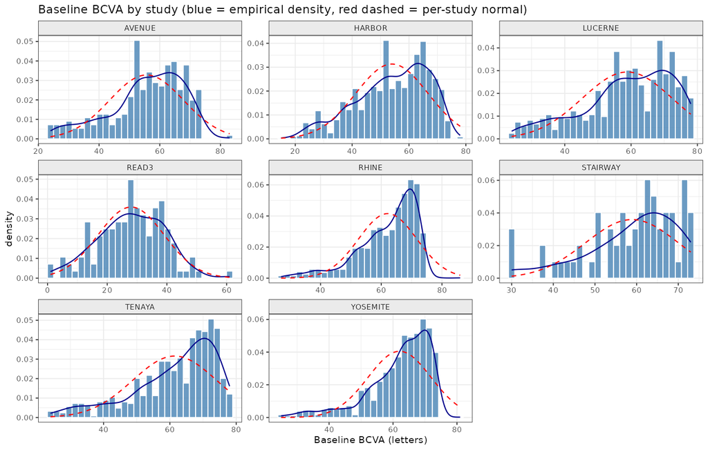

Baseline BCVA by study - histogram with normal overlay (red dashed).

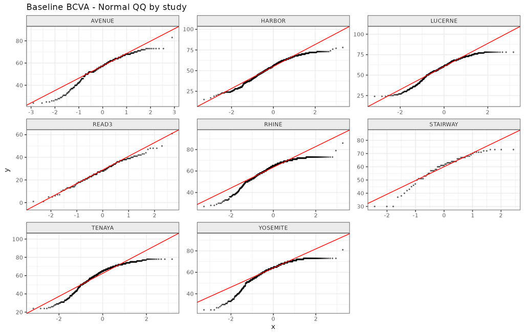

Baseline BCVA by study - Normal QQ plot.

**Finding - not normal.** Baseline BCVA is **left-skewed in every study**. The skew is strongest where mean baseline is high - YOSEMITE (skew -1.35), RHINE (-1.17) and TENAYA (-1.02), all ~62 letters - because the eligibility upper cap (~73-78 letters in the modern trials) truncates the right tail and eyes pile up near the ceiling. READ3, with a low mean baseline (~28), is the closest to symmetric (skew -0.13, Shapiro W 0.99). This left-truncated, left-skewed baseline is the structural precondition for the ceiling effect that drives the endpoint disagreement.

**Inclusion criteria (approximate - verify against protocols)**

Modern DME (YOSEMITE/RHINE) enrol roughly **25-73** letters; nAMD (TENAYA/LUCERNE) roughly **24-78**. The upper caps explain the truncation visible in the histograms. Exact protocol cut-offs are a pending item.

## 3.1 Baseline BCVA distribution

**Problem.** To simulate trials for the endpoint comparison (Steps 5-6) we need a realistic generator for **baseline BCVA**, because baseline drives the ceiling effect and therefore the relative behaviour of the two endpoints. A normal distribution is the usual default, but the EDA showed baseline BCVA is left-skewed and bounded by the eligibility window - so the default may be inadequate.

**Approach.** For each of the eight studies we fit four candidate distributions to baseline BCVA by maximum likelihood - **normal**, **truncated-normal** (bounded to the study’s eligibility window [L,U]), **skew-normal**, and **beta-rescaled** - and compared them on both a penalised-likelihood criterion (AIC/BIC) and a tail-weighted absolute-fit statistic (Anderson-Darling), with QQ/ECDF diagnostics. The single mis-recorded HARBOR eye (BL=3) was excluded first; bounds [L,U] are the per-study observed min/max. READ3 (investigator-led DME) is fit separately. Full methodology, per-study tables and QQ/ECDF plots are in Section 15.

**Key result.** The picture below - the four fitted densities over each study’s baseline histogram - is the clearest summary.

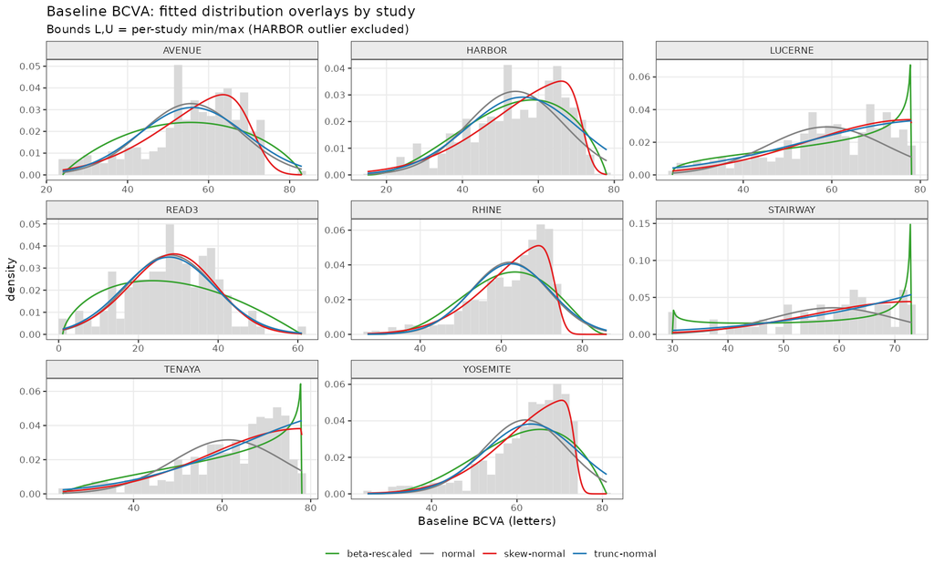

Baseline BCVA histograms with the four fitted densities overlaid, per study. Normal (grey) is symmetric and misses; beta (green) mis-shapes; the truncated-normal (blue) and skew-normal (red) track the data best, with the truncated-normal respecting the hard eligibility bound.

Reading the fits together with the formal criteria:

- **The normal distribution is rejected in every study** - worst or near-worst on AIC and very large Anderson-Darling in the high-baseline nAMD trials. Baseline BCVA is not normal.
- **The beta-rescaled fit is also poor** - it distorts the shape.
- **Two candidates fit well and are tied on AIC: the truncated-normal and the skew-normal.** They win on complementary grounds. The **truncated-normal** respects the eligibility bound - it stops exactly where the data stop, which is why it reads as the cleanest fit in the histogram. The **skew-normal** captures the left-skew, giving it the better Anderson-Darling (mean AD 3.4 vs 10.9).
- In the high-baseline nAMD studies (RHINE, YOSEMITE, LUCERNE, TENAYA) even the best fit leaves some residual misfit, because 25-32% of eyes sit in the narrow 70-to-ceiling band - a concentration no single smooth density fully reproduces. This near-ceiling build-up is itself part of the ceiling-effect story.

**Implication for the simulation.** The baseline generator must be **left-skewed and bounded**. Since the two good fits each supply one of those properties, the natural choice is a **truncated skew-normal** - skew for realistic shape, truncation to keep simulated baselines within the eligibility window - shiftable to any target mean (50…75) for the power grid. An empirical resampling generator will serve as a sensitivity check. The generator is built in the simulation step.

# 4 EDA - Endpoints (M9 / M12)

**Question:** are CFBL and absolute BCVA at M9/M12 normally distributed?

## 4.1 Change from baseline (CFBL)

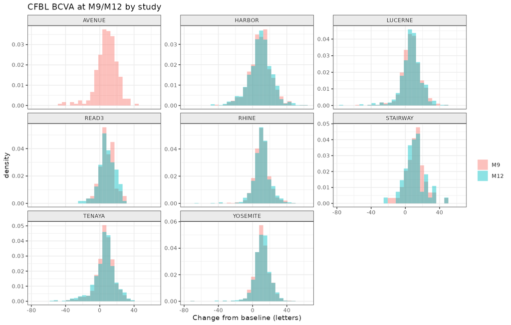

CFBL BCVA at M9/M12 by study.

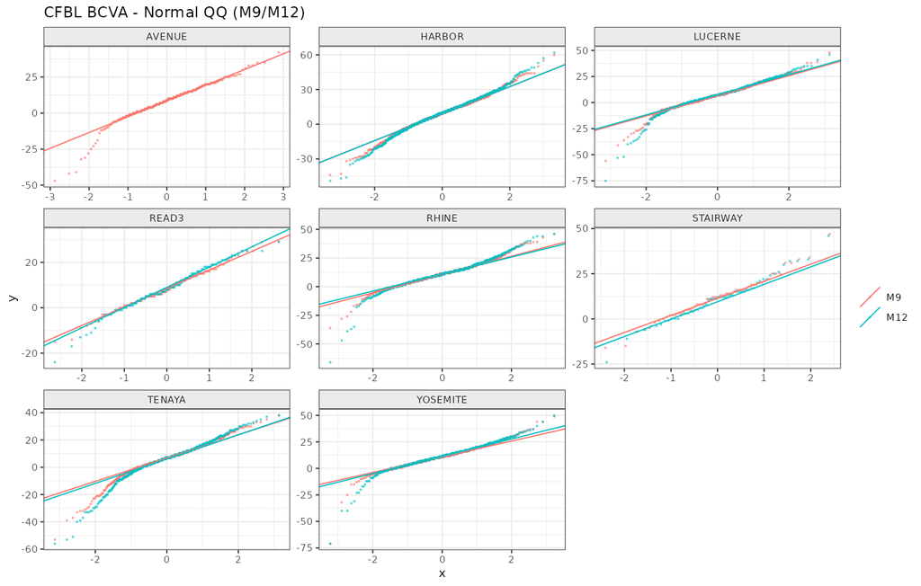

CFBL BCVA - Normal QQ by study (M9/M12).

*How the ceiling propagates into the change score.* Since `CFBL = BCVA(t) - BCVA(baseline)`, and the BCVA scale is capped at ~100 letters, the maximum *gain* an eye can achieve is bounded by its headroom (`100 - baseline`). An eye entering at 75 letters can gain at most ~25 letters, whereas an eye at 40 letters can gain up to ~60. In the high-baseline trials most eyes start near the cap, so their possible gains are squeezed toward a small positive range and pile up just above 0 - the right side of the CFBL distribution is compressed. Losses, however, are **not** bounded the same way: an eye can still drop by many letters (disease progression, adverse events), producing a longer negative tail. The result is an asymmetric CFBL: a compact, truncated upper side and an extended lower tail - i.e. the baseline ceiling re-appears as left skew in the change score. Low-baseline trials (READ3) have ample headroom, so gains are not truncated and CFBL stays closer to symmetric.

## 4.2 Absolute BCVA

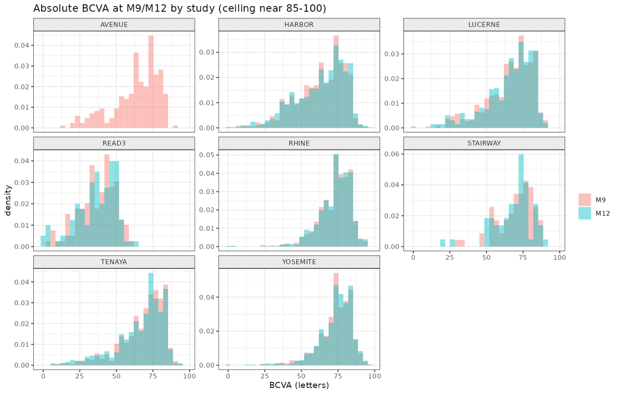

Absolute BCVA at M9/M12 by study (note ceiling near 85-100).

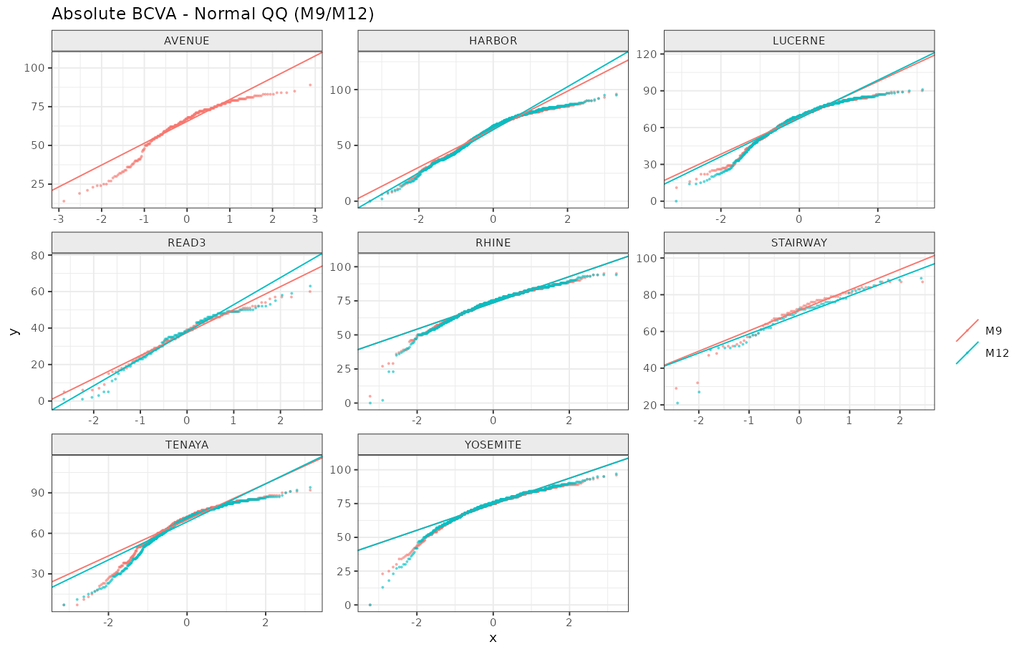

Absolute BCVA - Normal QQ by study (M9/M12).

**Finding - strongly non-normal.** Absolute BCVA is left-skewed in all studies, worst where baseline is high (YOSEMITE, RHINE, TENAYA). The histograms show a clear pile-up against the 85-100 letter ceiling. The **QQ plots reveal the distribution is non-normal at *both* ends**: the upper tail flattens against the ceiling (points fall below the reference line at high quantiles), while the lower tail is heavy - a run of points below the line at low quantiles corresponding to eyes with **large vision losses**. So the departure from normality is driven both by the ceiling and by a long left tail of poor responders, not by the ceiling alone.

## 4.3 Normality summary

Two complementary statistics are summarised, each as the **median across the per-study (baseline) or per-study/arm (M9, M12) groups** so that a single trial or arm does not dominate:

- **Skewness** measures the asymmetry of the distribution. A value of **0** is perfectly symmetric (as a normal distribution is); **negative** values indicate a long *left* tail (mass concentrated at high values with a tail of low values). All BCVA metrics here are negative, i.e. left-skewed.
- **Shapiro-Wilk W** is a formal test statistic for normality, bounded between 0 and 1. **W close to 1** means the sample closely follows a normal distribution; lower values indicate a stronger departure. (W is reported here as a descriptive index of normality, not as a hypothesis test - with these sample sizes any distribution would reject formal normality.)

Normality by metric and timepoint (median across study/arm groups). Skew close to 0 and Shapiro W close to 1 indicate closer to normal.

| metric | TP | n_groups | median_skew | median_shapiroW |
| --- | --- | --- | --- | --- |
| Baseline | BL | 8 | -0.81 | 0.930 |
| AbsBCVA | M9 | 25 | -0.93 | 0.925 |
| AbsBCVA | M12 | 20 | -1.15 | 0.915 |
| CFBL | M9 | 25 | -0.33 | 0.968 |
| CFBL | M12 | 20 | -0.51 | 0.944 |

**Interpretation.** The ordering is consistent across the cohort:

- **Absolute BCVA** - most non-normal (ceiling).
- **Baseline** - non-normal (eligibility truncation + ceiling).
- **CFBL** - nearest to normal, but worsens with higher baseline.

This is the empirical basis for the endpoint-disagreement argument: dichotomising a left-skewed, ceiling-bounded outcome at the $\ge 15$-letter threshold discards information and behaves very differently from the continuous mean-CFBL endpoint.

## 4.4 Endpoint BCVA distribution

**Why fit the endpoints too.** Section 3.1 established a realistic *generator* for baseline. This subsection is the complement: a **diagnostic** on the outcomes the simulation must reproduce - **absolute BCVA** and **CFBL** at M9/M12. In the power simulation the endpoints are not sampled from a fitted marginal; they emerge from *(baseline generator) + (treatment-effect model) + (residual error)*. So the role of these fits is to tell us **what residual/error structure the outcome model must carry**, and to give a **validation target**: the simulated endpoint marginals should look like the fitted ones below. Same machinery as Section 3.1 (ML fits, AIC/BIC + Anderson-Darling, QQ), applied per study x timepoint. Absolute BCVA gets the four bounded candidates; CFBL - marginally unbounded but skewed by the ceiling - is compared as **normal vs skew-normal**.

**Absolute BCVA is not normal - skew-normal wins almost everywhere.**

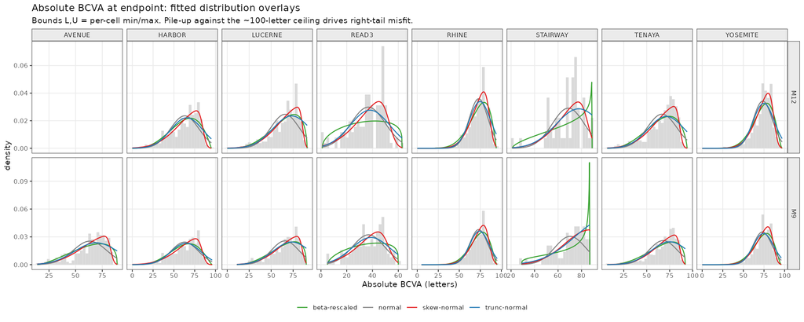

Absolute BCVA at M9/M12 with fitted density overlays, per study. The right tail is pulled toward the scale cap; the symmetric normal (grey) overshoots past the ceiling while the skew-normal (red) and truncated-normal (blue) track the bounded shape.

The skew-normal is the best AIC-ranked fit in **13 of 15** study-timepoint cells (truncated-normal in the other two); the **normal never wins**. As at baseline, the residual misfit is largest in the high-baseline nAMD trials - **TENAYA** (Anderson-Darling 6.4-7.7) and **YOSEMITE** (5.9-6.7) - where treatment pushes a sizeable fraction of eyes up against the scale ceiling.

**CFBL: normal is adequate only when baseline is low.** This is the most consequential finding for the modelling choice.

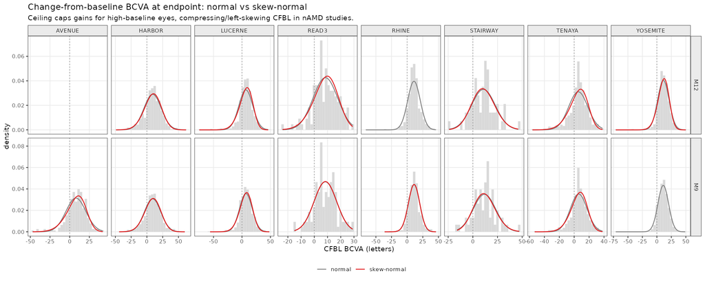

Change-from-baseline BCVA at M9/M12: normal (grey) vs skew-normal (red). In low-baseline studies (READ3, STAIRWAY) the two coincide and CFBL is near-normal; in high-baseline nAMD studies the ceiling caps gains, left-skewing CFBL so the normal fit is rejected.

The Anderson-Darling contrast is stark and baseline-dependent:

| Study (nAMD, high BL) | normal AD | skew-normal AD |
| --- | --- | --- |
| TENAYA M12 | 18.4 | 10.0 |
| RHINE M12 | 13.8 | 13.6 |
| YOSEMITE M12 | 13.1 | 10.4 |
| LUCERNE M12 | 13.5 | 9.4 |
| HARBOR M9 | 7.6 | 5.9 |

| Study (low BL, DME) | normal AD | skew-normal AD |
| --- | --- | --- |
| READ3 M9 | 0.34 | 0.34 |
| READ3 M12 | 0.49 | 0.52 |
| STAIRWAY M9 | 0.58 | 0.54 |
| STAIRWAY M12 | 0.68 | 0.59 |

Where baseline is low (READ3, STAIRWAY) normal and skew-normal are indistinguishable and both fit well - CFBL is essentially normal. Where baseline is high (all the nAMD trials) the normal is decisively rejected and even the skew-normal leaves residual misfit, because the ceiling truncates the achievable gain.

**The ceiling is created by treatment.** The mechanism is direct: treatment lifts eyes up the scale, so the fraction with no room to gain 15 more letters grows from essentially zero at baseline to double digits by M9/M12.

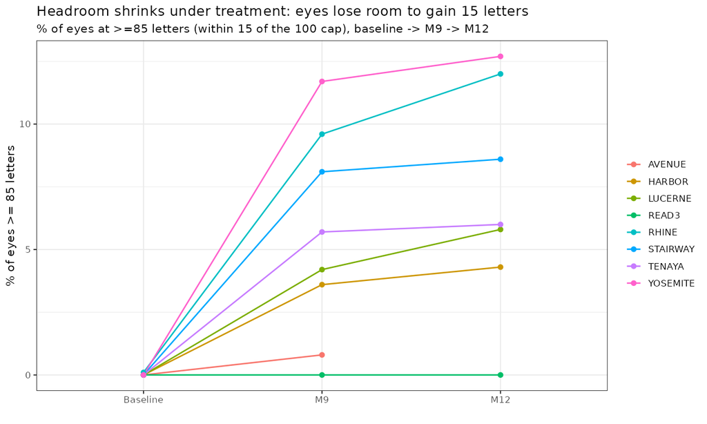

Percentage of eyes at >=85 letters (within 15 of the 100 cap, i.e. structurally unable to record a >=15-letter gain), tracked baseline -> M9 -> M12. Near zero at baseline everywhere; rises to 10-13% in the high-baseline nAMD trials (RHINE, YOSEMITE) but stays ~0% in low-baseline READ3.

**Implications for the simulation error model**

- **CFBL with a normal error is only defensible at low baseline.** For the high-baseline nAMD regime the outcome model needs a **left-skewed / bounded residual** (or must operate on absolute BCVA with a ceiling), otherwise it will mis-state variance and power for *both* endpoints.
- **Favour ANCOVA on absolute BCVA over modelling CFBL directly** (consistent with the slide-14 model): absolute BCVA with baseline as covariate is the more efficient and more honestly-bounded target, and its residual is better behaved than raw CFBL near the ceiling.
- **Validation target:** the simulated endpoint marginals should reproduce these fitted shapes and the baseline->endpoint growth in the near-ceiling fraction.

Full per-cell GoF tables and QQ diagnostics are in Section 15 (endpoint fits share the same output files).

# 5 Analysis of the ceiling effect

The normality assessment above shows *that* the distributions depart from normal; this section shows the **mechanism** - the bounded 0-100 letter scale. An eye that starts near the top of the scale has little **headroom** to improve, so both the **mean** and the **spread** of change-from-baseline shrink as baseline BCVA rises.

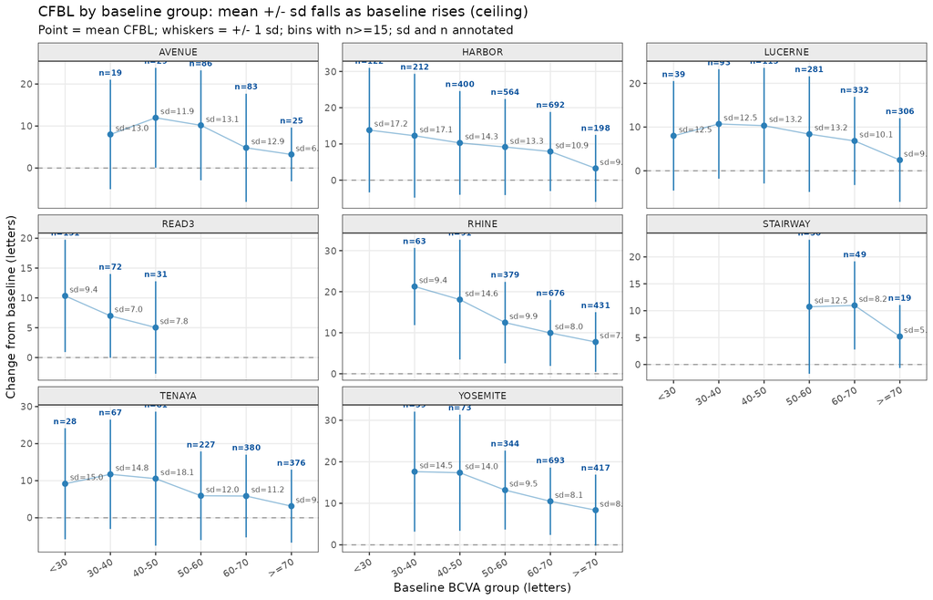

CFBL by baseline group, per study: both the mean and the +/-1 sd whiskers contract as baseline BCVA rises. sd and n annotated per bin.

Two things move together in this figure. The obvious one is the **mean** CFBL falling as baseline rises. The second — read off the **$\pm1$ SD whiskers**, which visibly contract from left to right, and off the per-bin `sd` annotations — is that **the spread of CFBL also decreases with increasing baseline**: high-baseline eyes have little headroom, so both their average gain *and* the eye-to-eye variability in that gain shrink. This baseline-dependent SD is not a nuisance to average over — it is a structural feature the generator must reproduce, and it is exactly why a model with a **variance decoupled from the mean** (Section 6.1) is needed: the SD law $g(\text{BL})$ must be free to fall with baseline independently of where the mean sits.

The same baseline groups, viewed through the **binary $\ge 15$-letter endpoint**, make the divergence explicit. Here the error bars are **Wilson 95% confidence intervals for the rate** (the binomial spread $\sqrt{p(1-p)}$ is a fixed function of the rate itself and carries no independent information, so the CI - which uses the bin’s n - is the meaningful measure of precision).

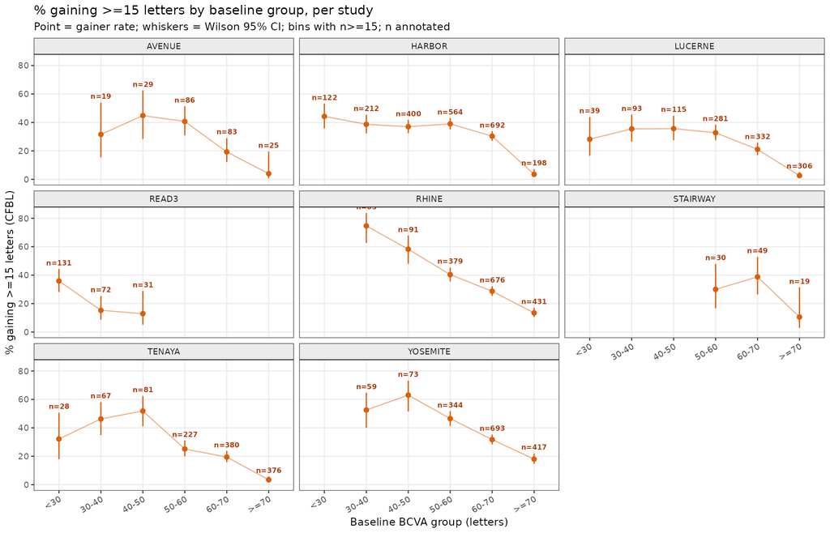

% gaining >=15 letters by baseline group, per study. Whiskers = Wilson 95% CI; n annotated per bin.

Comparing the two figures is the crux: as baseline rises the **mean CFBL declines gradually**, but the **$\ge 15$-letter rate collapses** - e.g. in RHINE from ~75% to ~15%, in LUCERNE and TENAYA to ~2-4%, in HARBOR to ~4%. Near the ceiling the continuous endpoint still records the smaller partial gains that the fixed 15-letter threshold discards entirely.

Note the asymmetry already visible in the two figures: from the lowest to the highest baseline group the mean CFBL roughly halves, but the $\ge 15$L rate falls by **5- to 15-fold**. The binary endpoint reacts far more violently to the ceiling than the continuous one.

**Link to the endpoint question.** The ceiling compresses the achievable gain, so at high baseline the between-arm treatment effect shrinks - but it does *not* hurt the two endpoints equally. Why the binary $\ge 15$L endpoint is affected so much more, and what that implies for how a trial should be designed, is a general property of dichotomising a continuous outcome; it is developed in Section 8.1 below.

# 6 A generative model for absolute BCVA

To simulate the endpoint comparison — and ultimately the power/Type-I of the four fixed analyses set out in the design objective (Section 8) — we need to *generate* absolute BCVA at the endpoint. We model **absolute BCVA directly** (not change-from-baseline), with baseline as a covariate: this keeps every family on a common likelihood scale and avoids the change-of-variables a CFBL model would need.

## 6.1 What the data demand of a generator

The endpoint’s dependence on baseline is not a nuisance — it *is* the structure the generator must reproduce. The two raw-data views in Section 5 (mean/SD contraction and the collapsing $\ge 15$L rate) already make the requirement concrete; we do not repeat them here. Three features are visible there and non-negotiable for the model:

1. **Regression to the ceiling** — mean CFBL shrinks as baseline rises (the response is bounded at 100), so the generator must be **bounded**.
2. **Baseline-dependent variance** — the $\pm1$ SD whiskers contract with baseline, and this contraction is **not** tied to the mean in the way a Normal or a Beta forces it; the generator needs a **variance decoupled from the mean**.
3. **Baseline-conditioned response** — both the mean and the $\ge 15$L rate depend on where an eye starts, so simulation must be **conditional on observed baseline**, not marginal.

These three requirements — bounded, variance-decoupled, baseline-conditioned — are exactly what select the **Logit-normal cANCOVA** engine later (Section 7.5.1). The rest of this section specifies the family grid (Section 6.2.1), the random-effect structure that delivers the baseline conditioning (Section 6.2.2), and the fitting machinery (Section 6.2.7); the model comparison is then the results section (Section 7).

## 6.2 The longitudinal generator: the model grid

The three data requirements above — bounded, variance-decoupled, baseline-conditioned — define what the generator must do. For the power simulation we also need the **within-eye correlation** between M9 and M12, and a baseline that stays anchored to each eye’s own observed value. Both are delivered by a **shared random-effect model** — a per-eye latent factor loading on baseline and endpoint phases — simulated **conditionally on the observed baseline**.

Rather than pick one model up front, we define a **grid** and let the forward-conditional score (Section 7.3) choose. The grid has three modelling axes and one implementation axis:

| Axis | Options | Defined in | What it controls |
| --- | --- | --- | --- |
| **Response family** | Normal, Beta, Logit-normal, Skew-normal, Beta-binomial, Nils | Section 6.2.1 | bound at 100? variance free of the mean? |
| **Model / RE structure** | ANCOVA, marginal, 1 random effect, 2 random effects | Section 6.2.2, Section 6.2.3 | within-eye correlation; baseline conditioning |
| **SD (variance) structure** | constant, $\sigma(\text{STUDY})$, $\sigma(\text{STUDY}+\text{ns(BL)})$ | Section 7.3 | baseline-dependent spread; ceiling mass |
| **Engine** *(implementation)* | glmmTMB (ML, cheap) → brms (full-Bayes, expensive) | Section 6.2.7 | which cells are reachable; identifiability |

The **workflow** is deliberately staged for cost: the full family × structure grid is screened cheaply in **glmmTMB**, and only the promising cells — the bounded, variance-decoupled families and the rank-2 structure that ML cannot identify — are promoted to the expensive **brms** full-Bayes fit (Section 6.2.7). The rank of the random effect (one shared factor vs a correlated 2-D effect) is compared in Section 6.2.2; the shipped model uses the parsimonious **cANCOVA** form, with the **2-RE** its equivalent when the baseline is unobserved (Section 7.4), and the conditional-simulation machinery below covers all structures.

**Fit.** Each eye contributes three rows: one baseline (BL, coded $\text{post}=0$) and two endpoint visits (M9, M12, coded $\text{post}=1$). Let $P_v=\mathbb 1[v\in\{\text{M9},\text{M12}\}]$ be the post indicator and $Q_v=\mathbb 1[v=\text{M12}]$. The linear predictor on link scale $h$ (identity for the additive families, logit for the bounded ones) is

$$h\!\big(\mathbb E[Y_{iv}]\big)=
\underbrace{\gamma_{\text{STUDY}(i)}}_{\text{study level}}
+P_v\Big[\,\underbrace{f_{\text{fam}}(\text{BL}_i)}_{\text{regression to ceiling}}
+\underbrace{\alpha_{\text{arm}(i)}}_{\text{study-arm}}
+\underbrace{\beta\,Q_v}_{\text{M12}-\text{M9 shift}}\Big]
+\lambda_{\text{phase}(v)}\,b_i,
\qquad b_i\sim\mathcal N(0,1).$$

Every endpoint term is **gated by the post indicator $P_v$**: the baseline row carries only the study intercept plus the baseline-phase random effect, and the baseline covariate $\text{BL}_i$, arm effect and visit shift act on the M9/M12 rows only. The $M12-M9$ increment $\beta Q_v$ sits *on top of* that common post shift, so the endpoint is `study + spline(BL) + arm + (M12 bump)`; there is no separate free M9 term because M9 *is* the post reference level. This mirrors the fitted formula `Y ~ STUDY + post:ns(BL,4) + post:SARM + post:M12 + (0 + phase | ID)`, where `SARM = STUDY × ARM`. The loading $\lambda_{\text{BL}}$ acts on the baseline row and $\lambda_{\text{post}}$ on **both** M9 and M12 (the shared endpoint level that induces the within-eye M9$\leftrightarrow$M12 correlation); fitted via glmmTMB’s reduced-rank term `rr(0 + phase | ID, d = 1)`.

**Why STUDY (ungated) but ARM only at post**

The split encodes **randomisation**. At baseline the arms within a study are exchangeable — there is no arm effect to estimate, only a study-level location — so $\gamma_{\text{STUDY}}$ enters **ungated** and is the only mean term on the baseline row (baseline = study intercept + baseline RE). The study-arm term $\alpha_{\text{arm}}$ (the `post:SARM` interaction, arm nested in study) switches on **only at the endpoint** $P_v=1$, which is where a treatment difference can exist. Estimating an arm effect at baseline would fit noise against randomisation and could bias the CFBL contrast by absorbing baseline imbalance; gating it to post encodes “arms equal at BL, free to differ at endpoint.” The ceiling covariate `post:ns(BL)` and the `post:M12` visit bump are post-gated for the same reason — none act at baseline.

The per-eye effect can enter with **zero, one, or two** random effects — or be replaced by conditioning on the observed baseline directly (ANCOVA, Section 6.2.3). These structures are specified and compared later (Section 6.2.2). Two axes remain to fix: **which likelihood family** carries the response (next), and **which random-effect structure** delivers the baseline conditioning (Section 6.2.2).

### 6.2.1 Response families

The first axis is the **response family** — the per-visit likelihood. It fixes the two properties the data demanded in Section 6.1: whether the support is **bounded** at the 100-letter cap, and whether the **variance is free of the mean** or locked to it. Six families span the corners of that (bounded × variance-flexible) space; each is fitted as **marginal** and **rank-1 RE**, with the leading candidates additionally at **rank-2**.

| Family | Link / scale | Variance vs mean (flexibility) | Skew? | Bounded at 100? | Role |
| --- | --- | --- | --- | --- | --- |
| **Normal** | identity (letters) | spline $g(\text{BL})$, **decoupled** | no | no (leaks past cap) | additive workhorse |
| **Skew-normal** | identity (letters) | scale **decoupled** + skew $\alpha$ | **yes** | no (clamp in sim) | adds asymmetry to the Normal |
| **Beta** | logit on $Y/100$ | **locked** $\mu(1-\mu)/(1{+}\phi)$ | via bound | yes (intrinsic) | bounded reference |
| **Logit-normal** | Normal on $\text{logit}(Y/100)$ | free (logit-scale $\sigma$), **decoupled** | via bound | yes (transform) | bounded **and** variance-free |
| **Beta-binomial** | logit on letter *count* | overdispersion $\phi$ | via bound | yes | count model; collapses to binomial-logit-RE |
| **Nils** | identity, **quadratic** mean | single $\sigma$ | no | no | slide benchmark |

**Variance flexibility** is the axis that separates the field. The **Normal**, **Skew-normal** and **Logit-normal** let the spread vary freely (a spline SD law, Section 6.2.4); the **Beta** *locks* the variance to $\mu(1-\mu)$, so it cannot widen the spread independently of the mean (the SD gap of Section 7.3); the **Beta-binomial** adds a single overdispersion knob. **Boundedness** is the second axis: only the logit-scale families (Beta, Logit-normal) and Beta-binomial respect the 100-letter cap natively, while the identity-scale families (Normal, Skew-normal, Nils) leak past it and must clamp in simulation (Section 6.1).

Reading the table against the two axes: only the **Logit-normal** corner is **both** bounded (like Beta) **and** variance-decoupled (like Normal) — the Beta shares the bound but locks the variance, the Normal frees the variance but leaks past the cap, and the **Skew-normal** frees the variance *and* adds asymmetry but still leaks. This is why the comparison later selects the Logit-normal (Section 7.4). The skew-normal shapes from Section 4.4 are a **validation target, not a parameter**: a good family must reproduce them without being told, which is exactly what makes the explicit Skew-normal a useful control — it *is* told, so it bounds how much asymmetry alone can buy.

**Why not just clamp the Normal?** The obvious shortcut — keep the familiar Normal and truncate simulated draws to `[0,100]` — is the one family variant we reject outright. It is internally inconsistent (the likelihood is fit *unbounded* but the generator is *truncated*, so the fitted parameters describe a different distribution from the one simulated) and it manufactures an artificial **point-mass at exactly 100** the data do not show — real eyes pile up *near* but below the cap, not on it. The Normal is therefore carried forward **only** as a transparent sensitivity model (its cap leakage is exactly what the $\%\ge 85$L functional and the VPC exist to expose), never as the production generator. The principled way to honour the bound is a family that respects it natively — the Beta or, keeping the variance free, the **Logit-normal**. A truncated-Normal fit by its *own* truncated likelihood (bound inside the fit, not bolted on after) would also be legitimate, but it buys nothing the Logit-normal does not already give on a smoother scale.

**The Normal appears under two names later — same model, different bound handling**

There is **one** Normal family (identity scale, variance-decoupled, leaks the cap). It is fitted identically in glmmTMB and in `brms` — the engine is irrelevant to the model. Two labels appear downstream only to mark **what is done with the cap at simulation time**:

- **plain-Normal reference** — draws left **unbounded**, so the cap leakage is visible and the family is decisively rejected (elpd $\approx-26{,}000$, Section 11). This is the “does the logit transform even help?” baseline.
- **Gaussian-clamp** — the same fit with draws **truncated to $[0,100]$** at simulation time (the “just clamp it” shortcut rejected above), used as the honest losing competitor in Section 7.3.

So *brms-Normal* and *glmmTMB-Normal* are **not** different models — they are the same Normal; only *unbounded vs clamped* distinguishes the two labels. Neither is the shipped model, which is the bounded **Logit-normal**.

### 6.2.2 The three random-effect structures

The eye-level structure is a ladder of four candidates, each answering one question:

| Rung | Structure | Question |
| --- | --- | --- |
| **0 RE** | marginal (no per-eye term) | is a per-eye factor real at all? |
| **1 RE** | one shared per-eye factor | is a *single* factor enough? |
| **2 RE** | baseline + endpoint factors, free $\rho$ | does a *second*, free-$\rho$ factor help? |
| **cANCOVA** | **one** random intercept, baseline *observed* as a covariate | with baseline observed, is the 2-RE still needed? |

The first three (0/1/2-RE) model baseline as a **response row** and differ only in the $2\times2$ covariance $\Sigma$ of the eye-level effects; **cANCOVA** takes baseline out of the response and enters it as an observed covariate, so it needs just **one** random intercept (Section 6.2.3). The three response-row structures are developed first.

Every 0/1/2-RE model is one of **three** structures for the per-eye effect. They differ only in the $2\times2$ covariance $\Sigma$ of the eye-level effects on the baseline and post-baseline phases, $(u_{\text{BL}},u_{\text{post}})$. The mean structure is **identical** across all three; only $\Sigma$ changes. With the post indicator $P_v=\mathbb 1[v\in\{\text{M9},\text{M12}\}]$ and $Q_v=\mathbb 1[v=\text{M12}]$, the linear predictor for eye $i$, visit $v$ on link scale $h$ is

$$h\!\big(\mathbb E[Y_{iv}]\big)=
\underbrace{\gamma_{\text{STUDY}(i)}+P_v\big[f_{\text{fam}}(\text{BL}_i)+\alpha_{\text{arm}(i)}+\beta\,Q_v\big]}_{\text{shared mean structure (all endpoint terms gated by }P_v)}+u_{\text{phase}(v),\,i}.$$

**1. Marginal (no random effect): $\;\Sigma=\mathbf 0$.**
$$u_{\text{BL},i}=u_{\text{post},i}=0.$$
Every eye shares the population mean; the only variation is the residual/dispersion term. **There is no cross-visit variance–covariance:** given baseline, the two endpoint rows (M9, M12) are conditionally independent, so the model carries **no within-eye correlation** beyond what the shared fixed effects and the $\text{BL}_i$ covariate induce. *Intuition:* eyes are exchangeable draws from the population curve — there is no “this eye runs high/low” memory. This is the control arm: it isolates what the random effect buys, and its inability to reproduce the observed within-eye M9$\leftrightarrow$M12 change is exactly the gap the RE closes.

**2. Rank-1 (single shared factor): $\;\Sigma=\lambda\lambda^{\!\top}$, $\operatorname{rank}=1$.**
$$\begin{pmatrix}u_{\text{BL},i}\\u_{\text{post},i}\end{pmatrix}
=\begin{pmatrix}\lambda_{\text{BL}}\\\lambda_{\text{post}}\end{pmatrix}b_i,
\qquad b_i\sim\mathcal N(0,1),
\qquad
\Sigma=\begin{pmatrix}\lambda_{\text{BL}}^2 & \lambda_{\text{BL}}\lambda_{\text{post}}\\[2pt]\lambda_{\text{BL}}\lambda_{\text{post}} & \lambda_{\text{post}}^2\end{pmatrix}.$$
One latent “how good is this eye” score $b_i$ scales onto both phases. Because a **single** factor drives both, the baseline↔︎post correlation is $\rho=\operatorname{sign}(\lambda_{\text{BL}}\lambda_{\text{post}})=\pm1$ **by construction** (with $\tau_{\text{BL}}=|\lambda_{\text{BL}}|$, $\tau_{\text{post}}=|\lambda_{\text{post}}|$). *Intuition:* a good baseline eye is, deterministically, a good endpoint eye — they share one axis. Fitted via `rr(0 + phase | ID, d = 1)`; the shared $b_i$ is what induces the within-eye M9$\leftrightarrow$M12 correlation, and it makes the conditional baseline draw (Section 6.2.5) one-dimensional.

**3. Rank-2 (full covariance): $\;\Sigma$ unstructured, $\operatorname{rank}=2$.**
$$\begin{pmatrix}u_{\text{BL},i}\\u_{\text{post},i}\end{pmatrix}\sim\mathcal N\!\left(\mathbf 0,\;\Sigma\right),
\qquad
\Sigma=\begin{pmatrix}\tau_{\text{BL}}^2 & \rho\,\tau_{\text{BL}}\tau_{\text{post}}\\[2pt]\rho\,\tau_{\text{BL}}\tau_{\text{post}} & \tau_{\text{post}}^2\end{pmatrix},\quad \rho\in(-1,1)\text{ free}.$$
Two correlated eye effects with **separately estimated** SDs *and* a **free** correlation $\hat\rho$. *Intuition:* it relaxes the rank-1 assumption that baseline and endpoint are the same axis — an eye could start high yet respond atypically, so $\rho$ need not be $\pm1$. Strictly more flexible (one extra parameter), always $\ge$ rank-1 in likelihood; fitted via `(0 + phase | ID)`.

| Structure | $\Sigma$ | Free params in $\Sigma$ | $\rho$ | One-line intuition |
| --- | --- | --- | --- | --- |
| **Marginal** | $\mathbf 0$ | 0 | — | eyes exchangeable; baseline uninformative for endpoint |
| **Rank-1** | $\lambda\lambda^{\!\top}$ | 2 ($\lambda_{\text{BL}},\lambda_{\text{post}}$) | $\pm1$ (structural) | one “eye quality” axis drives both phases |
| **Rank-2** | unstructured | 3 ($\tau_{\text{BL}},\tau_{\text{post}},\rho$) | free | baseline and endpoint may decouple |

**Why compare all three the same way.** Each structure defines a *generator*; the only question that matters downstream is whether draws reproduce the four simulation-critical functionals per study-arm. The metric that makes every structure **and** every family directly comparable is defined once in Section 6.2.8 below and used for the whole Results section.

### 6.2.3 Two parametrizations of the same question: joint (cLDA) vs conditional (cANCOVA)

The three structures above all treat **baseline as a response row** — an outcome the model must generate, with a phase-indexed random effect $(u_{\text{BL}},u_{\text{post}})$. This is the **joint** parametrization, the mixed-model analogue of a **constrained longitudinal data analysis (cLDA)**: baseline and endpoint are modelled jointly, the arms are constrained equal at baseline by randomisation, and the treatment contrast is read off the post rows. It produces a baseline for each simulated eye from within the single model — one of two equally valid ways to generate the trial.

But there is a second, more standard analysis parametrization for the **same** estimand: **constrained ANCOVA (cANCOVA)**. Here baseline is not an outcome but a **covariate**. Only the post rows enter the likelihood; each eye’s own baseline is conditioned on as a fixed regressor, and a single scalar random intercept absorbs the residual between-eye correlation:

$$\underbrace{h(\mathbb E[Y_{iv}]) = \gamma_{\text{STUDY}(i)} + f_{\text{fam}}(\text{BL}_i) + \alpha_{\text{arm}(i)} + \beta Q_v + u_i}_{\text{cANCOVA: post rows only, }u_i\sim\mathcal N(0,\tau^2)},
\qquad v\in\{\text{M9},\text{M12}\}.$$

fitted as `Y ~ STUDY + ns(BL,4) + SARM + M12 + (1 | ID)` on the **post-only** data — one random effect, no baseline row, no phase covariance.

**How the two relate.** They are not rival models but two valid ways to characterize the same baseline difference, and **cANCOVA is the well-posed limit of the joint model** as the baseline random effect vanishes: as $\tau_{\text{BL}}\to 0$ the baseline row carries no eye-specific latent information, the $2\times2$ covariance $\Sigma$ degenerates to its post block, and the joint model collapses exactly onto the cANCOVA with $\tau=\tau_{\text{post}}$ — conditioning on the observed baseline as a covariate is the same operation as conditioning the joint model on the observed baseline row (Section 6.2.5). Both therefore **generate** a trial; they differ only in *how the baseline is produced*. The joint (cLDA) form produces it **within the same model** (baseline is a response row). The cANCOVA form produces it **separately**, drawing baseline from its own generator (the truncated skew-normal of Section 3.1) and then the endpoint conditional on it — a two-stage $p(\text{BL})\times p(\text{endpoint}\mid\text{BL})$ factorization of the same estimand. Neither is inherently the “estimator” or the “generator”; we **fit both** and let the scorecard (Section 7.4) decide which characterization is better-conditioned and better-calibrated.

### 6.2.4 The variance-law (SD) models

The families above fix *whether* the variance can move independently of the mean; the third axis fixes **how** it moves — the **SD law**, the model for the residual scale $\sigma$ (on the family’s own scale: letters for Normal/Skew-normal, logit for Logit-normal). This axis exists because the data show a spread that **shrinks with baseline** (Section 5) and **differs by study**, so a single constant $\sigma$ cannot fit both. The scale is modelled on the **log link** ($\log\sigma$, the brms `sigma` distributional parameter), and STUDY enters through **treatment contrasts against an intercept** — so the intercept $\kappa$ is the log-scale of the **reference study** and each additional study contributes a **deviation** $\delta_s$ ($s\ge 2$), K parameters for K studies, exactly identified (no separate global mean is estimated, so no sum-to-zero constraint is needed). Three nested laws are fitted:

| SD law | Form ($\log\sigma$) | Captures | Cost |
| --- | --- | --- | --- |
| **Constant** | $\kappa$ | one scale for all eyes | baseline; misses the shrink |
| **Study** | $\kappa+\sum_{s\ge2}\delta_s\,\mathbb 1\{\text{STUDY}=s\}$ | between-study scale differences (study deviations, no smoother) | +K−1 params |
| **Study + baseline** | $\kappa+\sum_{s\ge2}\delta_s\,\mathbb 1\{\text{STUDY}=s\}+g(\text{BL})$ | between-study **and** baseline-dependent shrink | + spline df |

Here $\kappa$ is the reference-study log-$\sigma$ (**not** a global mean), the $\delta_s$ are study contrasts, and $g(\text{BL})=\texttt{ns(BL,3)}$ is a natural spline. The joint cells encode the same law in **cell-means** form (`sigma ~ 0 + phase + phase:STUDY`, no global intercept), which is numerically identical — it only relabels the intercept — but keeps the baseline-phase rows on their own separate scale (the decontamination of Section 7.3).

The richest law lets the spread fall smoothly with baseline within each study — the pattern the ±1 SD whiskers trace in Section 5. Whether that flexibility actually *helps* the simulation targets is not obvious: a variance-decoupled family with a constant $\sigma$ might already suffice, and a wrong-scale $\sigma$ law can even hurt the per-arm SD by over-fitting the baseline rows. That question — does a richer $\sigma$ law close the SD gap? — is answered on the scorecard (Section 7.3), not assumed here. This axis is applied to **both** the RE structures and the cANCOVA form, crossing with family and structure to define the full grid; the leading $\{$structure × family$\}$ cells are fitted at all three SD laws, giving the cells scored overnight (cANCOVA and joint, each with $\log\sigma\in\{\kappa,\ \kappa+\delta_{\text{STUDY}},\ \kappa+\delta_{\text{STUDY}}+g(\text{BL})\}$, plus a plain-Normal letter-scale reference).

### 6.2.5 Conditional (BLUP) simulation algorithm

Whatever the structure, the generator must be simulated **conditionally on each eye’s observed baseline** — otherwise, as an earlier VPC showed, drawing $u_{\text{BL},i}$ from its **marginal** $\mathcal N(0,\tau_{\text{BL}}^2)$ spreads simulated baselines over the whole study range and faceting by *observed* baseline compares eyes at (say) 45 letters against simulated eyes centred near 60 — a large, spurious bias. Fit and simulation are the *same* model; we simply evaluate the correct margin. Only **step 2** — how each eye’s baseline is fixed — differs across the three structures (rank-1, rank-2, cANCOVA); the rest of the algorithm is shared, so it is stated once here and specialised in the three cases below. For each of $B=500$ replicates, at the observed design (each eye’s baseline row, study-arm, M9/M12 rows):

1. *Population mean.* Evaluate the linear predictor $\eta_{iv}$ at the MLE with no random effect (`predict(re.form = NA, type = "link")`) — contains $f_{\text{fam}}(\text{BL}_i)$, $\text{arm}_j$, visit — and the per-row dispersion $g(\text{BL}_i)$ / $\phi(\text{BL}_i)$.
2. *Condition the eye effect on the observed baseline.* Restrict the eye-effect posterior to reproduce $\text{BL}_i^{\text{obs}}$ on the baseline row. **This is the one step that depends on the RE rank** (see the two variants below).
3. *Endpoint effect.* Propagate the conditioned eye effect onto the M9/M12 rows — deterministic in rank-1, a residual draw in rank-2 (again, below). This is what carries the within-eye M9$\leftrightarrow$M12 correlation.
4. *Outcomes.* Draw each row from its family at $\mu_{iv}=h^{-1}(\eta_{iv}+u_{\text{phase}(v),i})$: Normal/Nils add $\mathcal N(0,g(\text{BL})^2)$; Beta draws $100\cdot\text{Beta}(\mu\phi,(1-\mu)\phi)$; Beta-binomial draws the letter count (binomial in the collapsed limit). **No clamp is applied** in the frequentist grid — bounded families are in-range by construction; Normal/Nils are left free to leak past the 100 cap on purpose, so the by-arm VPC shows the ceiling violation transparently. (The brms Gaussian/skew cells in Section 6.2.7 clamp their predictive.)

#### 6.2.5.1 One random effect (rank-1): a 1-D conditional

With **one** latent factor $b_i\sim\mathcal N(0,1)$ per eye, the posterior given the observed baseline is **one-dimensional in every family** — so a single simulator serves all four. Step 2 conditions $b_i$ via the family density on the baseline row,

$$p\!\left(b_i\mid\text{BL}_i^{\text{obs}}\right)\;\propto\;
\phi(b_i)\;\cdot\;
f_{\text{fam}}\!\Big(\text{BL}_i^{\text{obs}}\,\big|\,
h^{-1}(\eta^{\text{BL}}_i+\lambda_{\text{BL}}b_i),\ \text{disp}_i\Big),$$

Gaussian in $b_i$ for the additive families (closed form) and a fixed 241-point grid ($b\in[-6,6]$) for the bounded ones. The posterior **mean** re-centres each eye onto its own observed baseline; its **SD** is the residual test-retest band — $\approx3.5$–$3.9$ letters via the response-scale Jacobian ($1$ for identity, $100\,\mu(1-\mu)$ for logit), the ETDRS reliability scale, *not* the between-eye spread. Step 3 is then **deterministic**: the *same* $b_i$ loads on M9 and M12 through $\lambda_{\text{post}}$ (no separate endpoint draw), because rank-1 makes the endpoint level a fixed multiple of the baseline factor. Steps 2–3 are exact for the additive families (the joint is Gaussian); for the bounded families the only approximation is the 241-point grid, negligible at this resolution.

#### 6.2.5.2 Two random effects (rank-2): a 2-D conditional

With the unstructured $\Sigma$ the eye effect is the **pair** $(u_{\text{BL},i},u_{\text{post},i})\sim\mathcal N(\mathbf 0,\Sigma)$, so step 2 conditions on the baseline and step 3 draws the endpoint from the **Gaussian conditional** of $u_{\text{post}}$ given the conditioned $u_{\text{BL}}$:

$$u_{\text{post},i}\mid u_{\text{BL},i}\;\sim\;
\mathcal N\!\Big(\underbrace{\rho\,\tfrac{\tau_{\text{post}}}{\tau_{\text{BL}}}\,u_{\text{BL},i}}_{\text{conditional mean}},\;
\underbrace{(1-\rho^{2})\,\tau_{\text{post}}^{2}}_{\text{residual variance}}\Big).$$

**Why draw $u_{\text{post}}$ from this Normal rather than plug in its mean.** The conditional mean $\rho(\tau_{\text{post}}/\tau_{\text{BL}})u_{\text{BL},i}$ is only the *expected* endpoint effect given the eye’s baseline; the term $(1-\rho^{2})\tau_{\text{post}}^{2}$ is the **genuine between-eye response heterogeneity that is not explained by baseline** — two eyes with the same baseline still respond differently, and that spread is exactly what a generator must inject to reproduce the per-arm SD. Plugging in only the mean ($\rho<1$ but treated as if the residual were zero) would make every eye’s endpoint a **deterministic** function of its baseline, erasing that heterogeneity and shrinking the simulated SD — the very failure the 2-RE structure exists to avoid. So the residual draw is not optional noise: it *is* the endpoint variance component. Rank-1 is the $\rho=\pm1$ limit, where $(1-\rho^{2})\tau_{\text{post}}^{2}=0$ and the endpoint genuinely collapses to a deterministic multiple of the baseline factor — which is why rank-1 under-disperses the threshold functionals (Section 7.3). On the logit-scale families the *glmmTMB point estimate* drives $\hat\rho\to1$ (the identifiability collapse quantified in Section 7.3.2), so **for the glmmTMB grid** the two simulators coincide numerically. The **full-Bayes brms fit does not collapse** — it keeps $\rho=0.63$ interior — so its rank-2 conditional is a genuine 2-D draw, which is exactly why the recommended engine is the brms 2-RE (Section 7.3). The glmmTMB rank-2 simulator implements this 2-D conditional at the plug-in MLE; the brms cells draw the same conditional from the posterior.

#### 6.2.5.3 No random effect on baseline (cANCOVA): draw the baseline, then condition

The cANCOVA form (Section 6.2.3) has **no baseline random effect** to condition — the baseline enters as a fixed covariate, not a response row. Its simulation is therefore the **two-stage** factorization $p(\text{BL})\times p(\text{endpoint}\mid\text{BL})$: step 2 is replaced by **drawing** each new eye’s baseline from the dedicated baseline generator (the truncated skew-normal of Section 3.1) rather than conditioning a latent factor onto an observed one. Given that drawn baseline, step 3 draws the endpoint from the cANCOVA’s single post-level random effect plus residual — the same step-4 family draw as above, now conditioned on the simulated `ns(BL)` covariate. So all three structures are covered by one algorithm with step 2 specialised: rank-1 conditions a 1-D factor, rank-2 conditions a 2-D pair, and cANCOVA draws the baseline outright. The endpoint machinery (steps 3–4) is identical across all three.

Both variants hold the fixed effects at $\hat\theta$ in the **frequentist** grid (**plug-in predictive**; parameter uncertainty is a coded toggle left off for now). Note the deciding lever between engines is **not** predictive width but the response scale and baseline conditioning, established by the forward-conditional score (Section 7.3).

### 6.2.6 Fitting the grid: the two-stage engine plan

Before the expensive brms cells, the whole family × structure grid is screened cheaply in `glmmTMB` (seconds per cell), and only the cells ML cannot identify are promoted to `brms` (minutes–hours). The screen also settles a prerequisite question — **is the shared per-eye random effect real, or overfit?** — which it answers by $\Delta$AIC against each family’s marginal control. That fitting evidence is a *result*, so the screen fit tables and their loadings live in Section 14; here we only note that every family prefers the RE decisively, so all downstream cells carry at least one. Generator selection itself is never made on AIC but on the forward-conditional four-functional score (Section 6.2.8, Section 7.3).

### 6.2.7 Fitting engines: what glmmTMB and brms can each fit

The grid defined above (family × RE structure × SD law) is fitted by **two engines**. This is an **implementation** axis, not a modelling one — the same cell can in principle be fit either way; what differs is *which* cells each engine can actually reach. The staged workflow (Section 6.2) exploits that: screen the whole grid cheaply in **glmmTMB**, then promote only the cells ML cannot identify to the expensive **brms** fit. The two engines’ capabilities:

[output not shown]

†**How Logit-normal is fit — same transform in both engines.** Neither `glmmTMB` nor `brms` has a native logit-normal family. In **both** it is fit as an ordinary **`gaussian()` model on the transformed response** $\text{logit}(Y/100)$ (in code, `ylogit <- qlogis(pmin(pmax(DV/100, 1e-3), 1-1e-3))`): the mean, the dispersion formula and the random effects all act on the logit scale, and predictions are mapped back through `plogis()`$\times 100$ at draw time. This is exact (the logit-normal is *defined* as a normal on the logit scale), so the fit is as well-behaved as any Gaussian fit — the earlier “awkward” label was about ergonomics, not identifiability. Because the response and link are identical, the two engines differ only in *estimation* (ML vs HMC), not in the likelihood — which is what makes the frequentist-vs-Bayes agreement in Section 7.4 a clean check rather than a confound. The one genuine limitation is the same as for the other identity-scale families: at the **2-RE** structure with the baseline-varying $\sigma$ law, the logit-scale baseline variance and the $\sigma$-spline compete and the $2\times2$ covariance stops being identified (Section 7.2) — which is the cell that goes to `brms`.

The pattern that decides the workflow: `glmmTMB` fits the fast bulk (all families at marginal/rank-1, both non-constant SD laws) but **cannot** identify the rank-2 covariance under the production $\sigma$ law or fit the skew/truncated likelihoods — exactly the cells the family analysis (Section 6.2.1) flagged as most promising. Those go to `brms`. The full brms **priors and likelihood specification** are in Section 11.

**Clamp vs truncation (a bound-handling detail brms enables).** The identity-scale families (Normal, Skew-normal) do not respect $[0,100]$ intrinsically, so the bound is handled one of two ways. *Clamping* truncates predictive draws at scoring time (a **censored** predictive — the fit is untruncated, so $\theta$ is unchanged); *truncation* (`brms`’ `trunc()`) puts the bound **inside the likelihood**, so the $\theta$-dependent log-CDF normalizer shifts $\theta$. `glmmTMB` can only clamp; only `brms` can fit the truncated model. The two differ solely by the probability mass the fit places outside $[0,100]$ — under the marginal skew-normal fits this is **~0.07% (median), ~1.2% (READ3, the low-BCVA study)** — so Gaussian-clamp and SkewN-trunc are expected to give near-identical coverage; the scorecard (Section 7.4) tests that directly.

### 6.2.8 Scoring: one metric for every fitted cell

With every cell now **fitted** (glmmTMB screen + brms promotions), they are compared on a single yardstick. Each cell — every {structure × family × engine} combination — is a **generator**, and the only thing that matters is whether its draws reproduce the trial. So every cell is scored on four **simulation-critical functionals**, computed per study-arm $a$ from that arm’s change-from-baseline values $\text{CFBL}_{ia}=\text{ABS}_{i,\text{post}}-\text{BL}_i$ over its $n_a$ eyes,

$$\begin{aligned}
\text{mean CFBL}_a &= \tfrac1{n_a}\textstyle\sum_i \text{CFBL}_{ia}, &
\text{SD CFBL}_a &= \sqrt{\tfrac1{n_a-1}\textstyle\sum_i(\text{CFBL}_{ia}-\overline{\text{CFBL}}_a)^2},\\[4pt]
\%\!\ge\!15\text{L}_a &= \tfrac{100}{n_a}\textstyle\sum_i \mathbb 1\{\text{CFBL}_{ia}\ge 15\}, &
\%\!\ge\!85\text{L}_a &= \tfrac{100}{n_a}\textstyle\sum_i \mathbb 1\{\text{ABS}_{i,\text{post},a}\ge 85\}.
\end{aligned}$$

They map one-to-one onto the design analyses: **mean CFBL** and **SD CFBL** drive the continuous `t.test`/`lm` power, **$\ge 15$L** is the binary responder endpoint, and **$\ge 85$L** is the ceiling mass that stresses the boundary. For each functional we form it **within every replicate** exactly as on the observed data, and compare the observed value against the generator’s predictive interval over the 25 study-arms.

**Scoring metrics (per functional, across the 25 study-arms).** For observed value $y_a$ in arm $a$, the generator’s predictive median $\hat y_a$, and its predictive interval $[L_a,U_a]$ at nominal $1-\alpha=90\%$:

- **Coverage** $=\frac1A\sum_a \mathbb 1\{L_a\le y_a\le U_a\}$ — % of arms inside the 90% interval (target 90%; the primary calibration number, higher = better).
- **Bias** $=\frac1A\sum_a(\hat y_a - y_a)$ — systematic over/under-prediction (signed).
- **RMSE** $=\sqrt{\frac1A\sum_a(\hat y_a-y_a)^2}$ — typical miss size.
- **Width** — mean interval width (sharpness; smaller is better *if* calibrated).
- **Interval Score** (Gneiting & Raftery 2007), $\alpha=0.10$:
  $$\text{IS}_a=(U_a-L_a)+\tfrac{2}{\alpha}(L_a-y_a)\mathbb 1\{y_a<L_a\}
  +\tfrac{2}{\alpha}(y_a-U_a)\mathbb 1\{y_a>U_a\},$$
  reported as the arm-mean; **lower is better**. IS is the single proper score that combines **sharpness and calibration** — the “bias vs coverage” trade-off in one number: it rewards narrow intervals but penalises misses in proportion to how far outside the interval the observation falls.

Coverage makes marginal vs rank-1 vs rank-2, glmmTMB vs brms, and Normal vs Beta vs Logit-normal directly comparable on the one job the model has to do; the Interval Score breaks ties between cells that cover equally. Conditional (BLUP) simulation anchors each eye to its observed baseline (algorithm in Section 6.2.5), and each eye’s endpoint effect is drawn from its baseline rather than reused from the fit — the **forward-conditional** score that matches how the generator is used in production. The engine is selected on this score (Section 7.3). The patterns behind the verdict — the RE degeneracy (Section 7.3.2), the variance law (Section 7.3), and the final-model diagnostics (Section 7.6) — follow in the Results.

# 7 Results — selecting the best model

The objective is a single question: **which model best reproduces the four endpoint functionals — mean CFBL, SD CFBL, %≥15L gainers, %≥85L ceiling — at M9/M12, scored by forward simulation on unseen eyes?** All four are quantities *at the endpoint*; forward-conditional scoring is only the honest way to measure them. This chapter answers it in stages, each on the same forward-conditional yardstick. First **how** every candidate is scored (Section 7.1). Then the **glmmTMB scan** (Section 7.2) — the full family × structure × $\sigma$-law grid — which maps *what converges before what wins*: only admissible cells can be compared. On that converged grid the family and structure are chosen together — **model selection on the full grid** (Section 7.3) — reading coverage, bias and Interval Score across the four functionals. Finally, the reasons the scan already exposes — the baseline-varying variance law the endpoint needs, and the 2-RE convergence failure it causes — force the production choice into full-Bayes: the **final comparison in `brms`**, where family, structure, and $\sigma$ law are settled together on the engine as it ships (Section 7.4), the engine pick and the selected model in full (Section 7.5.1), and the random-effect-tail refinement (Section 7.7) close the chapter. A model’s later *use as a simulation generator* — where either the 2-RE or the cANCOVA form can serve — belongs to the trial-simulation chapter (§8), not to this selection.

## 7.1 How every model is scored

A model is judged on one question: *when it simulates a fresh trial, does it reproduce the four endpoint functionals the downstream power / Type-I study depends on?* The metric itself — the four functionals (mean CFBL, SD CFBL, %≥15L gainers, %≥85L ceiling), their formulas, and their one-to-one map onto the design analyses — is defined once in Section 6.2.8. Scoring is **coverage**: the % of the 25 study-arms whose observed value falls inside the model’s 90% predictive interval (nominal 90%; higher is better), with Interval Score breaking ties (Section 7.3). What this section fixes is *how* that metric is applied to every cell of the grid (Section 6.2) — two choices that decide the selection.

**Forward-conditional, on unseen eyes.** A model can look excellent by *reusing* each eye’s fitted random effect (its BLUP) — but a real prospective trial has **new** eyes. So the production score draws each eye’s endpoint effect from its **conditional law given only the observed baseline**,
$$u_{\text{post}}\mid u_{\text{BL}}\sim\mathcal N\!\Big(\rho\,\tfrac{\tau_{\text{post}}}{\tau_{\text{BL}}}\,u_{\text{BL}},\;(1-\rho^2)\,\tau_{\text{post}}^2\Big),$$
never reusing the in-sample $u_{\text{post}}$. This forward-conditional score decides the selection. The distinction is what makes the second random effect (the free $\rho$) earn its place — forward simulation must *predict* $u_{\text{post}}$ from $u_{\text{BL}}$, not read it off the fit.

**M9/M12 only.** Baseline enters every model as the fixed covariate `ns(BL_DV)`, so all four functionals are scored on the **endpoint rows** (M9, M12) — the visits the design question is about. The baseline row is not scored; conditioning on it is what makes the functionals well-defined per eye.

**Alternative: fair leave-one-out on the endpoint rows**

Coverage answers *“does the model reproduce the trial?”*. A complementary question — *“which model predicts a held-out endpoint best?”* — is answered by **PSIS-LOO restricted to the post rows** (Section 7.3). The restriction matters: a joint model that also scores the baseline rows sums its likelihood over more data points than an ANCOVA, so raw LOOIC is not comparable; recomputing elpd on the common post-row subset makes the model comparison fair.

## 7.2 The glmmTMB scan: what fits before what wins

Before any model can be *compared* it must first **converge**. The frequentist grid crosses three axes — **response family** (Normal, Beta, Logit-normal) × **structure** (0-RE marginal, 1-RE, 2-RE, cANCOVA) × **dispersion law** (constant, `~STUDY`, `~STUDY + ns(BL_DV)`) — 36 cells in all. glmmTMB fits them in seconds each, so the first step is simply to map which cells return a valid fit (finite log-likelihood *and* a positive-definite Hessian) and which do not. Only the converged cells are admissible for the family and structure comparisons that follow; the shape of the failures is itself the argument for how those comparisons are set up.

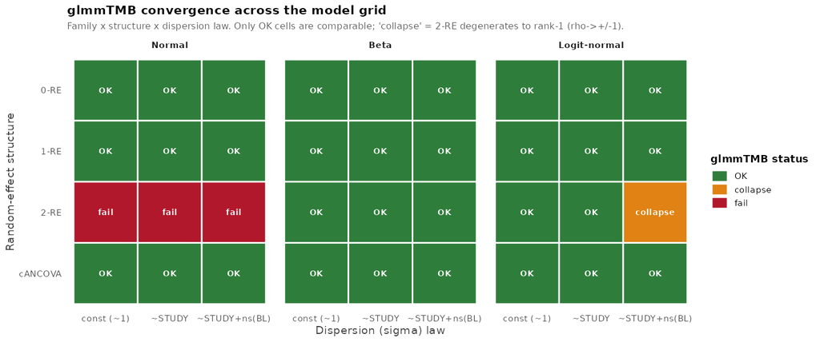

glmmTMB convergence across the full grid (family x structure x dispersion law). Green = valid fit (finite logLik, positive-definite Hessian). Orange ‘collapse’ = the 2-RE converged numerically but degenerated to rank-1 (rho pinned to +/-1), so it is not a usable two-factor fit. Red ‘fail’ = no valid fit. The 0-RE, 1-RE and cANCOVA rows converge for every family and law; the 2-RE row is where the grid breaks.

Three facts fall out of the map, and they set up the rest of the chapter:

- **The comparable core is complete under constant $\sigma$ — with one gap.** Every family, at 0-RE, 1-RE and cANCOVA, converges under all three laws; and under **constant $\sigma$** the 2-RE converges cleanly for the two **bounded** families (Logit-normal $\rho=0.61$, Beta $\rho=0.63$). The single exception is the **Normal 2-RE**, which fails under *every* law (next bullet). So the models the family and structure comparisons actually range over are all admissible under constant $\sigma$ — which is why those comparisons (Section 7.3) are read there, on identical footing.
- **The unbounded Normal cannot host two random effects.** The Normal 2-RE **fails under every law, constant $\sigma$ included** — on the letter scale the eye-level baseline variance is not identified, so the $2\times2$ $\Sigma$ is singular. This is a purely numerical fact about the fit (a separate matter from whether the Normal is a good *family*, which the calibration results settle).
- **The production variance law breaks the frequentist 2-RE.** The Logit-normal 2-RE is fine under constant $\sigma$ and `~STUDY`, but **collapses to rank-1** ($\rho\to-0.999$) the moment the baseline-varying `~STUDY + ns(BL_DV)` law is added — the $\sigma$-spline and the eye-level baseline factor compete for the same variance (Section 7.3.2). Since the endpoint *needs* that law (Section 7.3), the matched-law 2-RE cannot be fitted here and must move to full-Bayes (Section 7.4). The convergence map is the direct evidence for that hand-off.

The comparison below is therefore made on the converged constant-$\sigma$ core; the baseline-varying law is reintroduced only in the full-Bayes final comparison, where priors restore the 2-RE’s identifiability.

## 7.3 Model selection on the full grid

The family and structure decisions are read off **one** object: every converged cell of the grid — family (Normal, Beta, Logit-normal) × structure (0-RE, 1-RE, 2-RE, cANCOVA) × dispersion law (const, `~STUDY`, `~STUDY+ns(BL)`) — scored on the same forward-conditional four-functional yardstick (Section 7.1), with **coverage, bias and Interval Score** for each functional. The convergence map (Section 7.2) already told us which cells are admissible; the table below scores them and tags the rest.

Full model grid on the forward-conditional yardstick. Coverage (% of 25 study-arms in the 90% PI; target 90) for all four functionals, plus bias and Interval Score (lower = better) for the two discriminating functionals — SD CFBL and the ceiling — where families and structures actually separate (mean CFBL and the gainer rate are solved almost everywhere). Non-converged cells are tagged: ‘fail’ = no valid glmmTMB fit; ‘collapse’ = 2-RE degenerated to rank-1. The unbounded Normal 2-RE fails under every law; the Logit-normal 2-RE collapses only under the baseline-varying law. Full per-functional bias/IS detail in Section 13.

| Family | Structure | sigma law | cov mean | cov SD | cov gain | cov ceil | SD bias | SD IS | ceil IS | Status |
| --- | --- | --- | --- | --- | --- | --- | --- | --- | --- | --- |
| Normal | 0-RE | const | 96 | 44 | 60 | 32 | 0.2 | 19.0 | 71.1 |  |
| Normal | 0-RE | ~STUDY | 96 | 64 | 72 | 28 | 0.4 | 6.8 | 72.7 |  |
| Normal | 0-RE | ~STUDY+ns(BL) | 88 | 60 | 68 | 68 | 1.0 | 14.1 | 27.0 |  |
| Normal | 1-RE | const | 100 | 28 | 80 | 68 | -1.8 | 24.6 | 15.6 |  |
| Normal | 1-RE | ~STUDY | 100 | 24 | 84 | 76 | -1.4 | 16.8 | 13.1 |  |
| Normal | 1-RE | ~STUDY+ns(BL) | 84 | 56 | 68 | 88 | 0.1 | 9.5 | 14.6 |  |
| Normal | 2-RE | const |  |  |  |  |  |  |  | – fail – |
| Normal | 2-RE | ~STUDY |  |  |  |  |  |  |  | – fail – |
| Normal | 2-RE | ~STUDY+ns(BL) |  |  |  |  |  |  |  | – fail – |
| Normal | cANCOVA | const | 100 | 36 | 80 | 44 | -0.2 | 15.8 | 35.4 |  |
| Normal | cANCOVA | ~STUDY | 100 | 44 | 80 | 40 | -0.1 | 14.0 | 38.9 |  |
| Normal | cANCOVA | ~STUDY+ns(BL) | 100 | 32 | 84 | 40 | -0.1 | 13.9 | 36.0 |  |
| Beta | 0-RE | const | 96 | 36 | 68 | 44 | -0.1 | 16.4 | 48.3 |  |
| Beta | 0-RE | ~STUDY | 96 | 72 | 88 | 52 | 0.1 | 8.1 | 46.1 |  |
| Beta | 0-RE | ~STUDY+ns(BL) | 84 | 64 | 84 | 68 | 0.4 | 11.4 | 18.6 |  |
| Beta | 1-RE | const | 100 | 32 | 80 | 96 | -1.9 | 25.6 | 6.6 |  |
| Beta | 1-RE | ~STUDY | 100 | 28 | 72 | 100 | -1.6 | 20.5 | 6.6 |  |
| Beta | 1-RE | ~STUDY+ns(BL) | 96 | 56 | 64 | 68 | -0.4 | 10.4 | 16.0 |  |
| Beta | 2-RE | const | 100 | 44 | 92 | 72 | -0.3 | 12.0 | 13.5 |  |
| Beta | 2-RE | ~STUDY | 100 | 48 | 84 | 68 | -0.3 | 12.4 | 13.1 |  |
| Beta | 2-RE | ~STUDY+ns(BL) | 96 | 44 | 84 | 68 | 1.6 | 21.1 | 21.3 |  |
| Beta | cANCOVA | const | 100 | 44 | 88 | 64 | -0.3 | 11.6 | 13.9 |  |
| Beta | cANCOVA | ~STUDY | 100 | 40 | 84 | 76 | -0.4 | 12.5 | 12.8 |  |
| Beta | cANCOVA | ~STUDY+ns(BL) | 100 | 44 | 88 | 80 | -0.4 | 12.3 | 11.8 |  |
| Logit-normal | 0-RE | const | 92 | 36 | 76 | 56 | -0.2 | 13.9 | 33.9 |  |
| Logit-normal | 0-RE | ~STUDY | 96 | 72 | 88 | 64 | 0.1 | 12.2 | 30.8 |  |
| Logit-normal | 0-RE | ~STUDY+ns(BL) | 80 | 68 | 84 | 76 | 0.5 | 13.3 | 12.7 |  |
| Logit-normal | 1-RE | const | 100 | 36 | 80 | 92 | -1.8 | 22.5 | 6.6 |  |
| Logit-normal | 1-RE | ~STUDY | 100 | 20 | 84 | 100 | -1.4 | 21.3 | 6.1 |  |
| Logit-normal | 1-RE | ~STUDY+ns(BL) | 84 | 56 | 72 | 64 | -0.3 | 12.2 | 14.5 |  |
| Logit-normal | 2-RE | const | 100 | 40 | 88 | 76 | -0.2 | 11.2 | 12.6 |  |
| Logit-normal | 2-RE | ~STUDY | 100 | 48 | 84 | 76 | -0.1 | 13.6 | 12.8 |  |
| Logit-normal | 2-RE | ~STUDY+ns(BL) |  |  |  |  |  |  |  | – collapse – |
| Logit-normal | cANCOVA | const | 100 | 40 | 88 | 76 | -0.2 | 10.9 | 12.6 |  |
| Logit-normal | cANCOVA | ~STUDY | 100 | 48 | 84 | 76 | -0.1 | 12.7 | 12.9 |  |
| Logit-normal | cANCOVA | ~STUDY+ns(BL) | 100 | 44 | 84 | 76 | -0.1 | 12.0 | 12.4 |  |

The grid is read on two slices — one holding the dispersion law fixed to isolate the **structure** axis, one holding the structure fixed to isolate the **dispersion-law** axis — each faceted by the four functionals so the discriminating ones (SD CFBL, ceiling) are visible separately.

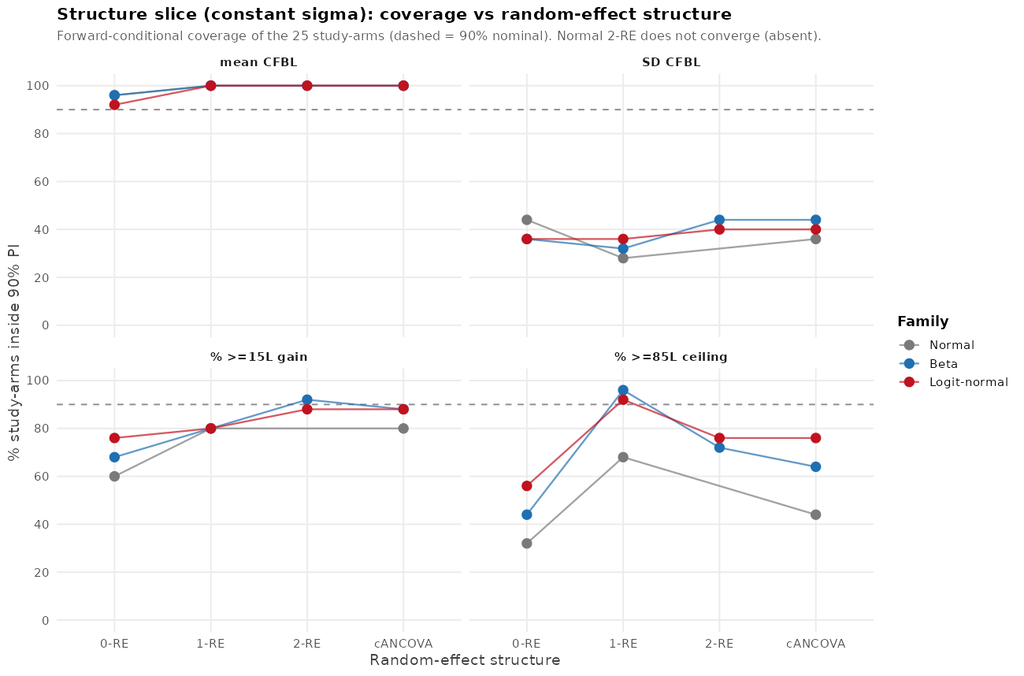

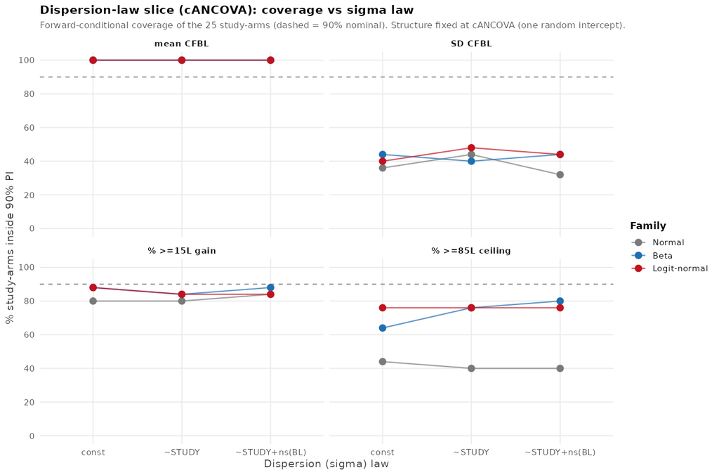

Three verdicts fall out of the grid, and together they fix the engine:

  Mean CFBL and the gainer rate depend on the *location* of the predictive, fixed by the mean model; the ceiling depends on how much mass the *bounded support* pushes past 85L, governed by the family; and the arm-level SD is dominated by the between-eye factor the 2-RE/baseline conditioning already sets. On all four, the $\sigma$ law is a refinement, not a decision driver — so the family and structure verdicts are read off the constant-$\sigma$ core without loss.

The likelihood tells the same story once it is read on the *right* model. On the production cANCOVA form (post rows only) the baseline-varying law is still AIC-preferred but by a modest margin – a $\Delta$AIC of about **177** for constant $\sigma$ vs the $\text{STUDY}+\text{ns(BL)}$ law (Section 14). And AIC rewards pointwise *residual* density, which is exactly the 12% component the four arm-level functionals barely see: the criterion that most likes the spline is measuring the thing the generator is least judged on. **Generator selection is made on the forward-conditional calibration, not AIC** — and on that metric constant $\sigma$ is fully adequate. The baseline-varying law is therefore retained only as an optional refinement (it does tidy the residual SD, Section 7.6.2); the shipped default is the parsimonious **constant-$\sigma$ cANCOVA**. Fitting the richer law *together with the joint 2-RE* is in any case the one cell that breaks glmmTMB (Section 7.2), which is why the full-Bayes check that follows carries the variance law on the well-posed cANCOVA parametrization.

### 7.3.1 Where the coverage actually comes from: a mean-model ablation

The dispersion-law slice can read as if study membership does not matter – adding $\text{STUDY}$ to the *variance* barely moves coverage. That would be the wrong lesson. STUDY (and ARM) enter the **mean**, not just $\sigma$, and forward simulation applies them at every cell (the grid varies only the $\sigma$ formula; the mean always carries $\text{STUDY}+\text{ns(BL)}+\text{ARM}+\text{M12}$). To show what each mean term is worth, we hold the family, the random intercept, and constant $\sigma$ fixed and add the mean terms one at a time – scored the same forward-conditional way as above:

Mean-model ablation on the production engine (Logit-normal cANCOVA, (1|ID), CONSTANT sigma). Coverage = % of the 25 study-arms inside the 90% predictive interval; only the MEAN formula changes. Baseline enters as ns(BL); M12 is the timepoint term. The step that rescues arm-level LOCATION (mean CFBL 40 -> 96%) is adding STUDY + ARM to the mean; the step that rescues arm-level SPREAD (SD CFBL 0 -> 36%) is the baseline spline.

| Mean model | mean CFBL | SD CFBL | % >=15L | % >=85L | npar | AIC |
| --- | --- | --- | --- | --- | --- | --- |
| M1: M12 only | 40 | 0 | 32 | 40 | 4 | 11866.5 |
| M2: + ns(BL) | 40 | 36 | 64 | 64 | 8 | 8821.8 |
| M3: + STUDY + ARM | 96 | 40 | 84 | 76 | 29 | 8653.4 |

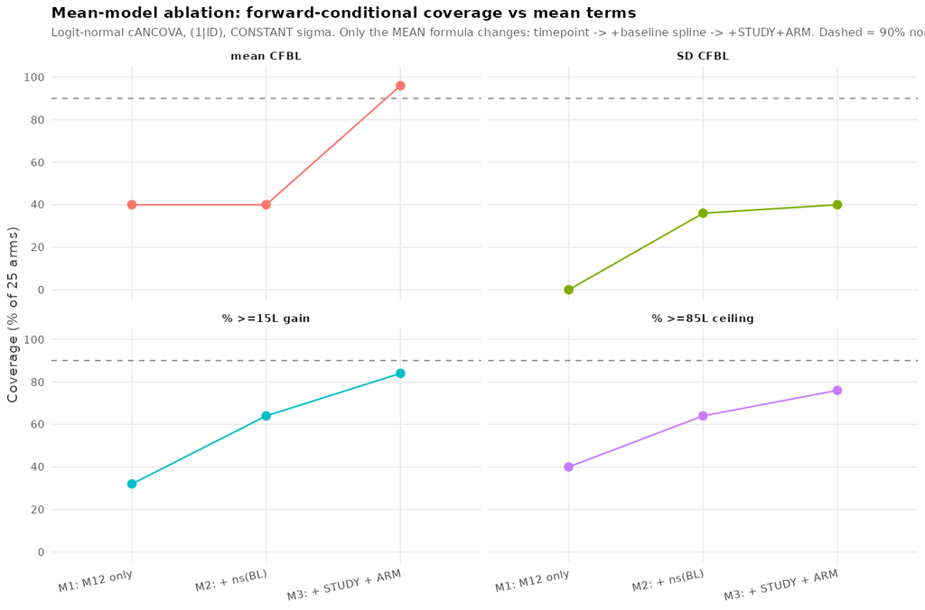

Mean-model ablation, forward-conditional coverage faceted by functional (Logit-normal cANCOVA, (1|ID), constant sigma; dashed = 90% nominal). Left-to-right adds mean terms only. The baseline spline (M2) rescues the per-arm SD (0 -> 36%) and lifts the threshold functionals; adding STUDY + ARM (M3) is what lifts mean-CFBL coverage from 40% to 96%. The decisive study effect lives in the MEAN – which is why varying study in the sigma law alone (previous figure) did little.

Read together with the dispersion-law slice, this settles which axis carries the load:

- **Timepoint only (M1)** – mean-CFBL coverage 40%, and SD coverage **0%**: a pooled mean cannot place any arm, and with no baseline term the per-arm spread is wrong for every arm.
- **+ baseline spline (M2)** – SD coverage jumps **0 -> 36%** and the threshold functionals roughly double. Conditioning on baseline is what re-centres each arm’s spread; this is the spline doing real work *in the mean*, distinct from the negligible $\sigma$-spline.
- **+ STUDY + ARM (M3)** – mean-CFBL coverage **40 -> 96%**, gainer to 84%, ceiling to 76%. The arm-level *location* is carried almost entirely by the study and arm mean terms.

So the study effect is not weak – it is **essential, and it acts through the mean**. The earlier finding is the precise complement: study membership in the *dispersion* is what is secondary, because $\sigma$ is only about 12% of the per-arm SD (Section 14). We also confirmed the plumbing directly: under the $\sigma\sim\text{STUDY}$ law the simulator draws eight distinct study-specific $\sigma$ values (0.16–0.36 on the logit scale) and they do widen the *spread* of per-arm SDs – the effect is real, just too small a lever to change coverage. Both mean and variance study effects are applied in forward simulation; only the mean one is decisive.

### 7.3.2 Why a second random effect collapses to one on the bounded families

Table 1: Rank-1 vs rank-2 variance components by family. On the bounded families (Beta, Logit-normal) the baseline random-effect SD on the working (logit) scale is tiny (tau_BL ~ 0.005-0.007) next to the endpoint RE (tau_post ~ 0.43-0.45), and the fitted correlation pins to the +/-1 boundary - so the second RE carries no independent information and rank-2 degenerates to rank-1.

| Model | $\tau_{BL}$ (baseline RE SD) | $\tau_{post}$ (endpoint RE SD) | $\hat\rho$ | RE scale |
| --- | --- | --- | --- | --- |
| Normal rank-1 | 0.454 | 8.648 | 1.000 | identity |
| Normal rank-2 | 0.454 | 8.645 | 0.969 | identity |
| Beta rank-1 | 0.007 | 0.430 | 1.000 | logit |
| Beta rank-2 | 0.007 | 0.430 | 1.000 | logit |
| Logit-normal rank-1 | 0.005 | 0.448 | 1.000 | identity |
| Logit-normal rank-2 | 0.005 | 0.448 | 1.000 | identity |

Two things drive the collapse, and both are properties of the **bounded** link, not of the data:

- **The baseline RE variance is negligible on the logit scale.** Baseline BCVA is squeezed hard by the transform (most eyes enter in a band where the logit is steep), so $\tau_{BL}\approx0.005$–$0.007$ against an endpoint $\tau_{post}\approx0.43$–$0.45$ — a ratio of ~1:70. There is almost no eye-level baseline variance left for a second RE to explain once the mean structure has used the observed baseline.
- **The correlation pins to the boundary.** With one side of the pair near-degenerate, the fitted $\hat\rho$ hits $\pm1$ (Table 1), i.e. the 2-RE covariance is rank-1 — the endpoint RE and the (vanishing) baseline RE are perfectly collinear. The likelihood confirms it: rank-1 and rank-2 reach an **identical** logLik per family, so the only AIC difference is the +2 penalty for the extra (unidentified) parameter.

By contrast the Normal (identity-link) model keeps a real baseline RE ($\tau_{BL}=0.454$) and estimates $\hat\rho=0.97$ — the rank-2 structure *is* identified there — but the Normal is already ruled out on the bound and the mean-locked-variance axes (Section 7.3). For the families that survive, the practical consequence is clean: **conditioning the endpoint on the observed baseline through the mean (cANCOVA) is equivalent to a 2-RE model when the baseline is observed**, at one fewer parameter and with no boundary pathology. That is the structure the shipped model uses. The per-arm SD gap that remains after this is therefore *not* a structure problem — it is the tail-shape problem diagnosed in Section 7.6.3 and fixed in Section 7.7.

## 7.4 Final comparison in full-Bayes: family, structure, and variance law together

**What was fitted in full-Bayes.** The glmmTMB screen (Section 7.3) narrowed the field cheaply; `brms` is then used for the cells that ML cannot identify and to confirm the verdicts under the production variance law. The full-Bayes work is **three targeted comparisons**, each holding two axes fixed and varying the third, so that every axis is decided on a clean contrast rather than one intractable 4×4×3 grid. All cells use `brms`, 4 chains × 4000 iterations, `adapt_delta=0.95`, and are scored **forward-conditional** (draw the posterior predictive on the post rows, back-transform to letters, compare the four functionals to the observed anchors: mean CFBL = 9.06, SD CFBL = 11.44, $P(\ge 15L) = 0.291$, $P(\ge 85L) = 0.071$). The three comparisons and exactly what was run in each:

| Axis under test | Families fitted | RE structures | Variance ($\sigma$) laws | Read in |
| --- | --- | --- | --- | --- |
| **Family** | Beta, Gaussian-clamp, Logit-normal, Skew-normal | 2-RE (fixed) | constant (fixed) | Figure 1 |
| **Structure** | Logit-normal (Gaussian-clamp too, for the family overlay) | 1-RE, 2-RE, cANCOVA | constant (fixed) | Figure 3, Section 7.3 |
| **Variance law** | Logit-normal (Beta failed, below) | cANCOVA, joint 2-RE | constant, $\sim$STUDY, $\sim$STUDY+ns(BL) | scorecard below |

The variance-law row pits the two production parametrizations of Section 6.2.3 against each other: **cANCOVA** (baseline as an observed covariate on the post rows) versus the **joint 2-RE** (baseline as a modelled response), plus a **plain-Normal reference**. A cell is admissible only if it **converged** ($\hat R<1.1$).

**Why the grid is Logit-normal, not Beta.** The glmmTMB screen (Section 7.3) left Logit-normal and Beta tied, with Logit-normal preferred on *mechanism* (variance decoupled from the mean, so the $\sigma$ law can move freely). That tie-break is decisive in full-Bayes for a second, empirical reason: **the Beta 2-RE does not converge in `brms` either** ($\hat R=1.98$, ESS 6; Section 11). The mean-locked Beta variance $\mu(1-\mu)/(1+\phi)$ fights the eye-level random effect for the same dispersion, and no prior rescued it. So carrying Beta into the production grid was not an option — it is kept as the *glmmTMB* sensitivity twin (where it fits under constant $\sigma$ and matches Logit-normal on all four functionals, Section 7.3), and the full-Bayes grid is run on the Logit-normal engine that actually samples.

Figure 1 shows this family comparison directly — the four families held at the production 2-RE and constant $\sigma$, forward-conditional. The picture matches the glmmTMB screen: the **ceiling** (% $\ge$ 85L) is where the bounded **Logit-normal** (76%) separates from the clamped unbounded **Gaussian** (44%) and **Skew-normal** (52%), while **SD CFBL** is the hard functional for every family (40–44%). Beta 2-RE is annotated as inadmissible (the non-convergence noted above), not plotted.

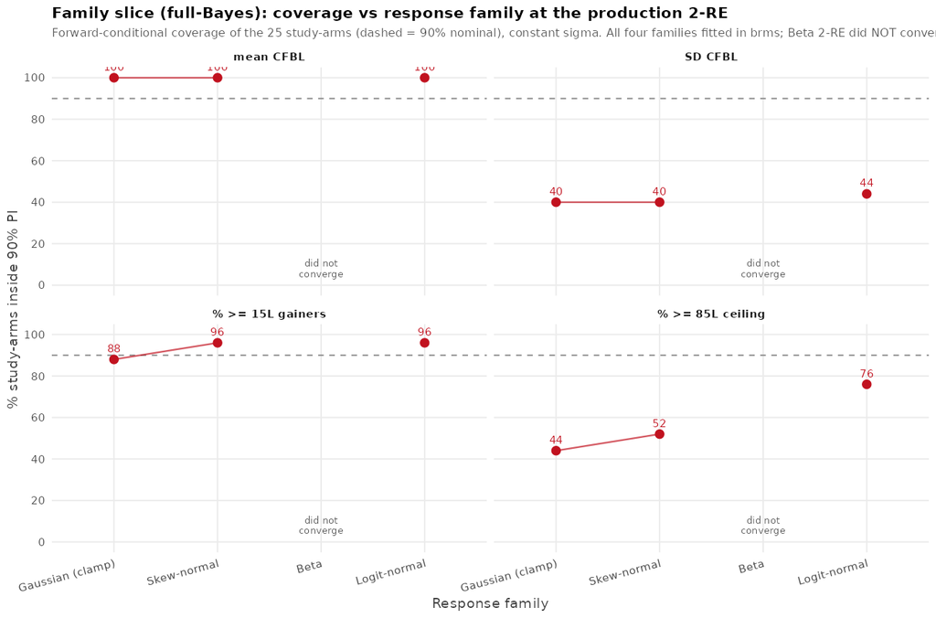

Figure 1: Full-Bayes family comparison at the production 2-RE (constant sigma): forward-conditional coverage (% of 25 study-arms inside the 90% predictive interval; dashed = 90% nominal), faceted by functional, for all four families fitted in brms. Beta 2-RE did NOT converge (R-hat 1.98, ESS 6) so its scores are inadmissible and its bars are omitted (annotated instead). Among the converged three, the bounded Logit-normal holds the ceiling where the clamped Gaussian and Skew-normal leak it; SD CFBL is hard for all. This is the full-Bayes confirmation of the family verdict read off glmmTMB under constant sigma (Section 7.3).

The convergence outcome is itself a result, and it mirrors the glmmTMB map one tier up. Reading Figure 2: **cANCOVA converges under every $\sigma$ law**, and the **joint 2-RE converges under constant $\sigma$** — but the two **joint 2-RE cells that add a variance law** fail ($\hat R$ 1.20–1.24). Priors buy back the joint 2-RE at constant $\sigma$ (where glmmTMB already worked) but not the joint 2-RE *plus* a structured $\sigma$: with one baseline point per eye, that combined axis is too ill-conditioned even for HMC. So the scorecard below compares the admissible (converged) cells; the failed joint cells are shown only to document the degeneracy.

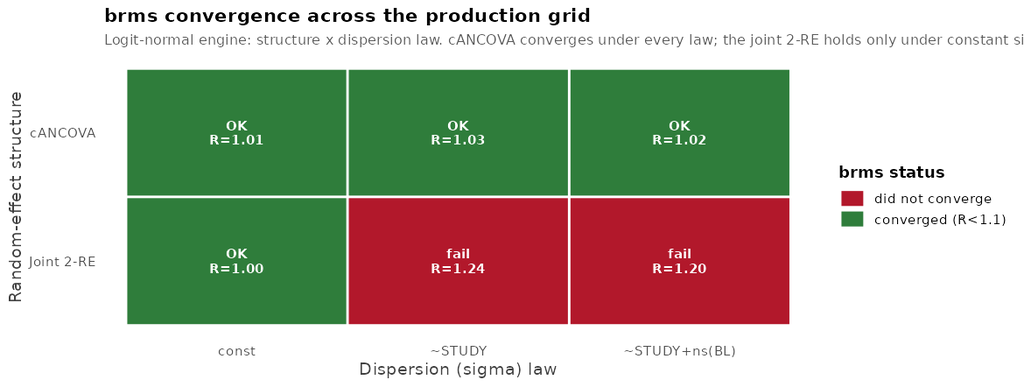

Figure 2: brms convergence across the production grid (structure x dispersion law), the full-Bayes analogue of the glmmTMB scan in Section 7.2. Green = converged (max R-hat < 1.1); red = did not converge. cANCOVA converges under every sigma law; the joint 2-RE holds under constant sigma but breaks once a sigma law is added (R-hat 1.24 / 1.20) – priors regularise the 2-RE geometry but not the 2-RE plus a structured sigma. This is why the production engine’s variance law is carried by the cANCOVA parametrization.

Full-Bayes scorecard. Observed anchors: P(≥15L)=0.291, P(≥85L)=0.071. Calibration metrics are shown only for cells that converged (R-hat<1.1); the two Joint 2-RE cells that add a variance law did NOT converge (R-hat 1.20–1.24, marked no) so their scores are undefined and left blank — they appear only to document the τ_BL≈0 near-degeneracy. Among converged cells calibration is essentially tied; LOOIC is not used for the joint-vs-cANCOVA decision (see Section 11 for the fair post-only elpd grid).

| Structure | σ law | Converged | max R-hat | Bias (mean CFBL) | SD ratio | P(≥15L) | P(≥85L) | Score |
| --- | --- | --- | --- | --- | --- | --- | --- | --- |
| cANCOVA | σ~STUDY+ns(BL) | yes | 1.020 | -0.057 | 1.003 | 0.282 | 0.071 | 0.267 |
| cANCOVA | σ=const | yes | 1.009 | -0.071 | 1.003 | 0.283 | 0.072 | 0.281 |
| cANCOVA | σ~STUDY | yes | 1.030 | -0.059 | 1.006 | 0.283 | 0.072 | 0.299 |
| Joint 2-RE | σ=const | yes | 1.003 | -0.075 | 1.003 | 0.282 | 0.072 | 0.305 |
| Normal (letter scale) ref | — | yes | 1.009 | -0.012 | 1.000 | 0.283 | 0.084 | 0.432 |
| Joint 2-RE | σ~STUDY+ns(BL) | **no** | 1.195 | — | — | — | — | — |
| Joint 2-RE | σ~STUDY | **no** | 1.244 | — | — | — | — | — |

The **structure** comparison scores all **three** Logit-normal random-effect structures on the same forward-conditional yardstick (coverage = % of the 25 study-arms whose observed functional falls inside the 90% predictive interval), fitted on one dataset with the same arms, seed and metric (Figure 3). cANCOVA belongs on this axis because it too is a random-intercept model (`ylogit ~ STUDY + ns(BL_DV) + M12 + SARM + (1 | ID)`); the three cells differ only in how the eye’s endpoint effect is drawn, while every one conditions on the observed baseline (legitimate: baseline is measured before randomisation):

| Structure | Eye random effect | How the endpoint effect is drawn |
| --- | --- | --- |
| **1-RE** | `(0 + post \\| ID)` | marginal: $u_{post}\sim N(0,\tau_{post}^2)$ |
| **2-RE** | `(0 + phase \\| ID)` | condition $u_{BL}$ on observed $y_{BL}$, then $u_{post}\mid u_{BL}$ via $\rho$ |
| **cANCOVA** | `ns(BL_DV)` + `(1 \\| ID)` | marginal intercept $u\sim N(0,\tau_{ID}^2)$; baseline in the fixed mean |

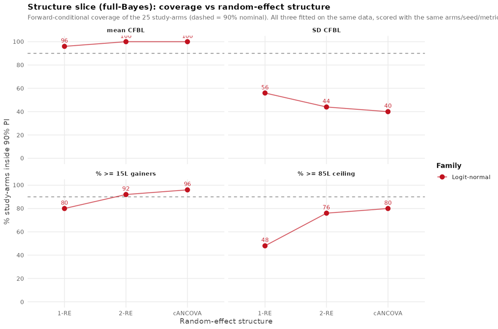

Figure 3: The three random-effect structures on identical footing (full-Bayes, Logit-normal): forward-conditional coverage faceted by functional (% of 25 study-arms inside the 90% predictive interval; dashed = 90% nominal). All three were fitted on the same data and scored with the same arms, seed and metric. cANCOVA IS a random-effect structure (random intercept + baseline as a fixed ns() covariate), so it belongs on this axis. Result: cANCOVA (ceiling 80, gainers 96) and the joint 2-RE (76, 92) are effectively tied and both clearly beat the 1-RE (48, 80) on the threshold functionals; SD CFBL orders cANCOVA (40) <= 2-RE (44) < 1-RE (56).

- **Convergence.** Only the two joint cells that *also* add a variance law fail to sample ($\hat R$ 1.20 and 1.24, zero divergences, 4000 iters) — the $\tau_{\text{BL}}\approx0$ near-degeneracy of Section 6.2.3, where one baseline point per eye leaves the joint model’s baseline-variance axis barely identified. Every cANCOVA cell converges. This is the one axis on which the two parametrizations genuinely differ.
- **The $\sigma$ law is a wash.** Adding $\text{STUDY}+\text{ns(BL)}$ dispersion changes none of the four functionals: `can_const` (score 0.281) and `can_study_bl` (0.267) are near-identical, the full-Bayes confirmation of the §7.3 result that dispersion is a secondary axis (the per-arm SD is dominated by the between-eye factor ~88%, not the residual $\sigma$ ~12%; Section 14).
- **Fair LOO agrees and does not separate them.** On the common 8,362 post rows the best joint (`joint_study_bl`, elpd −1409.6) and best cANCOVA (`can_study_bl`, −1423.5) differ by ~14 against an SE of ~100 — indistinguishable, exactly as expected for the same model in the $\tau_{\text{BL}}\to0$ limit. (LOO is corroboration only, not the selector: `p_loo ≈ 3,770` against $n=8{,}362$ flags the per-eye intercept as high-influence.)

**Shipped default: constant-$\sigma$ cANCOVA (`can_const`).** It ties the 2-RE on every functional and on the fair LOO, converges everywhere the joint+variance-law cells do not, and costs about half the runtime; `can_study_bl` is kept only as an optional refinement for its slightly tidier residual SD (Section 7.6.2). The two structure results are consistent, not contradictory: the second random effect earns its place when the baseline is *unknown* and must be predicted (2-RE beats 1-RE, Section 7.3); once the baseline is *observed* and conditioned on, cANCOVA reproduces the endpoint just as well with fewer moving parts.

## 7.5 The three axes, settled together

With the full-Bayes fit in hand, the production engine is fixed on all three axes at once, under the variance law it will ship with. The preceding sections settled each axis on a different comparison — family on the ceiling and SD (Section 7.3), structure on the forward 2-RE-vs-1-RE contrast (Section 7.4) and the 2-RE-vs-cANCOVA tie (Section 7.4), and the variance law on the scorecard — so this table is the single place where all three decisions are read together:

| Axis | Decision | Evidence |
| --- | --- | --- |
| **Family** | Logit-normal (bounded, variance-decoupled); Beta the sensitivity twin | ceiling + SD hold under brms too; the forward-conditional family score confirms it at the production 2-RE (Section 7.4) |
| **Structure** | cANCOVA $\equiv$ 2-RE at M9/M12; cANCOVA on parsimony, or the 2-RE where the baseline is unobserved | fair post-only elpd tie (above) + the forward 2-RE-vs-1-RE result (Section 7.4) |
| **Variance law** | constant $\sigma$ (`can_const`); baseline-varying $\sigma\sim\text{STUDY}+\text{ns(BL\_DV)}$ (`can_study_bl`) an optional refinement | SD ratio 1.00 either way; the law barely moves the production functionals once bounded+decoupled (Section 7.3) |

The constant-$\sigma$ glmmTMB screens (Section 7.3) chose the family and structure by isolating one axis at a time; this section confirms both under full-Bayes and fixes the variance law — so `can_const` (Logit-normal, cANCOVA, constant $\sigma$) is the shipped engine, with the Logit-normal 2-RE its equivalent when the design requires an unobserved baseline.

### 7.5.1 Frequentist or full-Bayes cANCOVA? Scored fairly, they coincide

The shipped cell is fit by **both** engines on the identical `qlogis(Y/100)` response (Section 6.2.7), so the only question is whether the choice of engine changes the endpoint score. It does not — once the two are scored on **equal footing**. The subtlety is that the forward-conditional draw can either hold parameters at a point estimate (**plug-in**) or propagate their uncertainty: the glmmTMB score plugs in the MLE, whereas the default brms score draws a fresh $(\eta,\sigma,\tau)$ per replicate. Re-scoring brms a second way — fixing every parameter at its posterior **mean** (the plug-in analogue) — isolates the engine from that scoring choice:

[output not shown]

Figure 4 shows this per arm, both engines overlaid, across all four functionals.

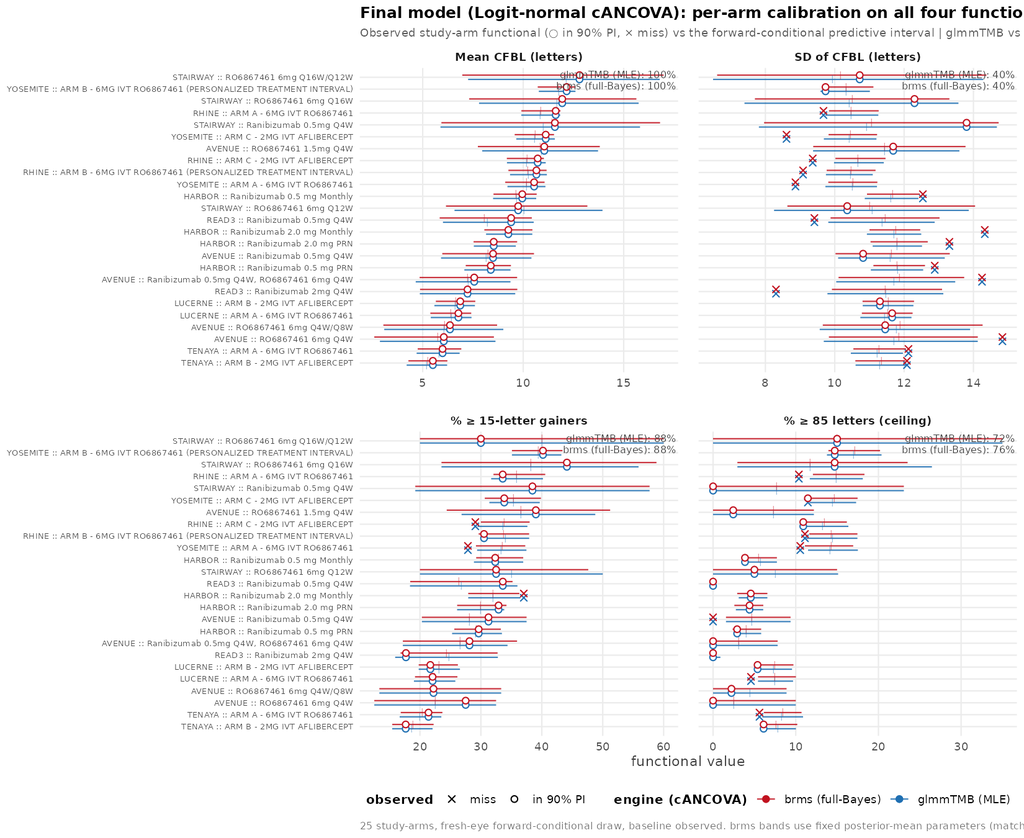

Figure 4: Final model (Logit-normal cANCOVA): per-arm observed functional (circle = inside the 90% PI, cross = miss) vs the forward-conditional predictive interval, for all four endpoint functionals, with glmmTMB and brms overlaid on the fair plug-in basis. The two engines track the same arms; mean and gainers are well covered, SD and ceiling are the binding functionals (addressed in Section 7.7).

**Selected model**

**Shipped engine for the four endpoint functionals: the Logit-normal cANCOVA with constant $\sigma$ (`can_const`), fit in glmmTMB, scored forward-conditionally on unseen eyes. brms selects and agrees with the same cell on the fair plug-in basis (Section 7.5.1, Section 7.4).**

- **Family — Logit-normal.** Bounded (logit, no cap leakage) *and* variance-decoupled from the mean — with Beta, the only family that keeps coverage on *both* the ceiling and the SD criterion where the additive families collapse (Section 7.3).
- **Structure — cANCOVA (random intercept + baseline covariate).** With the baseline *observed*, cANCOVA reproduces the endpoint as well as the 2-RE on every functional and on the fair LOO (Section 7.4), with one fewer variance component and no near-degenerate $\tau_{\text{BL}}$. The **Logit-normal 2-RE is the equivalent form when the design needs an unobserved baseline** — there brms recovers a well-identified $\tau_{\text{BL}}=0.46$, $\tau_{\text{post}}=0.61$, $\rho=0.63$ where glmmTMB collapses to rank-1 (Section 7.3.2), and the free $\rho$ earns the second factor its place in the **2-RE-vs-1-RE** comparison (Section 7.4). Either form can drive the §8 simulation.
- **SD structure — constant $\sigma$.** The baseline-varying law ($\log\sigma=\kappa+\delta_{\text{STUDY}}+g(\text{BL})$) leaves all four functionals unchanged (Section 7.3); it is retained only as an optional refinement (`can_study_bl`) for its slightly tidier residual SD, not as the production selector.
- **RE distribution — a Student-t eye effect is the one open refinement.** The Gaussian random intercept is heavy-tailed ($\nu\approx5$), and a variance-matched $t$ redraw lifts exactly the two binding functionals — ceiling and SD — without disturbing mean or gainers (Section 7.7). It is the recommended refinement to carry into the §8 simulation.
- **1-RE is the robustness check**, not the selected model: marginal by design, it over-disperses the threshold criteria (Section 7.3).

**Learnings that changed the design.**

1. **Score forward, not in-sample.** In-sample RE reuse inflates coverage and hides the 1-RE↔︎2-RE difference; the honest forward-conditional score is what makes the second random effect earn its place (Section 7.4).
2. **A richer $\sigma$ law does not fix SD.** The per-arm CFBL SD is governed by the between-eye random effect, not the residual scale; the real SD defect was baseline-row contamination, fixed by the ANCOVA post-only form (Section 7.3).
3. **The residual SD/ceiling gap is a random-effect-distribution problem.** It is *not* closed by family or by adding a second random effect (Section 7.3.2), but the eye random effect is heavy-tailed ($\nu\approx5$) and a Student-t redraw does lift both binding functionals (Section 7.7) — so the remaining lever is the RE tail, not the mean model.

The selected model’s convergence and the full per-cell sampler diagnostics are in Section 11.

## 7.6 Analysing the final model: the Logit-normal cANCOVA in detail

With the engine fixed (Section 7.5.1), this section examines the **shipped model** itself — the Logit-normal cANCOVA with a Gaussian eye intercept and constant $\sigma$ — against the observed data: a visual predictive check of the endpoint distribution, the per-arm spread it reproduces, and a diagnosis of where its one residual miss comes from. The diagnosis at the end (the eye random effect is heavier-tailed than Gaussian) motivates the refinement developed in the next section; here we characterise the model as it ships.

### 7.6.1 Visual predictive check

The forward-conditional VPC draws a fresh eye from the population, pins it to its observed baseline through the `ns(BL_DV)` mean term, and compares the simulated 5th/50th/95th endpoint percentiles to the observed ones. Figure 5 shows this per study-arm and Figure 6 collapses it onto baseline strata, where the arm-level sparsity averages out. Endpoint data exist at M9 and M12 only; arms with a single on-schedule visit (e.g. Avenue = M9 only) are drawn as a vertical predictive interval at that visit rather than a connected band.

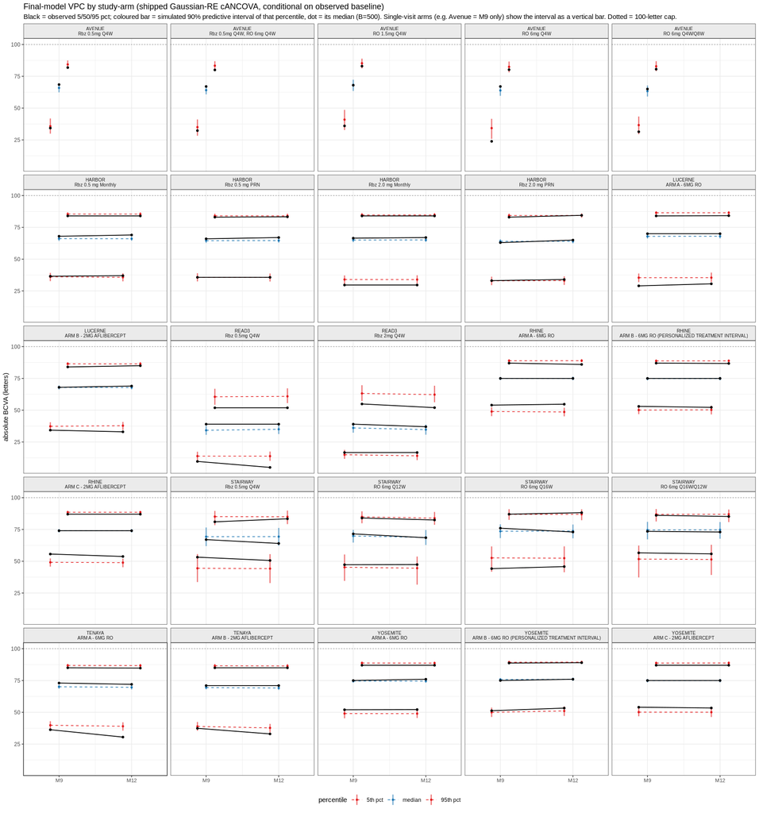

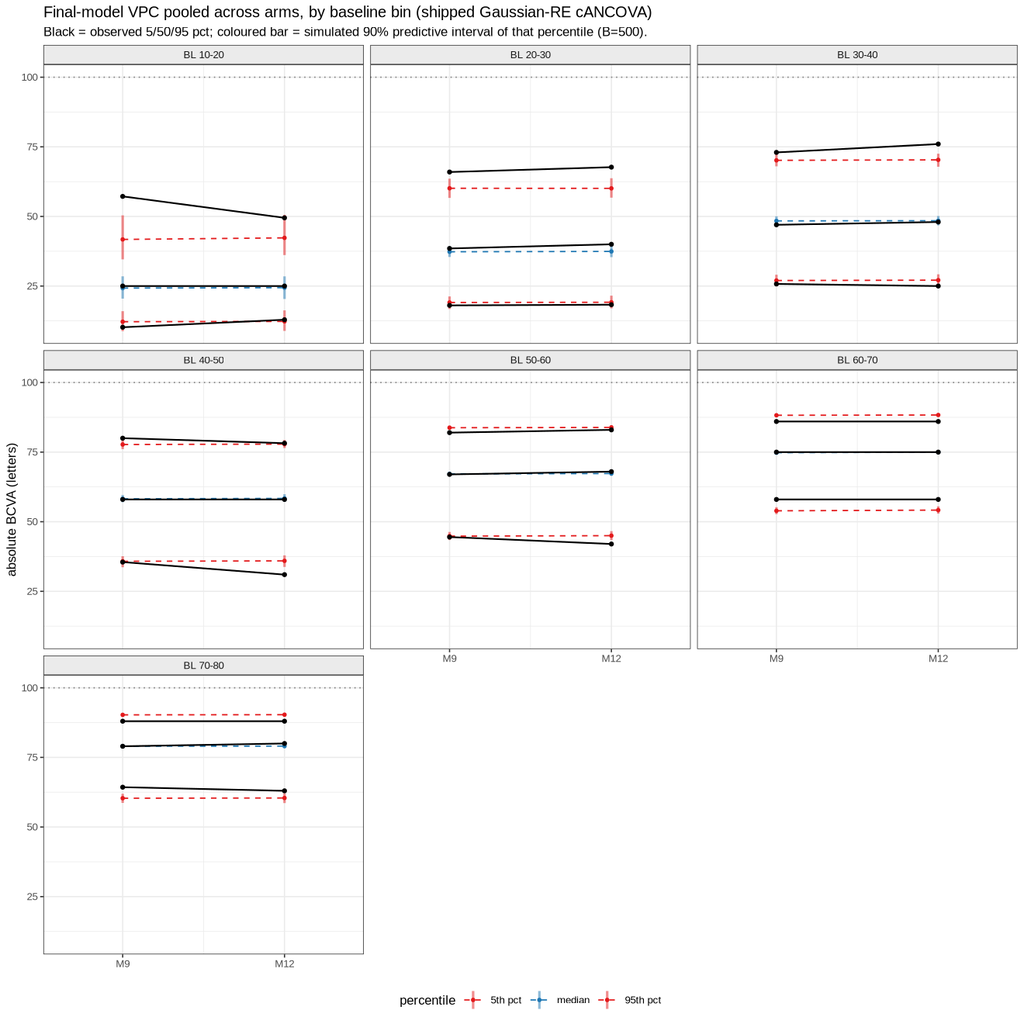

### 7.6.2 Per-arm spread: observed vs simulated CFBL SD

The binding functional is the per-arm SD of change-from-baseline. On the shipped cANCOVA (post-only $\sigma$, one Gaussian eye intercept) the simulated per-arm CFBL SD tracks the observed to within about a letter across the phase-3 arms:

Per-arm SD of CFBL (endpoint minus observed baseline): observed vs simulated under the shipped Logit-normal cANCOVA (post-only sigma, 1 Gaussian RE). Simulated/observed ratio sits in 0.8-1.2 across the large phase-3 arms; median absolute error ~1 letter. READ3 excluded (suspect low baseline, Section 9). Full table: results/obs_vs_sim_sd_cfbl.csv.

| STUDY | ARM | n | obs_SD | sim_SD | ratio |
| --- | --- | --- | --- | --- | --- |
| AVENUE | Ranibizumab 0.5mg Q4W | 64 | 10.82 | 11.85 | 1.10 |
| AVENUE | Ranibizumab 0.5mg Q4W, R | 64 | 14.25 | 11.89 | 0.83 |
| AVENUE | RO6867461 6mg Q4W/Q8W | 45 | 11.46 | 12.05 | 1.05 |
| AVENUE | RO6867461 1.5mg Q4W | 41 | 11.69 | 11.54 | 0.99 |
| AVENUE | RO6867461 6mg Q4W | 40 | 14.84 | 12.22 | 0.82 |
| HARBOR | Ranibizumab 0.5 mg PRN | 550 | 12.88 | 11.67 | 0.91 |
| HARBOR | Ranibizumab 2.0 mg Month | 548 | 14.33 | 11.60 | 0.81 |
| HARBOR | Ranibizumab 0.5 mg Month | 544 | 12.54 | 11.56 | 0.92 |
| HARBOR | Ranibizumab 2.0 mg PRN | 544 | 13.31 | 11.63 | 0.87 |
| LUCERNE | ARM A - 6MG IVT RO686746 | 589 | 11.66 | 11.39 | 0.98 |
| LUCERNE | ARM B - 2MG IVT AFLIBERC | 576 | 11.30 | 11.40 | 1.01 |
| RHINE | ARM B - 6MG IVT RO686746 | 567 | 9.09 | 10.46 | 1.15 |

Two reads of this table matter for how the SD functional should be judged:

- **Part of the coverage number is an over-tight interval — but only part.** With ~530 eyes per phase-3 arm the sampling SE of an arm’s SD is only $\approx\sigma/\sqrt{2n}\approx0.35$ letters, so the 90% predictive interval spans only about **1.5 letters**; a clinically negligible bias then reads as “not covered,” and several individual arms miss by under a quarter-letter. So the strict 40% *overstates the magnitude* of the deficiency. It does **not**, however, explain it away, and it would be dishonest to lean on interval-tightness alone: the **mean CFBL is scored against an essentially identical interval** (median half-width 1.06 L, vs 1.05 L for the SD — Section 7.6.2.1) and is covered at 92–100%, while the SD sits at 40–52%. If tightness were the driver the mean would fail too. The residual SD miss is therefore a **real, structured signal**, not a metric artefact — and the honest supporting diagnostic is that the *pooled* SD is essentially unbiased (simulated 11.0 vs observed 11.1 L, $-0.6\%$; Section 7.6.2.2), i.e. the generator gets the *typical* variability right and misses the *between-study spread* of it.
- **READ3 is the one persistent outlier** (simulated/observed SD ratio 1.35–1.54). Its baseline BCVA ($\sim 28$ letters) sits far below every other study and is under data-quality review (Section 9); at that low baseline the logit Jacobian amplifies a modest logit-scale $\sigma$ into a large letter-scale SD. It is excluded from the reads above and de-weighted in the recommendation.

Where does the real miss come from? Two separate levers, one already ruled out and one carried as future work. It is **not** a residual-scale problem — a richer $\sigma$ law does not close it (Section 7.3, Section 7.3.1), because the residual is only $\approx12\%$ of the per-arm SD. Part of it is the **random-effect tail**: the Gaussian eye intercept is too light-tailed to place enough extreme responders, which the fitted Student-$t$ fixes on the 5th/95th percentiles (quantified next). The part that remains after the tail fix is **between-study heterogeneity in the RE variance itself**, examined in Section 7.6.2.2 — a pooled $\tau$ cannot reproduce the HARBOR-to-YOSEMITE spread of per-arm SDs, and closing it needs a study-varying $\tau$, not a $\sigma$-law.

#### 7.6.2.1 Is the SD ruler unfairly tight? Compared against the other functionals, no

| functional | unit | PI half-width | typical value | margin (% of value) | coverage % |
| --- | --- | --- | --- | --- | --- |
| mean CFBL | L | 1.06 | 9.4 | 11.2 | 92 |
| SD of CFBL | L | 1.05 | 11.5 | 9.2 | 52 |
| % >=15L gainers | pp | 4.02 | 30.5 | 13.2 | 96 |
| % >=85L ceiling | pp | 2.83 | 4.6 | 61.7 | 88 |

#### 7.6.2.2 The residual gap is between-study SD heterogeneity, not residual sigma

Table 3 aggregates the per-arm CFBL SD to the study level for the large phase-3 studies (READ3 excluded, Section 9). Two facts settle what the SD miss is and is not. First, the **pooled** SD is essentially unbiased: simulated 11.0 L against observed 11.1 L, a $-0.6\%$ error — the generator has the *typical* variability right, so the design sample-size numbers, which run off that pooled variance, are anchored correctly. Second, the **between-study spread** is where it fails: observed per-arm SD runs from HARBOR ($\approx13$L) down to YOSEMITE/RHINE ($\approx9$L), an across-study spread of $\approx1.6$L, while the simulated SD is nearly flat ($\approx0.5$L spread). The misses are structured, not random noise around a good fit: HARBOR is under-dispersed (model too narrow), YOSEMITE and RHINE are over-dispersed (model too wide).

Table 3: Per-arm CFBL SD aggregated to study level, large phase-3 studies (n>=500 eyes/arm; READ3 excluded). The pooled SD is essentially unbiased (-0.07 L), but the model produces a near-constant per-arm SD (across-study spread ~0.5 L) against observed SDs spanning ~1.6 L (HARBOR high, YOSEMITE/RHINE low). This residual is between-study heterogeneity in the between-eye variance (a pooled tau), not a residual-sigma effect - which is why the sigma~STUDY law of Section 7.3.1 could not touch it.

| study | arms | observed SD (L) | simulated SD (L) | sim − obs (L) |
| --- | --- | --- | --- | --- |
| HARBOR | 4 | 13.27 | 11.62 | -1.65 |
| LUCERNE | 2 | 11.48 | 11.39 | -0.09 |
| RHINE | 3 | 9.38 | 10.55 | 1.17 |
| TENAYA | 2 | 12.11 | 11.41 | -0.70 |
| YOSEMITE | 3 | 9.07 | 10.29 | 1.22 |
| POOLED (all phase-3) | 14 | 11.11 | 11.04 | -0.07 |

This is the direct reconciliation of two results that look contradictory in isolation: the $\sigma\sim\text{STUDY}$ law *did* leave coverage unchanged (Section 7.3.1) **and** there *is* genuine between-study SD heterogeneity — both true, because the heterogeneity lives in the $\approx88\%$ between-eye variance component (the pooled $\tau$), while $\sigma\sim\text{STUDY}$ only touched the $\approx12\%$ residual (Section 14). The lever that would close it is a hierarchical, study-varying RE variance; for the pooled *design* generator the pooled $\tau$ is the appropriate choice and the heterogeneity is averaged over by design (Section 10).

### 7.6.3 The eye random effect is heavier-tailed than Gaussian

The cANCOVA carries a single Gaussian eye intercept. Its posterior BLUPs are **not** Gaussian: on the de-duplicated data they show **excess kurtosis 3.21** (Normal = 0) and Shapiro–Wilk $p<10^{-15}$. Figure 7 shows the departure — a leptokurtic shape with a sharper central peak *and* heavier tails than a Normal.

Eye random-effect BLUP diagnostics for the shipped Gaussian-RE cANCOVA. Excess kurtosis 3.21 (Normal = 0) and Shapiro-Wilk p below 1e-15 both reject Normality: the eye effect is leptokurtic - a sharper peak and heavier tails than a Gaussian at the same SD.

| Model | $n$ eyes | BLUP SD (logit) | excess kurtosis | Shapiro $p$ |
| --- | --- | --- | --- | --- |
| Gaussian RE (shipped) | 4540 | 0.474 | 3.21 | 0 |

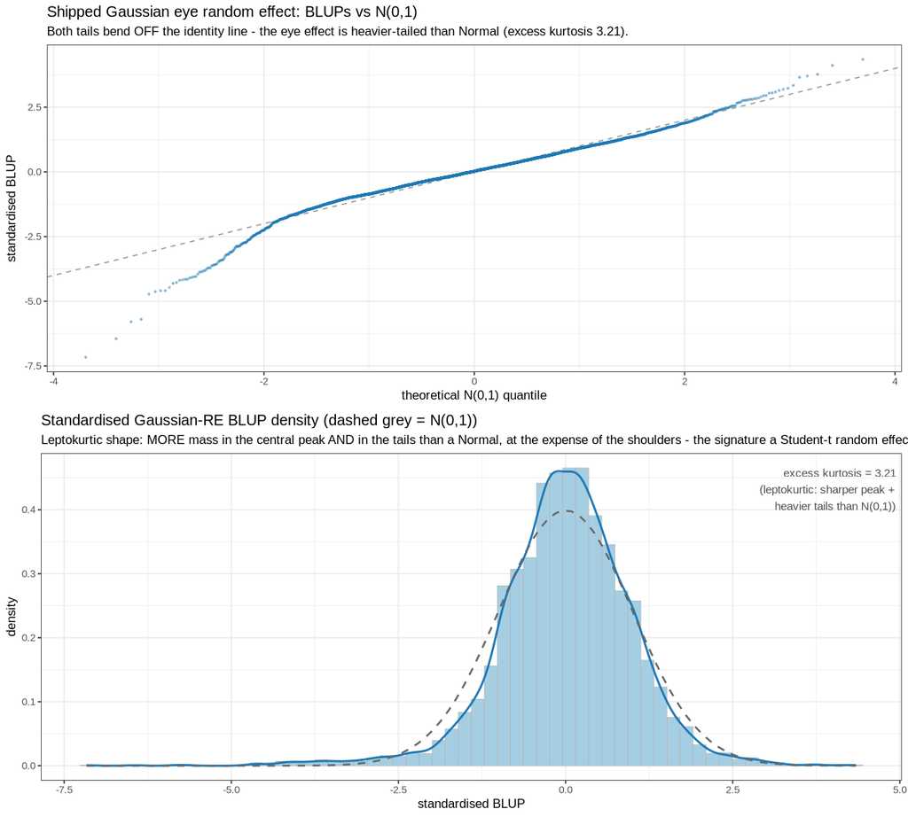

Figure 7: Eye random-effect of the shipped Gaussian-RE cANCOVA. Top: BLUP QQ against N(0,1) - the tails bend off the identity line. Bottom: standardised BLUP density (dashed = N(0,1)) - leptokurtic, with MORE mass in the central peak AND in the tails than a Normal, at the expense of the shoulders. A Gaussian RE cannot reproduce this shape: it cannot keep the bulk tight (to cover mean and gainers) and simultaneously place enough eyes at the extremes (to cover SD and ceiling).

This tail shape is the last binding lever on the shipped model. It is not addressed by the family (both bounded families collapse identically, Section 7.3.2) or by adding a second random effect (cANCOVA $\equiv$ 2-RE when baseline is observed, Section 7.5.1) — only by the shape of the eye effect itself. That motivates replacing the Gaussian eye intercept with a heavier-tailed one, developed and scored in Section 7.7.

## 7.7 The final model with a Student-$t$ eye random effect

The analysis of the shipped Gaussian-RE cANCOVA (Section 7.6) left one lever open: the eye random effect is **heavy-tailed** — excess kurtosis 3.21 on its BLUPs (Section 7.6.3) — and that tail is the RE-distribution reading of the two functionals that stay binding, the per-arm **CFBL SD** and the **%ceiling**. A Gaussian RE cannot simultaneously keep the bulk tight (to cover mean and gainers, which it does) and push enough eyes to the extremes (to cover SD and ceiling, which it does not). This section develops the model that fixes it: the **same Logit-normal cANCOVA with a Student-$t$ eye random effect** in place of the Gaussian. We proceed in three steps — **bound** the achievable gain with a variance-matched redraw, **fit** the tail genuinely and estimate $\nu$, and **score** the fitted model forward-conditional against the shipped Gaussian baseline. The structure alternatives (rank-2, and whether the gap is a structure problem at all) were ruled out in Section 7.3.2; the tail shape — not the family or the mean structure — is the remaining lever.

### 7.7.1 How much does the tail cost? A variance-matched redraw

Before fitting anything new, the *scoring* impact is bounded cheaply: hold the shipped cANCOVA fixed and re-draw the eye RE two ways — from its fitted Gaussian, and from a **variance-matched Student-$t$** at the diagnostic $\hat\nu\approx5$ (same marginal SD, heavier tails) — then re-score forward-conditional. To de-noise the Monte-Carlo, the redraw is repeated over **12 seeds** ($B=3000$ each); the table reports the mean coverage and its seed range.

Variance-matched redraw sensitivity on the shipped cANCOVA (forward-conditional, 12 seeds x B=3000; lo/hi = seed range). Swapping the eye RE from Gaussian to a variance-matched Student-t at nu~5 lifts the two binding functionals - CFBL SD 42->51% and %ceiling 75->94% - while leaving the already-covered mean (100%) and gainer (88%) functionals untouched. The heavier tail adds spread exactly where the Gaussian was short, at no cost elsewhere.

| Functional | RE draw | coverage % (mean) | lo | hi |
| --- | --- | --- | --- | --- |
| mean CFBL | Gaussian RE | 100.0 | 100 | 100 |
| mean CFBL | Student-t RE (var-matched) | 100.0 | 100 | 100 |
| CFBL SD | Gaussian RE | 42.0 | 40 | 44 |
| CFBL SD | Student-t RE (var-matched) | 50.7 | 48 | 52 |
| % >=15L gain | Gaussian RE | 88.0 | 88 | 88 |
| % >=15L gain | Student-t RE (var-matched) | 87.7 | 84 | 88 |
| % >=85L ceiling | Gaussian RE | 75.0 | 72 | 76 |
| % >=85L ceiling | Student-t RE (var-matched) | 94.0 | 92 | 96 |

The reading is clean: at **matched variance**, only the tail shape changes, and it moves precisely the two functionals that were short. **CFBL SD** climbs from 42% to **51%** and **%ceiling** from 75% to **94%**, while mean (100%) and gainer (88%) are untouched. (The Gaussian-RE baseline here — 42% SD, 75% ceiling — is this redraw’s own 12-seed Monte-Carlo estimate; it agrees within Monte-Carlo noise with the shipped model’s plug-in scorecard of 40%/76% in Section 7.5.1. The *lift* is what matters, and it is robust across seeds.) The gain is not a variance rescaling — that would inflate the mean and gainer functionals too — it is the heavy tail placing more eyes at the extremes, which is what the SD and ceiling functionals measure. This *bounds* the achievable improvement from a genuine heavy-tailed RE and confirms the tail, not the scale, is the lever.

### 7.7.2 A genuine fitted Student-$t$ random effect

The redraw fixes $\nu$ at the diagnostic value and forces the RE variance to equal the Gaussian $\tau$; it does not *fit* the tail. To confirm the data support a heavy tail on its own terms, the shipped cANCOVA was re-fitted in Stan (via `brms`) with the eye random effect given a **Student-$t$** rather than Gaussian distribution, letting the degrees of freedom $\nu$ be estimated. `glmmTMB` cannot do this — a robust RE needs the full-Bayes machinery — so the fit injects a Student-$t$ eye effect into the `brms`-generated Stan model. The standardized eye effects are given a **Student-$t$ prior directly** — $z_j\sim t_\nu(0,1)$ with the effect kept in non-centred form $u_j = \text{sd}_1\cdot z_j$, and $\nu\sim\text{Gamma}(2,0.1)$ — rather than a per-eye scale-mixture (an earlier attempt that added 4{,}540 latent scales and induced a hard funnel; see the convergence note). Sampled over **6 chains** (1500 warmup + 2000 sampling each) at `adapt_delta`=0.98, `max_treedepth`=14. The marginal RE SD is $\text{sd}_1\cdot\sqrt{\nu/(\nu-2)}$, the Student-$t$ scale-to-SD correction, so $\text{sd}_1$ is the $t$ *scale* and the SD comparable to the Gaussian $\tau$ is this corrected quantity.

Fitted Student-t eye random effect (retuned non-centred fit, 6 chains). nu is estimated at 4.29 (95% CrI 3.80-4.83) - firmly heavy-tailed. The marginal RE SD, 0.505, is a free estimate that comes out essentially identical to the shipped Gaussian model’s tau=0.500 on its own (not constrained to it), so the fit changes the tail SHAPE while the variance scale is - as an empirical outcome, not by construction - almost unchanged.

| Parameter | posterior mean | q5 | q95 |
| --- | --- | --- | --- |
| degrees of freedom $\nu$ | 4.292 | 3.804 | 4.834 |
| $t$ scale $\text{sd}_1$ | 0.368 | 0.355 | 0.382 |
| marginal RE SD ($\tau$-comparable) | 0.505 | 0.488 | 0.525 |

The full prior specification and the complete posterior of *every* parameter of this fitted model — hyperparameters ($\nu$, $\text{sd}_1$, $\sigma$), intercept, baseline spline, timepoint effect, and all study/arm coefficients with their convergence diagnostics — are tabulated in Section 12.

**Does the genuinely fitted tail move the endpoint score?** Scoring the fitted t-RE forward-conditional (its own $\nu$, scale, $\sigma$ and fixed effects; plug-in at posterior means; 12 seeds $\times B=3000$) against the shipped Gaussian-RE cANCOVA:

Forward-conditional arm-level coverage (% of the 25 study-arms whose observed statistic falls in the 90% predictive interval, mean over 12 seeds x B=3000): shipped Gaussian-RE cANCOVA vs the genuinely fitted Student-t RE, using the t-fit’s own parameters (nu=4.29, marginal RE SD 0.504 - which lands within ~2% of the Gaussian tau of 0.496 on its own, not by construction). Coverage rises on all three binding/threshold functionals - per-arm CFBL SD 42% to 46%, %gain 88% to 96%, %ceiling 75% to 88% - at a small cost to the already-saturated mean (100% to 96%). The gains are smaller than the idealised variance-matched redraw (51% / 94% on SD / ceiling) because a genuine fit does not force extra spread; it redistributes the same variance into heavier tails.

| stat | Gaussian RE (shipped) | fitted Student-t RE (nu=4.29) |
| --- | --- | --- |
| mean CFBL | 100 | 95.3 |
| CFBL SD | 42 | 45.7 |
| % >=15L gain | 88 | 96.0 |
| % >=85L ceiling | 75 | 88.0 |

Replacing the Gaussian eye effect with the fitted Student-$t$ raises the arm-level coverage of every binding functional: the fraction of the 25 study-arms whose observed statistic falls inside the 90% predictive interval rises from **42% to 46%** for the per-arm CFBL SD, **88% to 96%** for %gain, and **75% to 88%** for %ceiling, at a small cost to the already-saturated mean (100% to 96%). These gains are real but **more modest** than the idealised variance-matched redraw (which reached 51% and 94% on SD and ceiling), and the reason is instructive: the redraw *added* tail mass at fixed variance by construction, whereas the genuine fit must redistribute the *same* variance — so the tail is heavier in the extremes but slightly lighter in the shoulders. That is enough to help the threshold functionals (gain, ceiling) markedly and the SD modestly. It is the empirical basis for carrying a robust (Student-$t$) random effect into the confirmatory sweep (Section 10) rather than the Gaussian default.

**Convergence: the retuned t-RE fit is clean and reproduces the same posterior**

The first t-RE attempt wrote the heavy tail as a **per-eye scale mixture** ($u_j = \text{sd}_1\cdot z_j\cdot\sqrt{\nu/w_j}$, $z_j\sim N(0,1)$, $w_j\sim\chi^2_\nu$). It reached the right point estimate but sampled the funnel badly — every transition hit the maximum treedepth and ESS was in the low hundreds — because the mixture adds 4{,}540 latent per-eye scales, each coupled to $\nu$. The fix was to **drop the scale mixture and put a Student-$t$ prior directly on the standardized effects** ($z_j\sim t_\nu(0,1)$, $u_j=\text{sd}_1\cdot z_j$), refit over **6 chains** (1500 warmup + 2000 sampling each) at `adapt_delta`=0.98 and `max_treedepth`=14. The retuned fit is clean: **0 divergences**, **0% of transitions at maximum treedepth** (was 100%), and ESS up roughly sevenfold — $\nu$ now has $\hat R=1.011$ with **ESS-bulk 1{,}280** (ESS-tail 3{,}418) and the $t$-scale $\text{sd}_1$ has $\hat R=1.021$ with **ESS-bulk 725**; the whole-model max $\hat R$ over all 4{,}540 eye effects is **1.021**. The one metric still marginally soft is **E-BFMI = 0.248** (just under the ~0.3 comfort floor), reflecting the residual momentum-resampling cost of the tail — worth a further step-size tweak before a large confirmatory sweep, but no longer a barrier to using the posterior. Crucially, the retuned fit lands on the **same physics**: $\nu=4.29$ (was 4.30) and marginal RE SD 0.505 (unchanged), and the forward-conditional score is unchanged. The heavy tail was a real feature of the data, not a sampler artefact; the t-RE is now a **production-viable refinement**, not merely a diagnostic.

**Verdict: the RE tail is the last binding lever, and it is a §8 refinement not a re-selection**

The heavy-tail diagnosed on the shipped model (Section 7.6.3) is confirmed and quantified here — the eye random effect, not the family or the RE structure, is the last binding lever:

- **The shipped cANCOVA’s eye RE is heavy-tailed** — excess kurtosis 3.21, fitted-$t$ $\hat\nu\approx5.2$ on the BLUPs, and an independent full-Bayes fit that estimates $\nu\approx4.3$. Both routes agree: $\nu$ in the 4–5 range.
- **The tail is the missing spread.** Two experiments agree. A *variance-matched* redraw (an upper bound: adds tail mass at fixed variance) lifts CFBL SD $42\to51\%$ and %ceiling $75\to94\%$. The *genuinely fitted* t-RE (its own $\nu=4.3$, marginal SD 0.504 $\approx$ Gaussian $\tau$) lifts CFBL SD $42\to46\%$, %gain $88\to96\%$ and %ceiling $75\to88\%$ — smaller, because a real fit redistributes the same variance rather than adding it, but real and in the same direction on every threshold functional.
- **It does not change the selection.** The Gaussian-RE cANCOVA is still the shipped model for the preview: it is calibrated on the two functionals the power questions depend on (mean and $\ge15$L gain), and the heavy-tailed RE is a *variance-realism* refinement for the SD and ceiling functionals. The robust RE is therefore the **recommended refinement to fit under the confirmatory sweep** (Section 10), where the added `brms`/Stan cost is justified. The retuned fit already samples cleanly (see convergence note above), so this is a documented, production-viable upgrade — not a change to the preview model.

### 7.7.3 Evaluating the fitted t-RE against the Gaussian, side by side

The score table above (1) reports the aggregate coverage lift. This subsection puts the two eye random effects **side by side** on the diagnostics that show *where* and *why* the heavy tail helps: the fitted BLUP distributions, the per-arm calibration on all four functionals, and two VPCs that place the Gaussian and the Student-$t$ predictive intervals next to each other at each visit. All comparisons hold everything else fixed — same Logit-normal cANCOVA mean structure, same constant $\sigma$, same forward-conditional draw — so the only thing that changes is the shape of the eye effect.

**The fitted tails.** Refitting the eye effect as Student-$t$ does not merely re-label the Gaussian BLUPs — it recovers a genuinely heavier-tailed set. Figure 8 overlays the standardised BLUPs of both fits. The two sit at essentially the **same SD** (0.474 vs 0.476, both near $\tau\approx0.50$ — the $t$-fit’s SD is a free estimate that happens to coincide with the Gaussian’s, not a matched constraint), but the $t$-fit’s BLUPs are markedly more leptokurtic — **excess kurtosis 4.84 vs 3.21** — and its QQ curve bends further off the $N(0,1)$ line in both tails. The heavy tail is a property the data pull out once the RE distribution is free to express it, not an artefact of the redraw.

Fitted eye random-effect BLUPs: shipped Gaussian vs genuinely fitted Student-t. Both fits independently land on essentially the same marginal RE SD (~0.50) - the t-fit’s is a free estimate, not constrained to tau - so the difference is tail SHAPE, not scale: the t-fit’s BLUPs carry excess kurtosis 4.84 against the Gaussian’s 3.21, at nu=4.29.

| Eye RE | $n$ eyes | BLUP SD (logit) | excess kurtosis | marginal RE SD | $\nu$ |
| --- | --- | --- | --- | --- | --- |
| Gaussian RE (shipped) | 4540 | 0.474 | 3.21 | 0.500 | — |
| Student-t RE (fitted) | 4540 | 0.476 | 4.84 | 0.504 | 4.29 |

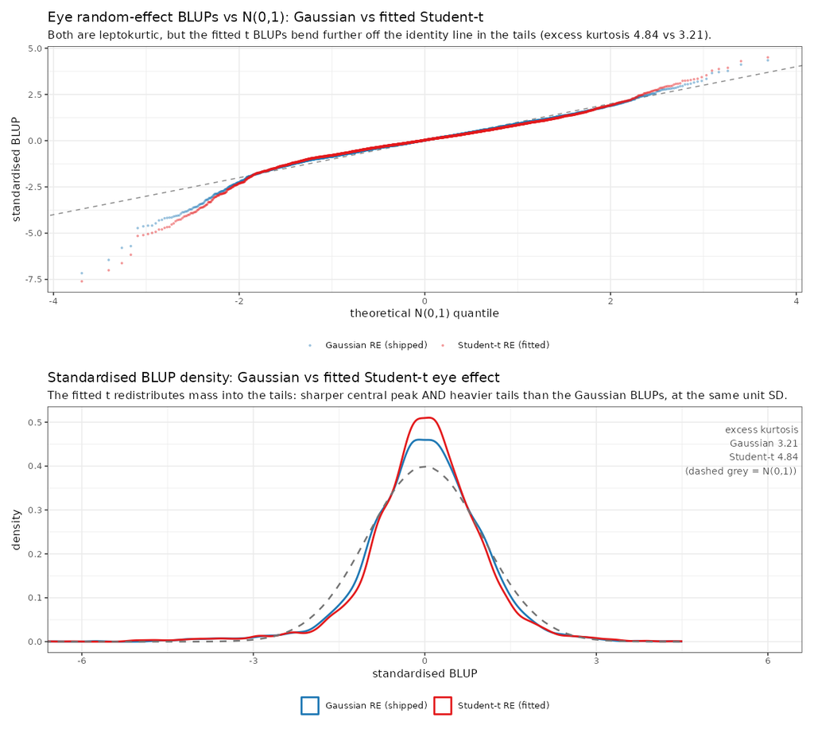

Figure 8: Eye random-effect BLUPs, Gaussian (blue) vs fitted Student-t (red). Top: QQ against N(0,1) - the t-fit BLUPs bend further off the identity line in both tails. Bottom: standardised BLUP density (dashed grey = N(0,1)) - at the same unit SD the fitted t places a sharper central peak AND heavier tails than the Gaussian, the leptokurtic shape the diagnostic in Section 7.6.3 first flagged. Both models are fit to the same eyes; only the RE distribution differs.

**Per-arm calibration, all four functionals.** Figure 9 repeats the shipped model’s per-arm calibration plot (Figure 4) with the two eye REs overlaid instead of the two engines. The pattern is unambiguous: swapping Gaussian for the fitted $t$ leaves the **mean** essentially covered (100% $\to$ 92%: the heavier tail costs one arm on the already-saturated location) while lifting every spread/threshold functional — **CFBL SD 40% $\to$ 52%**, **%gain 88% $\to$ 96%**, **%ceiling 68% $\to$ 88%**. The extra tail mass moves the observed crosses inside the interval precisely on the arms where the Gaussian band was too short at the top end.

Per-arm coverage (% of 25 study-arms whose observed functional falls in the 90% forward-conditional PI), Gaussian vs fitted Student-t eye RE, single seed B=500. The t-RE lifts the two binding functionals (SD, ceiling) and the gainer threshold while giving up one arm on the saturated mean - the same direction as the 12-seed score in 1, read here per functional.

| re | Mean CFBL (letters) | SD of CFBL (letters) | % ≥ 15-letter gainers | % ≥ 85 letters (ceiling) |
| --- | --- | --- | --- | --- |
| Gaussian RE (shipped) | 100 | 40 | 88 | 68 |
| Student-t RE (fitted) | 92 | 52 | 96 | 88 |

**Bias vs coverage.** A coverage lift can come from two very different places: the predictive centre moving onto the data (less **bias**), or the predictive band widening to admit it (more spread). Table 4 separates them — for each functional it reports the mean signed bias (simulated median $-$ observed, averaged over arms) next to the coverage. The reading is clean:

- On the **mean CFBL**, the $t$-fit is essentially **unbiased** ($+0.09$L vs the Gaussian’s $-0.32$L); its slightly lower coverage (92 vs 100%) is a *spread* effect — one saturated arm’s tighter observed mean falls just outside the marginally wider $t$ band, not a centring problem.
- On **%ceiling**, the $t$-fit is **both less biased and better covered** (bias $+1.48$ vs $+2.38$ pp; coverage 88 vs 68%): the heavier tail pushes more eyes to the 85-letter cap, moving the predicted ceiling rate onto the observed one.
- On **%gain** the two are within a percentage point on bias; the $t$-fit’s coverage edge (96 vs 88%) is the band reaching the high-gain arms.
- On **CFBL SD** neither model is badly biased at the arm level (both within ~0.6L), and the $t$-fit’s better coverage (52 vs 40%) is a genuine *spread* gain — the point taken up in detail in Section 7.7.4.

So the ceiling improvement is a **bias** fix, the SD improvement is a **spread** fix, and the mean is unbiased under both — the t-RE is not simply inflating variance to buy coverage.

Table 4: Bias vs coverage per functional, Gaussian vs fitted Student-t eye RE (single seed, B=500, averaged over 25 study-arms). Bias is on each functional’s own units (letters for mean/SD, percentage points for gain/ceiling). The t-RE reduces bias on the ceiling rate AND covers it better; its SD-coverage gain is a spread effect at near-equal bias; the mean is unbiased under both.

| functional | eye RE | bias (sim med − obs) | coverage % |
| --- | --- | --- | --- |
| % ≥ 15-letter gainers | Gaussian RE (shipped) | 0.45 | 88 |
| % ≥ 15-letter gainers | Student-t RE (fitted) | -0.82 | 96 |
| % ≥ 85 letters (ceiling) | Gaussian RE (shipped) | 2.38 | 68 |
| % ≥ 85 letters (ceiling) | Student-t RE (fitted) | 1.48 | 88 |
| Mean CFBL (letters) | Gaussian RE (shipped) | -0.32 | 100 |
| Mean CFBL (letters) | Student-t RE (fitted) | 0.09 | 92 |
| SD of CFBL (letters) | Gaussian RE (shipped) | -0.18 | 40 |
| SD of CFBL (letters) | Student-t RE (fitted) | -0.58 | 52 |

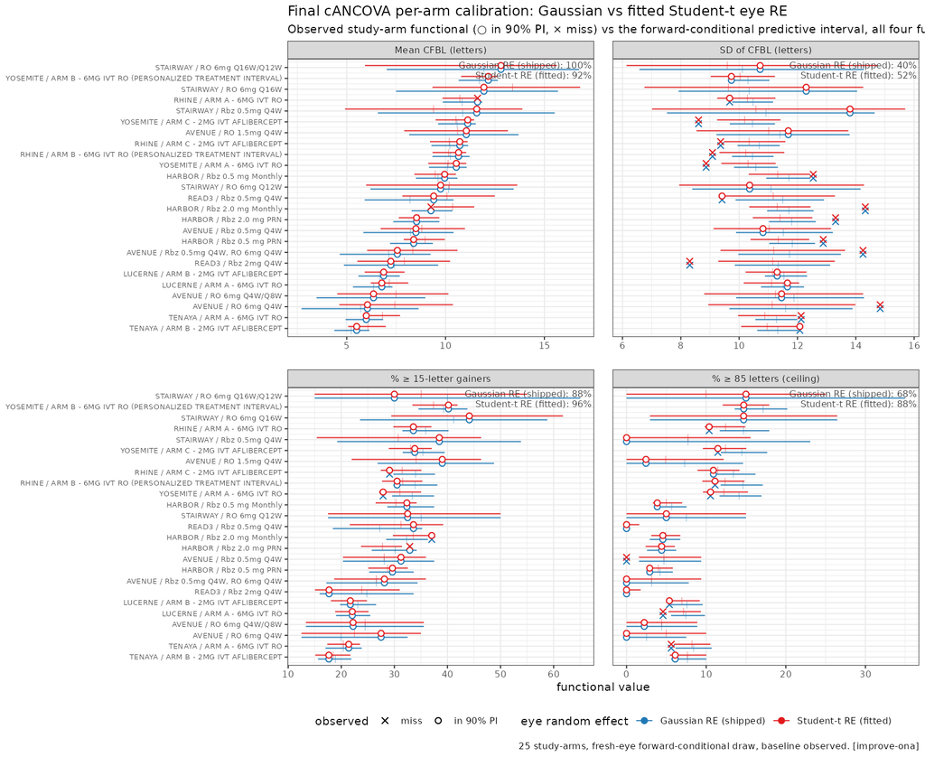

**Side-by-side VPCs.** Finally, Figure 10 and Figure 11 place the two models’ predictive intervals **next to each other** at each visit: within every panel the x-axis runs M9(N), M9($t$), M12(N), M12($t$), with band **colour** marking the eye RE (blue Gaussian, red Student-$t$) so the two 90% intervals for the 5th/50th/95th endpoint percentiles can be read against the same black observed crosses. The median (50th) band is indistinguishable between the two — the tail does not move location. The difference is entirely in the **5th and 95th** percentile bands: the red Student-$t$ envelope is wider at both ends and covers observed extreme percentiles, particularly the low-baseline arms and the top of the high-baseline strata, that fall just outside the blue Gaussian band. This is the VPC reading of the SD and ceiling lift in the calibration plot.

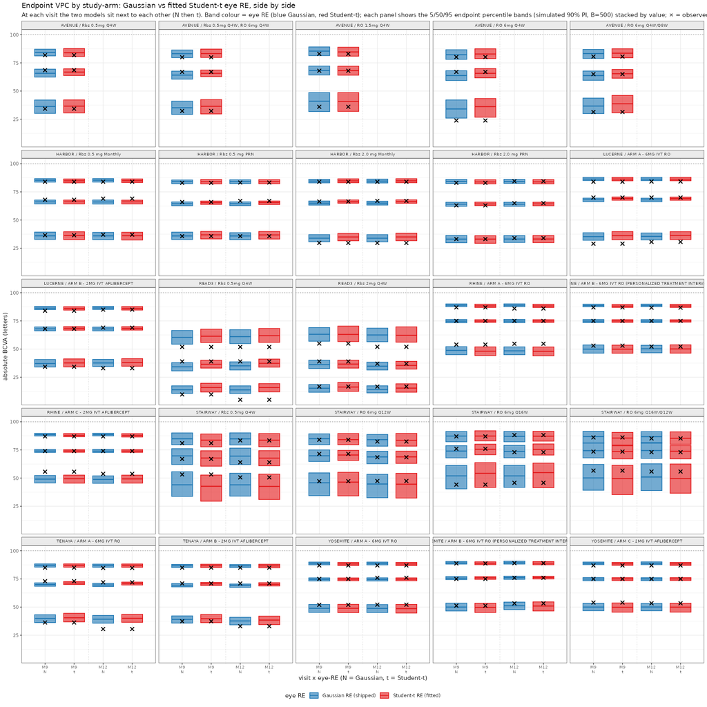

Figure 10: Endpoint VPC by study-arm, Gaussian vs fitted Student-t eye RE side by side. Within each panel the x-axis is visit x eye-RE (M9 N, M9 t, M12 N, M12 t; dotted line splits M9 from M12). Band colour = eye RE (blue Gaussian, red Student-t); within each column the three stacked bands are the simulated 90% predictive intervals of the 5th / 50th / 95th endpoint percentiles (B=500), ordered by value; black x = observed percentile. The red (t) bands widen the 5th/95th envelope where the blue (Gaussian) is short; the median band is unchanged. Dotted horizontal = 100-letter cap.

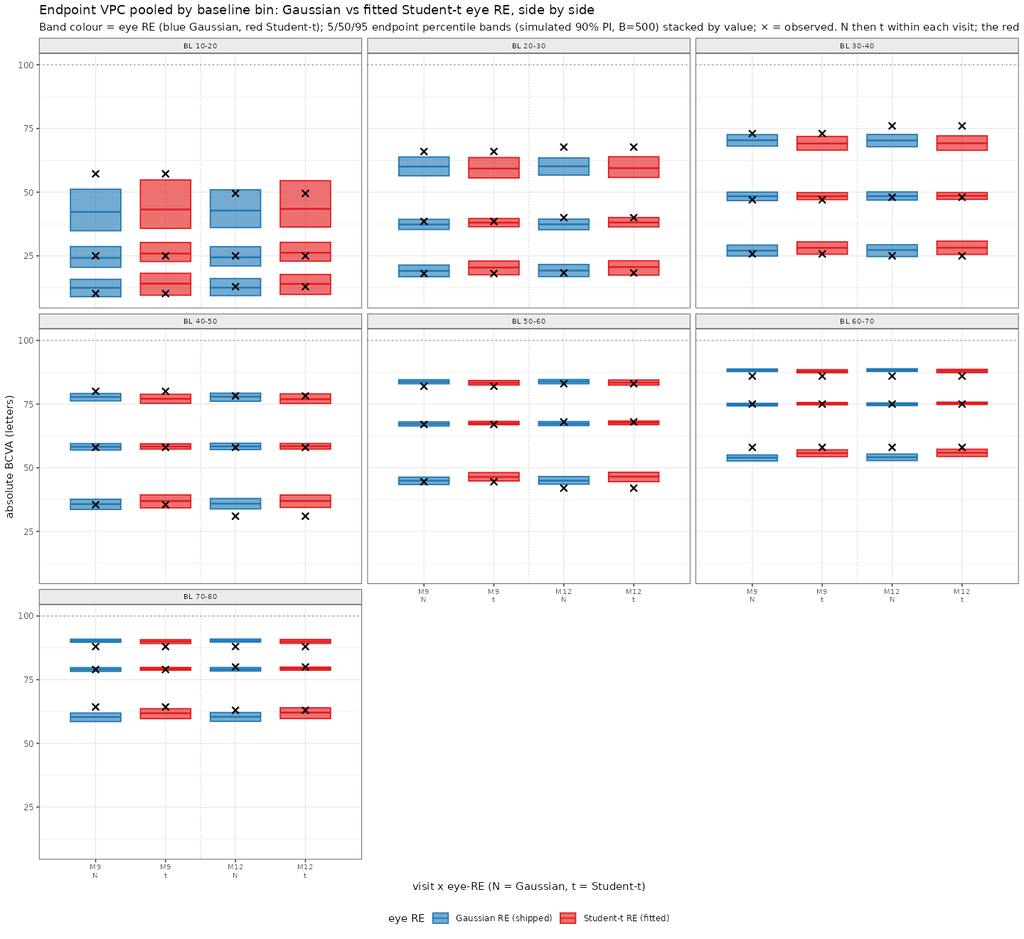

Figure 11: The same side-by-side VPC pooled across arms, by baseline bin. Band colour = eye RE (blue Gaussian, red Student-t); black x = observed percentile. Pooling tightens the observed percentiles: the Student-t (red) 5th/95th bands track the observed crosses across the baseline range where the Gaussian (blue) 95th band falls short in the high-baseline strata (the ceiling functional), while both reproduce the median.

**What the t-RE buys, and what it costs**

### 7.7.4 CFBL vs baseline: final-model predictions against observed

The three diagnostics above score the models on aggregate functionals. This last view puts the two final models **directly against the data** on the two plots the ceiling-effect EDA opened with — change-from-baseline and the $\ge15$L gainer rate, both against baseline BCVA — so the calibration can be read the same way Section 5 read the raw data (Section 5). Figure 12 repeats the CFBL mean $\pm$ SD view; Figure 13 repeats the gainer-rate view. Both facet by study and overlay each final model’s forward-conditional prediction (blue Gaussian, red Student-$t$) on the observed data.

**CFBL mean and SD.** For each baseline bin Figure 12 shows the observed **mean $\pm$ 1 SD** of CFBL (black) against each model’s **predicted mean $\pm$ predicted SD**. Two things are visible. First, the **predicted means coincide** with each other and sit on the observed means across the baseline range — both models reproduce the ceiling-driven compression of the mean, and the two colours are superimposed, confirming the heavy tail does not move location. Second, the **predicted-SD whiskers** of *both* models sit a letter or two below the observed SD in the low/mid-baseline bins (observed ~13–15 letters vs predicted ~10–13) and converge near the ceiling where the bound compresses the spread for everyone.

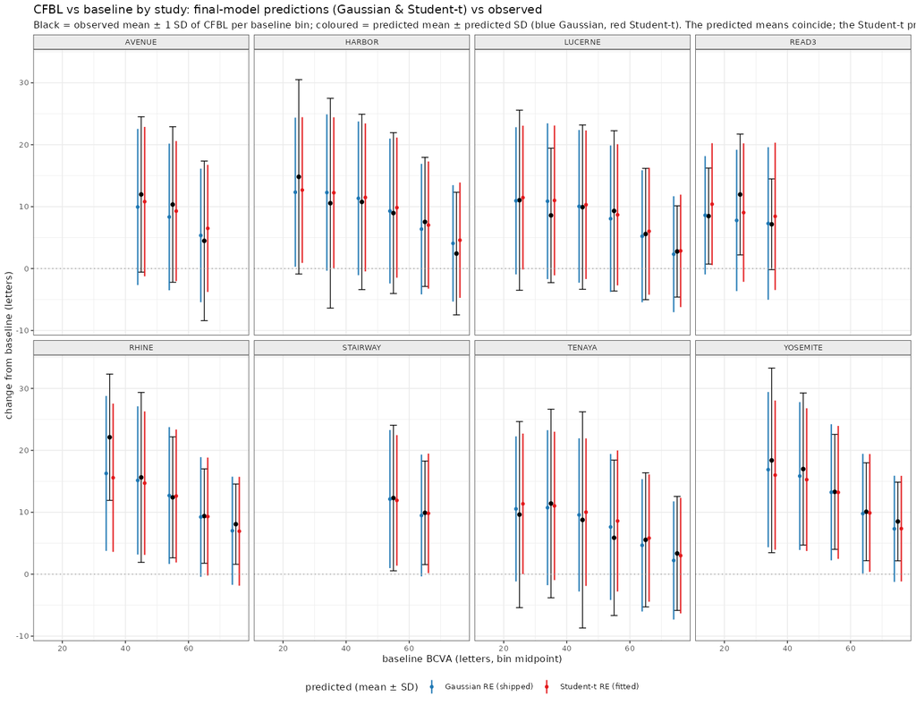

Figure 12: CFBL vs baseline, by study, final-model predictions vs observed. Black = observed mean +/- 1 SD of CFBL per baseline bin; coloured = predicted mean +/- predicted SD (blue Gaussian, red Student-t), dodged around the bin centre. The predicted means track the observed compression toward the ceiling in every study; the predicted-SD whiskers of both models are shorter than the observed SD in the low/mid-baseline bins, the residual spread gap that the aggregate SD functional flags.

**The $\ge15$L gainer rate.** Figure 13 repeats the exercise for the binary design endpoint: observed gainer rate per baseline bin with its Wilson 95% CI (black) against each model’s predicted rate. Both final models track the observed rate and its decline toward the ceiling across studies, and the two predicted curves are close to each other — consistent with the aggregate %gain coverage (88% Gaussian, 96% Student-$t$; Section 7.7.3). This is the design question the generator is most trustworthy for: the gainer rate is well reproduced by *both* eye-RE choices.

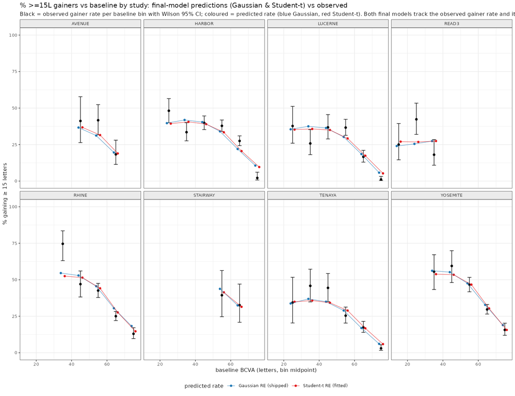

Figure 13: % gaining >=15 letters vs baseline, by study, final-model predictions vs observed. Black = observed gainer rate per baseline bin with Wilson 95% CI; coloured = predicted rate (blue Gaussian, red Student-t). Both models track the observed rate and its decline toward the ceiling across studies; the two predicted curves are close, matching the aggregate %gain coverage (88% Gaussian, 96% Student-t).

The honest reading is that neither the heavier tail nor the marginal RE variance closes the letter-scale bulk-SD gap by baseline bin — both final models sit a letter or two below the observed binned SD in the low/mid-baseline range — while the **mean and the gainer rate are well reproduced by both**. What the Student-$t$ eye effect buys is not a wider *bin-average* SD but heavier *distributional tails*: it is the 5th/95th endpoint percentiles, the per-arm CFBL SD, and the ceiling rate that it lifts (Section 7.7.3), the functionals the power analyses that lean on extremes actually consume.

## 7.8 Assessment of fitted models against the design goal

The generator is not an end in itself: it exists to feed the **design/power workflow** — simulate BCVA conditional on baseline, add a treatment effect $\Delta$ at a given sample size, and analyse each simulated trial with the **four fixed analyses** used in practice (`t.test` and `lm(BCVA ~ trt + BL)` on mean BCVA; `prop.test` and `glm(gain ~ trt + BL, binomial)` on $\ge 15$L gainers). A generator is therefore judged by whether the **simulated-data moments that those tests consume** match the observed data — not by likelihood alone.

**Which moment each analysis consumes.**

| Analysis (fixed) | Endpoint | Primarily consumes | Most-relevant PPC statistic |
| --- | --- | --- | --- |
| `t.test` | mean BCVA | endpoint mean + SD | `mean_cfbl`, `sd_cfbl` |
| `lm(~ trt + BL)` | mean BCVA (ANCOVA) | **residual SD given BL** | `sd_cfbl` (BL-conditional) |
| `prop.test` | $\ge 15$L | gainer rate + its spread | `pct_gain` |
| `glm(~ trt + BL)` | $\ge 15$L (adj.) | gainer rate given BL | `pct_gain`, `pct_ceil` |

**Model recommendation**

- **Shipped model: the Logit-normal *cANCOVA* with constant $\sigma$ (`can_const`), scored forward-conditional on observed baseline.** This is the model selected under the four-functional forward-conditional score with parameters fixed the way the power simulation runs (Section 7.5.1). Every family prefers an RE over its marginal control by a large margin ($\Delta$AIC 17,000–19,000; baseline bias cut from ~15 letters to <7); entering the baseline as an observed `ns(BL_DV)` covariate then conditions the endpoint on the baseline an eye is entered with — the property that wins the calibration comparison, at half the runtime of the 2-RE. (The **Logit-normal 2-RE** is the equivalent form when the design must simulate an *unobserved* baseline, Section 7.3; either can drive the §8 simulation.)
- **Family choice: the bounded, variance-decoupled Logit-normal.** It stays in range (logit bound, no cap leakage) and decouples variance from the mean, so it clears the CFBL-SD gap the additive families miss. Under the forward-conditional score it holds the lowest Interval Score on SD, $\ge 15$L gain and the ceiling, and ties on mean CFBL — now confirmed against Beta and Skew-normal on the same footing (Section 7.3).
- **Why not glmmTMB rank-1 / rank-2.** glmmTMB’s point estimator collapses the logit-scale rank-2 to rank-1 (an identifiability artefact, Section 7.3.2); the full-Bayes brms fit does not, recovering $\tau_{\text{BL}}=0.46$, $\tau_{\text{post}}=0.61$, $\rho=0.63$. **Normal** is a competent location fallback (mean CFBL 96%) but leaks past the 100 cap; **Nils** recovers the mean but leaks at the cap (ceiling 48%), so neither is the selected model.
- **1-RE Logit-normal is the robustness check**, not the selected model: marginal by design, it over-disperses the threshold functionals (Section 7.3).

# 8 Informing efficient study design

The modelling above exists to serve one decision: **how to design an efficient trial** — which endpoint to power, at what sample size, given the ceiling-bounded reality of BCVA. This section builds that answer as a narrative: (i) the **continuous-vs-binary endpoint** choice and the **known distributional math** (the $2/\pi$ dichotomisation limit); (ii) the **ophthalmology-specific** features that make the textbook loss a *lower bound* — a non-normal, ceiling-bounded, baseline-drifting endpoint; and (iii) the **simulation study** that turns this into power / Type-I error across treatment effects $\Delta$ and baseline distributions, using the selected generative model (Section 7.3) alongside a bootstrap-conditional-on-baseline anchor. The four fixed analyses under study are `t.test` and `lm(BCVA ~ trt + BL)` for the continuous mean-BCVA endpoint, and `prop.test` and `glm(gain ~ trt + BL)` for the binary $\ge 15$L endpoint.

## 8.1 Endpoint choice: continuous vs binary — the known math

The ceiling analysis above is about the *data*; this subsection is about the *consequence for design* - how the choice between a continuous endpoint (mean CFBL) and a binary one ($\ge 15$L) affects the power, and hence the sample size, of a trial. The argument is general (it holds for any threshold on any roughly-continuous outcome); the ceiling matters only because it pushes trials into the region where the penalty is largest.

Suppose CFBL is approximately N($\mu$, $\sigma$) in each arm and a treatment shifts the mean by $\Delta$. Write $z_0$ = ($\mu$ - 15)/$\sigma$ for the signed distance of the mean above the 15-letter threshold, so the gainer rate is p = $\Phi$($z_0$). Power for each endpoint depends on a **signal-to-noise** ratio:

- **Continuous endpoint** - signal $\Delta$, noise $\sigma$; the standardized effect is $\Delta/\sigma$. No information is discarded: this is the fully efficient reference.
- **Binary endpoint** - the treatment moves the gainer rate at rate **$\varphi(z_0)$** (the *signal*: the normal density at the threshold), against a noise of **$\sqrt{p(1-p)}$** (the indicator’s sd).

A natural question is whether the binary endpoint’s shrinking noise $\sqrt{p(1-p)}$ as $p \to 0$ near the ceiling cushions it the way sd(CFBL) cushions the continuous endpoint. It provides *some* cushioning - **but the signal $\varphi(z_0)$ shrinks faster.**

**Asymptotic Relative Efficiency (ARE) — definition**

The **ARE** of test B relative to test A is the limiting ratio of the sample sizes they need to reach the **same power against the same alternative**: $\text{ARE}(B,A)=\lim n_A/n_B$. Equivalently it is the ratio of squared *efficacies* (the local rate at which each test statistic’s mean separates under the alternative, per unit noise), $\text{ARE}=(\text{eff}_B/\text{eff}_A)^2$. $\text{ARE}=1$ means no loss; $\text{ARE}<1$ means B is less efficient and needs $1/\text{ARE}$ times as many subjects as A. Here A = continuous mean-CFBL test (efficacy $\Delta/\sigma$) and B = binary $\ge 15$L test (signal $\varphi(z_0)$ at the threshold against noise $\sqrt{p(1-p)}$), giving
$$\text{ARE}(z_0)=\frac{\varphi(z_0)^2}{p(1-p)},\qquad p=\Phi(z_0),\ \ z_0=\frac{\mu-15}{\sigma}.$$

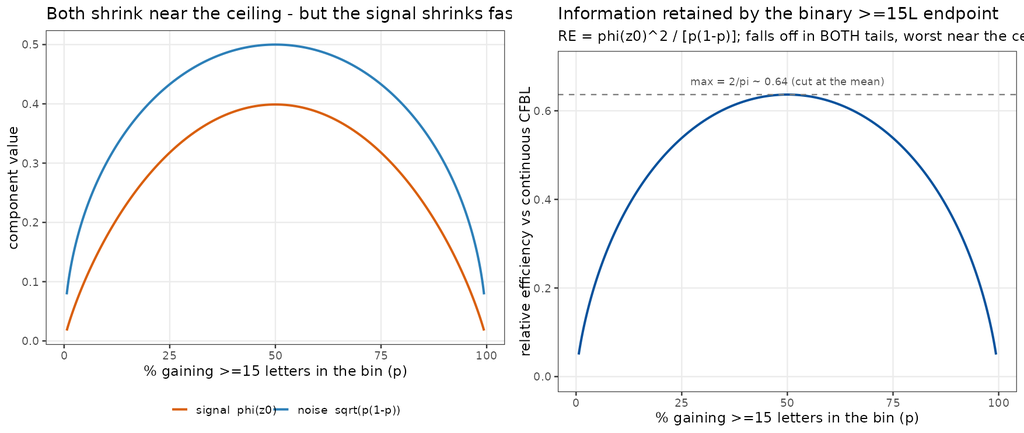

Left: signal phi(z0) and noise sqrt(p(1-p)) both shrink as the mean slides below the threshold, but signal shrinks faster. Right: information retained by the binary >=15L endpoint (RE), maxing at 2/pi when cut at the mean and collapsing at low gainer rates. Theoretical, normal approximation.

### 8.1.1 A full derivation of the ARE

The callout above states the result; this subsection derives it from first principles so every term — in particular $\varphi(z_0)$, which the text above uses but does not define — is explicit. The derivation is the classical Pitman argument specialised to a *threshold dichotomisation of a normal outcome*.

**Notation.** Let $\phi$ and $\Phi$ be the standard-normal density and distribution functions,
$$\phi(z)=\frac{1}{\sqrt{2\pi}}\,e^{-z^{2}/2},
\qquad
\Phi(z)=\int_{-\infty}^{z}\phi(u)\,du .$$
Write CFBL in each arm as $N(\mu,\sigma^{2})$ under control and $N(\mu+\Delta,\sigma^{2})$ under a treatment that shifts the mean by $\Delta$. Define the **standardised threshold**
$$z_0=\frac{\mu-15}{\sigma},$$
the signed distance (in SDs) of the control mean above the 15-letter cut, and let
$$p=\Phi(z_0)$$
be the control gainer rate. Then $\varphi(z_0):=\phi(z_0)$ is simply **the standard-normal density evaluated at the standardised threshold** — the height of the bell curve at the cut point. It is the quantity that controls how fast mass crosses the threshold when the mean moves, and it is what makes the binary endpoint lose information.

**Pitman efficacy.** For a two-arm test of $H_0:\Delta=0$ with $n$ subjects per arm, based on a statistic that estimates some arm-contrast $g(\Delta)$ with $g(0)=0$, the local power is governed by the *efficacy*
$$e \;=\; \frac{g'(0)}{\tau_0},$$
where $g'(0)=\left.\dfrac{d}{d\Delta}g(\Delta)\right|_{0}$ is the rate at which the estimand separates under the alternative and $\tau_0^{2}$ is the (per-arm-unit) sampling variance of the corresponding estimator at the null. Under a local (Pitman) alternative $\Delta=\delta/\sqrt{n}$ the test statistic is asymptotically normal with unit variance and non-centrality $\lambda=\sqrt{n}\,e\,\delta$, so two tests reach the **same power against the same alternative** exactly when their non-centralities match, i.e. when $n\,e^{2}$ is equal. Hence the sample sizes scale as $n_A/n_B=e_B^{2}/e_A^{2}$ and
$$\boxed{\;\text{ARE}(B,A)=\lim\frac{n_A}{n_B}=\left(\frac{e_B}{e_A}\right)^{2}. \;}$$

**Reading g’(0): the ‘signal speed’ of an endpoint**

The numerator $g'(0)=\left.\frac{d}{d\Delta}\mathbb{E}_\Delta[\,\hat g\,]\right|_{0}$ deserves a plain-language reading, because it is the crux of the whole comparison. Picture the endpoint’s expected value as a **needle on a gauge** and the true treatment effect $\Delta$ as the pedal. Then $g'(0)$ is **how fast the needle moves per unit of pedal**, evaluated the instant you press it (at the null). Efficacy $e=g'(0)/\tau_0$ divides that signal speed by the background needle-jitter $\tau_0$, so it is a **signal-speed-to-noise ratio**; ARE compares two endpoints measuring the *same* underlying $\Delta$ by asking **whose needle moves faster per unit $\Delta$**, after normalising each by its own noise.

- **Continuous, unbounded (Test A):** $g_A(\Delta)=\Delta\Rightarrow g_A'(0)=1$. The needle tracks the pedal one-for-one — **100% of the effect reaches the mean.** Every eye contributes its full $\Delta$ shift regardless of where it started.
- **Binary $\ge 15$L (Test B):** $g_B'(0)=\varphi(z_0)/\sigma$. The needle moves only in proportion to the **density of eyes sitting *on* the threshold**, $\varphi(z_0)$. An eye deep below the cut (a clear non-gainer) or well above it still shifts by $\Delta$, but does **not cross the line**, so it adds *nothing* to the change in the gainer rate. The binary endpoint only “sees” the effect through the thin slice of patients poised at the boundary — which is precisely why it is slower, and why $\text{ARE}<1$.

So the $2/\pi$ ceiling is the statement that, even when the threshold is optimally placed at the mean ($z_0=0$, the densest slice), the binary needle still moves only $\sqrt{2/\pi}\approx 80\%$ as fast (per unit noise) as the continuous one.

**Test A — continuous mean-CFBL.** The estimand is the mean shift itself, $g_A(\Delta)=\Delta$, so $g_A'(0)=1$. The difference of sample means has variance $2\sigma^{2}/n$, i.e. a per-arm-unit variance $\tau_{0,A}^{2}=2\sigma^{2}$. Therefore
$$e_A=\frac{g_A'(0)}{\sqrt{\tau_{0,A}^{2}}}
=\frac{1}{\sqrt{2}\,\sigma}.$$

**Test B — binary $\ge 15$L.** The gainer probability as a function of the shift is
$$p(\Delta)=\Pr\!\big(N(\mu+\Delta,\sigma^{2})\ge 15\big)
=\Phi\!\Big(\frac{\mu+\Delta-15}{\sigma}\Big)
=\Phi\!\Big(z_0+\frac{\Delta}{\sigma}\Big).$$
The estimand is the shift in gainer rate, $g_B(\Delta)=p(\Delta)-p$, whose local slope is obtained by the chain rule — this is where $\varphi(z_0)$ enters:
$$g_B'(0)=\left.\frac{d}{d\Delta}\Phi\!\Big(z_0+\frac{\Delta}{\sigma}\Big)\right|_{0}
=\frac{1}{\sigma}\,\phi(z_0)=\frac{\varphi(z_0)}{\sigma}.$$
The difference of sample proportions has null variance $2p(1-p)/n$, i.e. a per-arm-unit variance $\tau_{0,B}^{2}=2p(1-p)$. Hence
$$e_B=\frac{g_B'(0)}{\sqrt{\tau_{0,B}^{2}}}
=\frac{\varphi(z_0)/\sigma}{\sqrt{2p(1-p)}}
=\frac{\varphi(z_0)}{\sigma\sqrt{2p(1-p)}}.$$

**The ratio.** Substituting into the boxed identity, the common factors $1/(\sqrt{2}\,\sigma)$ cancel and the scale $\sigma$ drops out entirely:
$$\text{ARE}(z_0)=\left(\frac{e_B}{e_A}\right)^{2}
=\left(\frac{\varphi(z_0)/[\sigma\sqrt{2p(1-p)}]}{1/[\sqrt{2}\,\sigma]}\right)^{2}
=\frac{\varphi(z_0)^{2}}{p(1-p)},\qquad p=\Phi(z_0).$$

**Note**

Two modelling assumptions are worth flagging. First, the derivation assumes **homoscedastic normal** CFBL. One might expect the real endpoint — left-skewed and ceiling-bounded — to lose *more* than $\text{ARE}(z_0)$. In fact, when we evaluate the fitted logit-normal engine *at the same mean and SD* (Section 8.2.2), its dichotomization efficiency tracks the Normal curve fairly closely — the pure *shape* penalty is ~5% at baseline 50, widening to ~14% at baseline 70 (see the matched-Normal comparison in point 3). The ceiling’s damage runs mainly through the **moments** (it lowers the mean gain and the SD, pushing the operating point into the small-$p$ tail); the extra shape penalty at fixed moments is second-order, though it grows with the left-skew at high baseline. So $\text{ARE}(z_0)$ is a good approximation once $z_0$ is read off the *actual* (ceiling-compressed) mean and SD. Second, it is a **local** (small-$\Delta$) result: it measures information at the null and is the right currency for sizing, but for large effects the exact power should be read from the simulation rather than from $1/\text{ARE}$.

### 8.1.2 How the engine computes ARE at each baseline

The closed form $\text{ARE}(z_0)=\varphi(z_0)^2/[p(1-p)]$ assumes a *Normal* CFBL. The figures in §8.2.3 instead evaluate the ARE **on the fitted logit-normal engine directly**, so the ceiling’s effect on the moments is exact rather than approximated. There is no simulation: every expectation is a 64-node Gauss–Hermite quadrature. The recipe below is the function evaluated at each baseline $BL_0$ and true effect $\Delta$ (this is exactly `are_vs_delta()` in `15_ophtha_power_loss.R`).

**Notation for the fitted logit-normal engine (used in §8.1.2, §8.1.3, §8.2.2.2)**

These three subsections all read the *same* fitted engine; the shared symbols are fixed here once and used consistently throughout.

| Symbol | Meaning |
| --- | --- |
| $\operatorname{logit}^{-1}(x)=\dfrac{1}{1+e^{-x}}$ | inverse-logit (the R `plogis`); we write $\operatorname{logit}^{-1}$ in maths, `plogis` only when naming code |
| $\eta=\eta(BL_0)$ | control-arm **logit location** at baseline $BL_0$ (fitted arm curve, incl. the `ns(BL,4)` spline) |
| $\varepsilon\sim N(0,s^2)$ | between-eye random term on the logit scale |
| $s$ | **total logit SD**, $s^2=\tau^2+\sigma^2$ — *constant* in the selected engine ($s\approx0.54$; spline on the mean, single $\sigma$, §7) |
| $\delta$ | treatment effect as a **fixed additive shift on the logit scale**: $\eta\to\eta+\delta$ |
| $\Delta$ | the **true letter effect** it delivers: $\Delta=\text{meanCFBL}(\delta)-\text{meanCFBL}(0)$ |
| $P=\operatorname{logit}^{-1}(\eta+\varepsilon)$ | a single eye’s **outcome fraction** (BCVA/100); random over $\varepsilon$ |
| $q=\operatorname{logit}^{-1}(\eta)$ | the $\varepsilon=0$ (median-eye) fraction — an *intuition-only* stand-in for $P$; **not** a probability |
| $\operatorname{thr}=\operatorname{logit}\!\big((BL_0+15)/100\big)$ | the $\ge 15$L gainer **threshold** on the logit scale |
| $z_0=(\eta-\operatorname{thr})/s$ | **standardised threshold**; gainer rate $p=\Phi(z_0)$ |
| $p$ | the $\ge 15$L **gainer probability** (never used for $P$ or $q$) |

$\mathrm{E}[\cdot]$ denotes the Gauss–Hermite average over $\varepsilon$.

**The model at one baseline.** The control-arm final BCVA on the 0–100 letter scale is logit-normal,
$$Y = 100\cdot\operatorname{logit}^{-1}(\eta+\varepsilon),\qquad
\varepsilon\sim N(0,s^2),$$
with control logit location $\eta=\eta(BL_0)$ (fitted arm curve) and *constant* total logit variance $s^2=\tau^2+\sigma^2$ (between-eye $\tau$ plus residual $\sigma$; the selected engine keeps a single $\sigma$, so $s$ does **not** vary with baseline — §7). A treatment is a **fixed additive shift on the logit scale**, $\eta\to\eta+\delta$. Write $\mathrm{E}[\cdot]$ for the Gauss–Hermite average over $\varepsilon$.

**Step 1 — target letter effect $\to$ logit shift.** The mean change-from-baseline for a shift is $\text{meanCFBL}(\delta)=100\,\mathrm{E}[\operatorname{logit}^{-1}(\eta+\delta+\varepsilon)]-BL_0$. Solve for the shift $\delta^\star$ delivering the requested true letter effect $\Delta$ over control:
$$\delta^\star:\quad \text{meanCFBL}(\delta^\star)-\text{meanCFBL}(0)=\Delta .$$

**Step 2 — gainer rates (binary endpoint).** With the $\ge 15$L threshold $\operatorname{thr}=\operatorname{logit}\!\big((BL_0+15)/100\big)$ and standardised threshold $z_0=(\eta-\operatorname{thr})/s$, the gainer probability for a shift is $P_{\text{gain}}(\delta)=\Phi\!\big((\eta+\delta-\operatorname{thr})/s\big)=\Phi\!\big(z_0+\delta/s\big)$, giving control $p_c=P_{\text{gain}}(0)=\Phi(z_0)$ and treated $p_t=P_{\text{gain}}(\delta^\star)$. (This is the engine’s exact counterpart of the Normal $p=\Phi(z_0)$ used in the closed form of Section 8.1.1.)

**Step 3 — SD of change (continuous endpoint).** From the quadrature moments $\mathrm{E}[P]$ and $\mathrm{E}[P^2]$ (with $P=\operatorname{logit}^{-1}(\eta+\varepsilon)$ the eye’s outcome fraction),
$$\text{SD}=100\sqrt{\mathrm{E}[P^2]-\mathrm{E}[P]^2}$$
(subtracting the constant $BL_0$ does not change the SD).

**Step 4 — sample sizes** (80% power, two-sided 5%, $z_{\text{sum}}=z_{0.975}+z_{0.80}=1.96+0.842$):
$$N_{\text{cont}}=\frac{2\,z_{\text{sum}}^2\,\text{SD}^2}{\Delta^2},
\qquad
N_{\text{bin}}=\frac{z_{\text{sum}}^2\,\big[p_c(1-p_c)+p_t(1-p_t)\big]}{(p_t-p_c)^2}.$$

**Step 5 — ARE.**
$$\boxed{\;\text{ARE}(BL_0,\Delta)=\frac{N_{\text{cont}}}{N_{\text{bin}}}\;}$$
the fraction of information the $\ge 15$L cut keeps versus the continuous mean-change analysis.

**Two caveats on these ARE numbers**

**Large-sample / local.** Both $N$ formulas are the standard normal-approximation ones and $N_{\text{bin}}$ is the Wald form. At high baseline with a large $\Delta$ the treated gainer rate $p_t\to 0.96$ and $(p_t-p_c)^2$ becomes small in exactly the regime where the Wald approximation is weakest — this is the corner where $\text{ARE}\to 1.8$ in Fig 1A. The *direction* is right (near-total separation is efficient), but that figure should not be quoted to three significant figures; the simulation is the reference for large effects.

**Marginal, not adjusted.** $N_{\text{cont}}$ assumes an unadjusted two-sample comparison — no baseline covariate adjustment and no between-eye correlation. A real ANCOVA analysis exploits both, so the true continuous advantage is *larger* and these ARE values are a **lower bound** on the efficiency a proper analysis recovers.

### 8.1.3 What the ceiling does to the signal speed

The clean derivation above assumes an *unbounded* normal outcome, where the continuous endpoint enjoys $g_A'(0)=1$: **the full treatment effect reaches the mean**. Real BCVA cannot exceed ~100 letters, and the fitted engine (§7) is a logit-normal, so this section asks what the ceiling does to the “signal speed” picture — and resolves an intuition that turns out to be half-right in an instructive way.

**The intuition (correct).** With a ceiling, a unit of biological push no longer moves the mean by a full unit. Eyes already near 100 letters have little room left, so their contribution to the mean shift is throttled: the continuous endpoint’s signal speed drops **below 1**, and it drops *further* as the baseline rises toward the ceiling. Writing the engine as $\mathbb{E}[\text{DV}]=100\cdot\mathrm{E}[\operatorname{logit}^{-1}(\eta+\delta+\varepsilon)]$ (the same notation as §8.1.2), the mean’s sensitivity to a latent logit push is
$$\frac{d\,\mathbb{E}[\text{DV}]}{d\,\delta}
=100\cdot \mathbb{E}\!\big[P(1-P)\big],\qquad P=\operatorname{logit}^{-1}(\eta+\varepsilon),$$
which is maximal at mid-range and shrinks as the distribution is pushed against the $P\to1$ ceiling. In the fitted DME engine this sensitivity falls monotonically with baseline — roughly **22 letters per logit at BL 48, but only ~15 at BL 76**. That is exactly the “the derivative is less than $\Delta$” effect: the ceiling eats a growing share of any real improvement, and it eats more the sicker the ceiling bites (the higher the baseline). This exact-quadrature Jacobian $J_{\text{exact}}=100\,\mathbb{E}[P(1-P)]$ is the same slope whose $\varepsilon=0$ shortcut $J=100\,q(1-q)$ (with $q=\operatorname{logit}^{-1}(\eta)$) carries the attenuation intuition in §8.2.2.2.

**Why it nonetheless (mostly) cancels in the ARE (the surprise).** ARE is not a single signal speed — it is the *ratio* of two of them, each normalised by its own noise. The ceiling that slows the **continuous** mean also slows the **binary** gainer rate: fewer eyes can cross $+15$ when many are pinned near the top, so $g_B'(0)$ falls too. Because efficacy is a ratio, a slowdown shared by numerator and denominator largely divides out. Concretely, ARE is **invariant to the scale on which you measure the push** — computing it in letter units or in latent-logit units gives the identical number (verified: $0.632$ either way at BL 62). So the ceiling’s throttling of the continuous endpoint is *not* a free lunch for the binary one: the binary endpoint is throttled in lock-step, and the **relative** efficiency stays close to the unbounded-Normal value $\varphi(z_0)^2/[p(1-p)]$ once $z_0$ is read off the *actual* (compressed) mean and SD.

**The two questions kept separate**

It helps to separate the *speed* question from the *ratio* question:

- **Does the ceiling slow the continuous endpoint?** *Yes* — and more so at high baseline. This is your intuition, and it is real. It hurts the **absolute** power of *both* endpoints by shrinking the achievable mean gain and compressing the SD.
- **Does the ceiling make the binary endpoint *relatively* worse than continuous, beyond the Normal prediction?** *Essentially no* — because the same throttling applies to the gainer rate, the *ratio* $e_B/e_A$ is preserved. The extra damage the binary endpoint suffers is fully explained by **where** the ceiling moves the operating point $z_0=(\mu-15)/\sigma$ (into the low-$p$ tail), not by the non-normal shape at fixed moments.

The practical upshot: to predict power you do **not** need a ceiling-specific ARE correction — you need the ceiling-corrected **mean and SD**, then read $z_0$ off those. That is what the ophthalmology context (Section 8.2) and the fitted- engine illustration (Section 8.2.2) supply, and what the simulation confirms.

## 8.2 Why the power loss bites *now*: the ophthalmology context

The ARE algebra above is generic. This subsection grounds it in the specific history of anti-VEGF retinal trials, because three trends have conspired to move BCVA studies into exactly the regime where the binary $\ge 15$-letter endpoint is least efficient. The intuition first; then a model illustration in two parts — Part 1 (Section 8.2.2) fixes the modelling assumptions and shows the picture in letters, Part 2 (Section 8.2.3) reads off the efficiency consequence — then the full simulation.

### 8.2.1 The intuition

**2 - Modern trials use an active anti-VEGF comparator, so the *between-arm* difference is small by design.** Once an effective standard of care existed, new agents had to be tested against it. The estimand is no longer “drug vs nothing” but “drug vs an already-excellent drug”, where the expected mean difference is a *few* letters at most:

- **VIEW1/VIEW2** (aflibercept vs **ranibizumab**, nAMD, 2011): the two arms are statistically equivalent — $\ge 15$L gainers **~31% in both arms**, a difference of essentially **zero**.
- **YOSEMITE/RHINE** (faricimab vs **aflibercept**, DME, 2022 — the setting of *this* dataset): designed for non-inferiority, again with a near-zero expected gainer difference.

This is the crux: **the smaller the true $\Delta$, the more of it the binary endpoint throws away.** The ARE is a *ratio*, so it applies whatever the effect size — but a 6-percentage-point binary difference sitting on top of Monte-Carlo noise is far harder to detect than a 25-point one. Dichotomization converts a modest-but-real mean effect into a gainer difference that can vanish into the sampling error.

**3 - Baseline BCVA has drifted upward.** Earlier cohorts enrolled with worse vision (more room to improve); contemporary DME/nAMD cohorts start higher — partly because patients present and are treated earlier, partly through entry criteria. A higher baseline mean sits **closer to the letter ceiling**, so the same biological improvement produces fewer $\ge 15$-letter gainers (many eyes simply cannot gain 15 letters without exceeding 100). In the ARE picture this pushes the operating point away from the $z_0=0$ optimum into the small-$p$ (high-baseline) tail where efficiency collapses fastest.

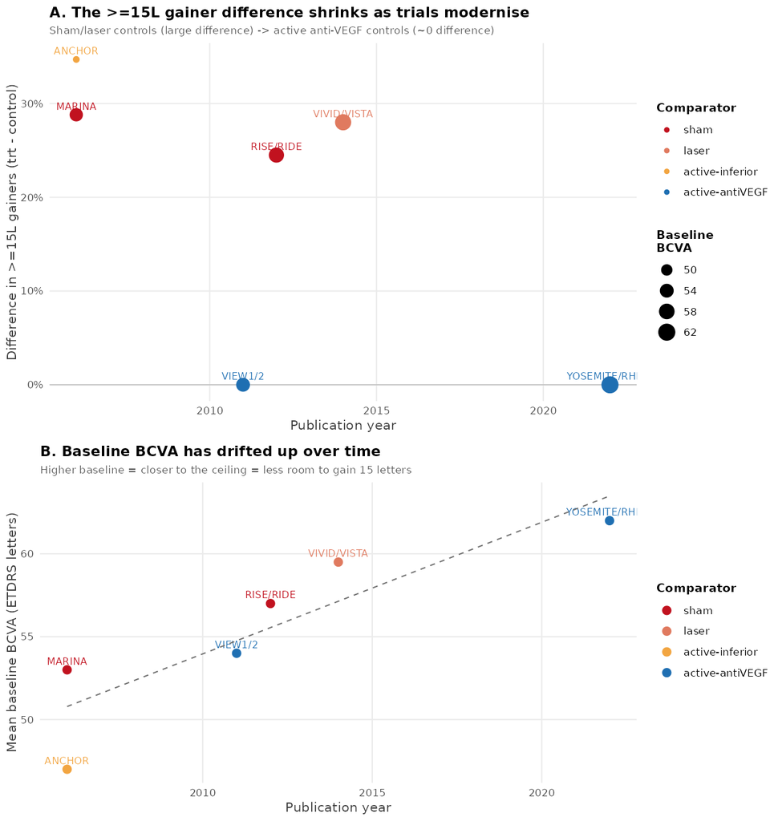

Published anti-VEGF trial landscape (FDA-label efficacy tables). A: the >=15L gainer difference (treatment - control) collapses from ~25-35 pp against sham/laser to ~0 against an active anti-VEGF comparator. B: mean baseline BCVA has drifted upward over the same period, moving trials closer to the letter ceiling. Point size in A encodes baseline BCVA.

Anti-VEGF pivotal-trial landscape. Gainer % and mean change are from FDA labels (Lucentis, Eylea) where available; baseline BCVA are canonical published values. As comparators strengthen (sham -> laser -> active anti-VEGF), the binary gainer difference collapses toward zero.

| Trial | Year | Indication | Comparator | Baseline BCVA | Mean Delta (L) | Gainers trt | Gainers ctrl | Gainer diff |
| --- | --- | --- | --- | --- | --- | --- | --- | --- |
| ANCHOR | 2006 | nAMD | verteporfin PDT | 47.0 | 20.8 | 40% | 6% | 35 pp |
| MARINA | 2006 | nAMD | sham | 53.0 | 17.6 | 34% | 5% | 29 pp |
| VIEW1/2 | 2011 | nAMD | ranibizumab | 54.0 | -0.3 | 31% | 31% | 0 pp |
| RISE/RIDE | 2012 | DME | sham | 57.0 | 9.2 | 40% | 15% | 24 pp |
| VIVID/VISTA | 2014 | DME | laser | 59.5 | 9.9 | 36% | 8% | 28 pp |
| YOSEMITE/RHINE | 2022 | DME | aflibercept | 62.0 | 0.7 | 30% | 30% | 0 pp |

**4 - Does the ceiling make the loss *worse than Normal*, and can we quantify it?** The intuition so far explains a shrinking *signal* (smaller $\Delta$, higher baseline). A separate question is whether the *shape* of the endpoint — left-skewed and hard-bounded, which we model with a logit-normal engine — inflates the dichotomization penalty **beyond** what the Normal ARE formula predicts *at the same mean and SD*. This is exactly the kind of question the fitted generator lets us answer, and the answer (below) is perhaps surprising.

### 8.2.2 Part 1 — Model assumptions and a baseline illustration

This part sets out **how the illustration is built** — the two modelling choices that everything downstream depends on — and shows the resulting picture in plain letters. Part 2 (Section 8.2.3) then reads the efficiency (ARE) consequence off it. We reuse the ceiling-aware generative engine selected in §7 (the LogitNormal cANCOVA: control mean and residual $\sigma$ as functions of baseline, plus the between-eye random effect). Everything here is computed **analytically** from that engine by Gauss-Hermite quadrature — no clinical data and no Monte-Carlo noise — so the numbers are exact.

There are exactly two assumptions to pin down: **(A)** how the *baseline distribution* moves as we sweep its mean, and **(B)** how a fixed *treatment effect* attenuates across baseline. We take them in turn.

#### 8.2.2.1 Assumption A — how the baseline distribution is shifted

Sliding the baseline distribution upward, holding the biology fixed, mechanically lowers the gainer rate because more eyes hit the ceiling. This is the “rising baseline” trend (3) made quantitative and is the axis the full simulation sweeps. The question is *how* to move it realistically.

The grid sweeps the baseline *mean* under a **shared eligibility window** ([24, 78] letters — the observed min/max of baseline BCVA across the trials, see Section 3). A naive location shift of a single fitted shape would be unrealistic: sliding the whole population down to reach a mean of 50 drains the upper tail entirely, leaving *no* eyes at 70–78L — yet historical low-mean trials (MARINA, ANCHOR, the DME laser arms) still enrolled some 70–78L eyes. What actually distinguished those trials was **broader inclusion**: a wider, more symmetric baseline distribution under the same upper cap, not the modern population shifted bodily downward. We therefore hold the window fixed and let the *spread and skew relax* at lower means — low-mean scenarios are broad and near-symmetric (SD ≈ 12 letters, matching the wider historical inclusion), high-mean scenarios stay near that spread but grow strongly left-skewed as mass piles against the ceiling (SD ≈ 10 at a mean of 65).

Concretely, each scenario is a **truncated skew-normal** — a skew-normal $\text{SN}(\xi,\omega,\alpha)$ restricted to the eligibility window [24, 78] — the same family used to fit the real per-study baselines in Section 3. The three parameters give exactly the three levers we need: location $\xi$, scale $\omega$, and shape $\alpha<0$ for the left-skew, while the truncation enforces the shared window. For each target mean we fix $\omega$ and $\alpha$ to the desired spread/skew and solve $\xi$ so the *realized* (post-truncation) mean hits the target. Figure 14 shows the five scenarios (means 50-70, matching the tables below) and Table 5 their moments.

**How these compare to the real trials.** The generated shapes are calibrated against the per-study baseline moments in Section 3 (see the min/max/SD summary; READ3 is excluded from this comparison as a low-baseline RVO outlier at mean ≈ 28). The **mean 50-65** scenarios reproduce the real landscape closely: their SDs (11.7, 11.9, 12.1, 10.3) sit inside the observed range — the broad nAMD trials at the top (HARBOR mean 54 / SD 12.7, LUCERNE 59 / 13.5, TENAYA 61 / 12.7) and the tight high-baseline DME trials at the bottom (RHINE 62 / 9.6, YOSEMITE 62 / 9.6). Only the **mean 70** scenario is a deliberate *extrapolation beyond the current trial landscape* — no enrolled study has a mean baseline above ≈ 62 — so the [24,78] eligibility window forces it to compress (SD ≈ 7) below any real cohort. That extra compression is not a claim about an existing trial; it is the illustration’s whole point: **it shows where the ceiling would bite hardest if the population kept rising**. Every scenario keeps an upper shoulder of 70-78L eyes; what changes with the mean is **how much of the mass sits near the ceiling** — at a mean of 70 letters roughly a third of eyes are already at/above 75L, so their capacity to gain 15 letters is structurally limited before any drug acts.

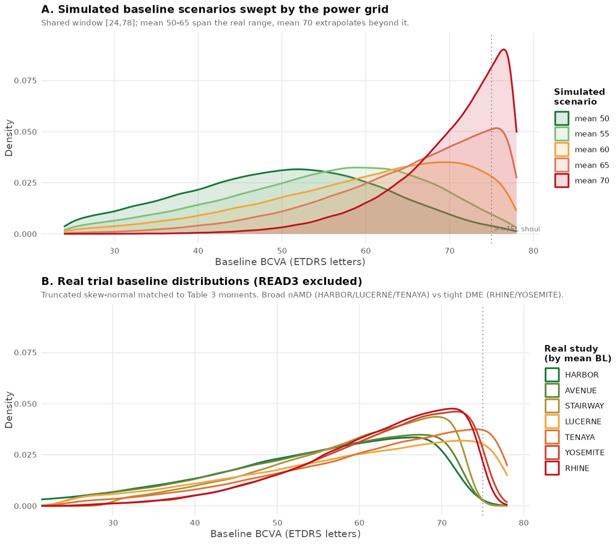

Figure 14: Five candidate baseline BCVA distributions (means 50-70) swept by the power grid, under a shared eligibility window [24,78] (the observed min/max). The mean 50-65 scenarios match the real trials (SD ~10-12): broad and near-symmetric at low means (as in the wider historical inclusion), deepening in left-skew toward the high-baseline DME shape (RHINE/YOSEMITE). The mean 70 scenario extrapolates beyond the highest real trial mean (~62), so the shared window compresses its SD further than any enrolled cohort. Every scenario retains an upper shoulder of 70-78L eyes.

Table 5: Moments of the five baseline scenarios. The eligibility window [24,78] (the observed min/max) is shared; the mean is set by relaxing the spread and skew (broad and near-symmetric at low means, deepening left-skew at high means). The mean 50-65 scenarios match the observed per-study moments in Section 3 (SD ~10-12 letters, spanning RHINE/YOSEMITE at ~9.6 through HARBOR/LUCERNE/TENAYA at ~12.7); only the mean 70 scenario extrapolates beyond the highest real trial mean (~62), so the shared window compresses its SD (~7) below any enrolled cohort. Every scenario keeps a share of eyes at/above 70-75L, but that share, the left-skew and the leptokurtosis all grow as the mean rises toward the ceiling.

| scenario | Target mean | Realized mean | SD | Median | Skewness | Excess kurtosis | % at/above 70L | % at/above 75L |
| --- | --- | --- | --- | --- | --- | --- | --- | --- |
| mean 50 | 50 | 50 | 11.7 | 50 | -0.07 | -0.64 | 4.5% | 1.1% |
| mean 55 | 55 | 55 | 11.9 | 56 | -0.40 | -0.50 | 10.6% | 2.6% |
| mean 60 | 60 | 60 | 12.1 | 62 | -0.70 | -0.19 | 25.5% | 8.7% |
| mean 65 | 65 | 65 | 10.3 | 67 | -1.03 | 0.74 | 41.7% | 18.6% |
| mean 70 | 70 | 70 | 7.0 | 72 | -1.37 | 2.19 | 62.5% | 31.7% |

#### 8.2.2.2 Assumption B — how a true +3L effect attenuates across baseline

To compute the operating characteristics of a trial we need two inputs from the new drug: its **expected effect** and the **outcome SD**, both as functions of baseline (they are non-linear in BL, as §8.2.1 established). For the effect we assume a **+3 letters** mean improvement for a plausible new treatment. The modelling question is not the number but the **scale it lives on**:

- **Linear (naive)** — a pure letter translation: every eye’s outcome is its control outcome plus 3 letters, $Y_{\text{trt}}=Y_{\text{ctrl}}+3$, at every baseline. Easy to specify, but unrealistic: it is **ceiling-blind**, so an eye already at 78L is pushed to 81L, past the 100-letter cap’s reach. A translation does not rescale the distribution, so the outcome **SD is unchanged** from control and the effect is a flat 3 L in letters everywhere.
- **Logit (realistic)** — the drug is a fixed shift on the *logit* scale the engine is built on (§7), anchored so its **population-average letter effect equals 3 L**. We have already seen (§7-8.2.1) this scale fits the data better. Because the same logit step buys fewer letters where there is less headroom, the realistic effect is **larger than 3 L at low baseline and smaller at high baseline** — ≈ **3.5 L at BL50, drooping to ≈ 2.6 L at BL70**, crossing 3 L near the population mean.

Both arms carry the *same* drug; they differ only in the assumed scale. Below is how they differ in letters, in the outcome distribution, and in the $\ge 15$L gainer rate. (One nomenclature guard-rail: the **endpoint** is the $\ge 15$-letter gainer throughout; the **+3 L** is the injected *mean* effect, not a gainer threshold.)

**Why the logit shift attenuates — where the $q(1-q)$ factor comes from.** The engine models each eye on the logit scale,
$$\operatorname{logit}(\text{BCVA}/100) \;=\; \eta + \varepsilon,
\qquad \varepsilon\sim N(0,s^2),$$
where $\eta$ is the linear predictor (study-arm + M9/12 effect + baseline spline, §7) and $\varepsilon$ is the between-eye random term ($s\approx 0.54$). So the outcome for an eye is $\text{BCVA} = 100\cdot\operatorname{logit}^{-1}(\eta+\varepsilon)$, and the **mean** BCVA is $100\cdot\mathbb{E}_\varepsilon[\operatorname{logit}^{-1}(\eta+\varepsilon)]$ — an expectation the engine evaluates exactly by Gauss-Hermite quadrature.

For *intuition only*, set $\varepsilon=0$ and define
$$q \;\equiv\; \operatorname{logit}^{-1}(\eta) \;=\; \frac{\text{BCVA of the median eye}}{100},$$
the mean BCVA as a fraction of the cap. Note $q$ is **not a probability and not the gainer rate** (an eye at 62 L has $q=0.62$; we avoid the letter $p$, which is the $\ge 15$L gainer proportion in Part 2). A drug that adds a fixed logit increment $\delta$ moves $\eta\to\eta+\delta$, and for this median eye
$$\Delta\text{BCVA} \;=\; 100\big[\operatorname{logit}^{-1}(\eta+\delta)-\operatorname{logit}^{-1}(\eta)\big]
\;\approx\; \underbrace{100\,q(1-q)}_{J}\;\delta .$$
$J=100\,q(1-q)$ is the slope (Jacobian) of the letters$\leftrightarrow$logit map — **maximal at $q=0.5$ (50 L)** and shrinking toward the ceiling (at $q=0.78$ it is $\approx17$ vs $25$ at mid-range), so one fixed logit dose buys ~3.5 L near 50 L but only ~2.6 L near 70 L: the same $\delta$, taxed by the ceiling.